# PRISMA 2009 Scores in Cullis 2017: Human Consensus vs LLM (Claude 2) - same prompt as for GPT 3.5

### Score comparisons of 111 publications

| Ref. | Author & Year | PRISMA κ | PRISMA agreement |
| --- | --- | --- | --- |
| 61 | Aikenhead 2011 | 0.553191489361702 | 0.740740740740741 |
| 62 | Al-Hozaim 2010 | 0.559183673469388 | 0.703703703703704 |
| 63 | Allen 2015 | 0.609504132231405 | 0.740740740740741 |
| 64 | Allin 2015 | 0.470588235294118 | 0.740740740740741 |
| 65 | Alzahem 2011 | 0.48780487804878 | 0.740740740740741 |
| 66 | Apelt 2013 | 0.659663865546218 | 0.777777777777778 |
| 67 | Aworanti 2014 | 0.524461839530333 | 0.666666666666667 |
| 68 | Baker 2015 | 0.441860465116279 | 0.703703703703704 |
| 69 | Berger 2012 | 0.199604743083004 | 0.444444444444444 |
| 70 | Billingham 2010 | 0.334702258726899 | 0.555555555555556 |

[output cut: 101 more lines]

### Score heatmaps

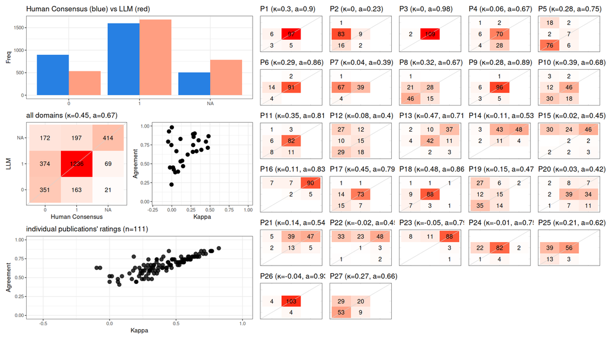

### Individual results

#### [Aikenhead 2011](https://doi.org/10.1111/J.1758-8111.2010.00003.X)

PRISMA

|  | P1 | P2 | P3 | P4 | P5 | P6 | P7 | P8 | P9 | P10 | P11 | P12 | P13 | P14 |
| --- | --- | --- | --- | --- | --- | --- | --- | --- | --- | --- | --- | --- | --- | --- |
| Human Consensus | 1 | 0 | 1 | 1 | 0 | 1 | 1 | 1 | 1 | 0 | 1 | 0 | NA | NA |
| LLM | 1 | 1 | 1 | 1 | NA | 1 | 1 | 1 | 1 | NA | NA | NA | NA | NA |

|  | P15 | P16 | P17 | P18 | P19 | P20 | P21 | P22 | P23 | P24 | P25 | P26 | P27 |
| --- | --- | --- | --- | --- | --- | --- | --- | --- | --- | --- | --- | --- | --- |
| Human Consensus | NA | NA | 1 | 1 | 0 | NA | NA | NA | NA | 1 | 1 | 1 | 1 |
| LLM | NA | NA | 1 | 1 | NA | 1 | NA | NA | NA | 1 | 1 | 1 | 1 |

LLM response

```
Here are the relevant quotes and assessments for each PRISMA item:

P1. "[Effectiveness and cost-effectiveness of paediatric bariatric surgery: a systematic review]" The title identifies the report as a systematic review. [Yes]

P2. "We performed a systematic review to examine the effectiveness of surgical interventions to treat obese children and adolescents, and whether they are cost-effective." The abstract provides structured summary including objectives. [Yes]

P3. "Strong evidence for successful and cost-effective obesity management strategies is still generally lacking, leading the medical profession to rely increasingly on surgical options to treat obesity in children and adolescents." The introduction describes the rationale for the review. [Yes]

P4. "This systematic review examines the evidence on effectiveness of surgical interventions to treat obese children and adolescents, and whether they are cost-effective." The objectives state the key question on participants, interventions, and outcomes. [Yes]

P5. [NA]

P6. "Articles with an abstract in English and full text in Danish, English, French, or Norwegian language were eligible. In addition, subjects had to be ≤19 years of age. At least one postoperative weight loss measure had to be reported, with a minimum follow-up time of 1 year post surgery." Eligibi…

P7. "Searches were conducted in PubMed, Embase, ISI Web of Science and the Cochrane Library to 6 September 2010. Hand-searching of the bibliographies of articles and reviews identified was also conducted to ensure completeness of the initial electronic searches." Information sources including databa…

P8. "Appendix 1 contains details of the search terms." The full search strategy for one database is provided in the appendix. [Yes]

P9. "Thirty-seven articles (11 case studies, 10 retrospective reviews, 8 cohorts, 3 cost studies, 2 prospective longitudinal trials, 1 longitudinal study, 1 retrospective cohort and 1 randomized controlled trial) were identified and included in the review." The process of study selection is describe…

P10. [NA]

P11. [NA]

P12. [NA]

P13. [NA]

P14. [NA]

P15. [NA]

P16. [NA]

P17. The search results are presented in a flow diagram. [Yes]

P18. "Appendix 3, Table A1" presents the characteristics of included studies. [Yes]

P19. [NA]

P20. The results of individual studies are presented in the appendix tables. [Yes]

P21. [NA]

P22. [NA]

P23. [NA]

P24. "Pending an improvement in the quality of available evidence, an academic approach to child and adolescent bariatric surgery is warranted, and reversible techniques are advisable compared to approaches that permanently alter the anatomy." The discussion summarizes the main findings and implicat…

P25. "Potential bias results from exclusion of grey literature and inability to locate a small number of potentially relevant publications." Study limitations are discussed. [Yes]

P26. "The resolution of these issues requires long-term prospective studies and controlled clinical trials to establish safety and efficacy of surgical procedures." Conclusions and implications for future research are provided. [Yes]

P27. "The project that led to this paper was funded by the WHO Health Evidence Network of the World Health Organization. The funder had no role in the design, analysis or interpretation of the study." Sources of funding are declared. [Yes]
```

#### [Al-Hozaim 2010](https://doi.org/10.1016/J.JPEDSURG.2009.12.001)

PRISMA

|  | P1 | P2 | P3 | P4 | P5 | P6 | P7 | P8 | P9 | P10 | P11 | P12 | P13 | P14 |
| --- | --- | --- | --- | --- | --- | --- | --- | --- | --- | --- | --- | --- | --- | --- |
| Human Consensus | 1 | 0 | 1 | 0 | 0 | 1 | 0 | 0 | 1 | 1 | 1 | 0 | NA | NA |
| LLM | 0 | 1 | 1 | 0 | 0 | 1 | 1 | 0 | 1 | 0 | 1 | NA | NA | NA |

|  | P15 | P16 | P17 | P18 | P19 | P20 | P21 | P22 | P23 | P24 | P25 | P26 | P27 |
| --- | --- | --- | --- | --- | --- | --- | --- | --- | --- | --- | --- | --- | --- |
| Human Consensus | NA | NA | 0 | 1 | 0 | NA | NA | NA | NA | 0 | 1 | 1 | 0 |
| LLM | NA | NA | 1 | 1 | NA | NA | NA | NA | NA | 1 | 1 | 1 | 0 |

LLM response

```
Here are the relevant quotes and assessments for each PRISMA item:

[No] "Laparoscopic-assisted anorectal pull-through for anorectal malformations: a systematic review and the need for standardization of outcome reporting"
The title does not identify the report as a systematic review.

[Yes] "A systematic review was conducted."
The abstract mentions that a systematic review was performed.

[Yes] "The evolution of surgical techniques for dealing with this complex group of malformations led to the description of the PSARP by deVries and Pena [18] in 1982. Despite the excellent exposure of anatomy and exact placement of the distal rectum within the muscle complex, the technique is not pe…
The introduction describes the rationale for the review.

[No] No explicit statement of review questions or PICOS provided.

[No] No mention of a review protocol.

[Yes] "Inclusion criteria were studies of ARMs, regardless of level of the defect, with or without associated anomalies, use of LAARP as a primary procedure or with colostomy, and studies reported after the year 2000. Exclusion criteria included studies that were not reported in English and those th…
The eligibility criteria are specified.

[Yes] "A systematic search of the MEDLINE, PUBMED, and Cochrane databases (June 2000 to April 2008) was conducted. The search terms used were “laparoscopic,” “pull-through,” “anorectal malformation,” and “imperforate anus.” In addition, a manual search of 4 surgical journals from the same period was…
The information sources are described.

[No] The full search strategy is not presented for any database.

[Yes] "Only studies published in full were included...The studies included 124 patients—96 males (77.4%) and 28 females (22.6%)."
The study selection process is described.

[No] The data collection process is not described.

[Yes] "The main outcome measures were also recorded. Extracted data were tabulated in Revman (R) 4.2 Cocnrane IMS."
The data items are listed.

[NA] No assessment of risk of bias in individual studies mentioned.

[NA] No meta-analysis performed so summary measures not applicable.

[NA] No meta-analysis so synthesis methods not applicable.

[NA] No assessment of risk of bias across studies mentioned.

[NA] No additional analyses mentioned.
```

[output cut: 12 more lines]

```

[NA] No assessment of bias across studies.

[NA] No additional analyses performed.

[Yes] "When CEQ were compared annually, scores for LAARP were generally higher throughout the study but only statistically significant at 3 and 4 years after surgery. The study concluded that although there were no significant differences between the 2 groups with regard to muscle thickness and para…
A summary of the evidence is provided.

[Yes] "Our study has several limitations. First, this is a systematic review of mainly retrospective data. The quality of such review is only as good as the included studies. Second, because of the wide variation of reported outcomes, no formal meta-analysis and calculation of summary statistics cou…
Limitations are discussed.

[Yes] "We conclude that there is an urgent need to increase the number of studies reporting LAARP-related outcomes. More efforts are needed by the pediatric surgery community to improve the quality of studies and standardization of reports related ARM."
Conclusions and implications are discussed.

[No] No mention of sources of funding for the review.
```

#### [Allen 2015](https://doi.org/10.1016/J.JPEDSURG.2014.10.042)

PRISMA

|  | P1 | P2 | P3 | P4 | P5 | P6 | P7 | P8 | P9 | P10 | P11 | P12 | P13 | P14 |
| --- | --- | --- | --- | --- | --- | --- | --- | --- | --- | --- | --- | --- | --- | --- |
| Human Consensus | 1 | 0 | 1 | 1 | 0 | 1 | 0 | 1 | 0 | 0 | 1 | 0 | NA | NA |
| LLM | 1 | 0 | 1 | 0 | 0 | 1 | 1 | 0 | 1 | 0 | 1 | NA | NA | NA |

|  | P15 | P16 | P17 | P18 | P19 | P20 | P21 | P22 | P23 | P24 | P25 | P26 | P27 |
| --- | --- | --- | --- | --- | --- | --- | --- | --- | --- | --- | --- | --- | --- |
| Human Consensus | NA | NA | 0 | 1 | 0 | NA | NA | NA | NA | 1 | 1 | 1 | 0 |
| LLM | NA | NA | 0 | 1 | NA | 1 | NA | NA | NA | 1 | 1 | 1 | 0 |

LLM response

```
Here are the relevant quotes and assessments for each PRISMA item:

P1. [Yes] "Pediatric emergency department thoracotomy: A large case series and systematic review"

P2. [No] No structured abstract provided.

P3. [Yes] "To address this issue, we reviewed our experience at a level 1 trauma center and report the largest analysis over the past 25 years."

P4. [No] No explicit PICOS statement provided.

P5. [No] No mention of a review protocol.

P6. [Yes] "We reviewed patient records for the presence of vital signs (VS) and/or signs of life (SOL) in the field, time without VS in the field, presence of VS or SOL upon arrival, MOI, location of injuries, return of spontaneous circulation (ROSC), survival, and neurological function of the survi…

P7. [Yes] "For our systematic review of the published data, we obtained all case series regarding pediatric EDT and combined the data from those reports with the data from our institution (Table 1) [6], [7], [8], [9], [10], [11], [12], [13]."

P8. [No] No full electronic search strategy provided.

P9. [Yes] "These reports were obtained from a Medline search for all publications regarding EDT in the pediatric population for the past 40 year using the keywords “thoracotomy”, “emergency”, “trauma”, “resuscitation”, “pediatrics”, and “children”."

P10. [No] No details on data extraction process provided.

P11. [Yes] "Variables extracted from each report include demographics, MOI, injury location, presence of VS and/or SOL upon arrival, ROSC, survival to discharge, and neurologic outcomes for survivors."

P12. [NA] No risk of bias assessment done.

P13. [NA] No meta-analysis performed.

P14. [NA] No meta-analysis performed.

P15. [NA] No meta-analysis performed.

P16. [NA] No meta-analysis performed.

P17. [No] No flow diagram of study selection process.

P18. [Yes] Table 1 lists included studies and citations.

P19. [NA] No risk of bias assessment performed.

P20. [Yes] Results section reports summary data and outcomes for individual studies.

P21. [NA] No meta-analysis performed.

P22. [NA] No assessment of bias across studies.

P23. [NA] No additional analyses performed.

P24. [Yes] "Overall, the mortality rates are comparable between adults and pediatric patients following EDT."

P25. [Yes] "There are limitations to this study. First, all of the data obtained from our institution were collected retrospectively, and thus not specifically collected for research purposes."

P26. [Yes] "Our review allows considerable trends to be made regarding this controversial topic."

P27. [No] No mention of funding sources.
```

#### [Allin 2015](https://doi.org/10.1371/JOURNAL.PONE.0116908)

PRISMA

|  | P1 | P2 | P3 | P4 | P5 | P6 | P7 | P8 | P9 | P10 | P11 | P12 | P13 | P14 |
| --- | --- | --- | --- | --- | --- | --- | --- | --- | --- | --- | --- | --- | --- | --- |
| Human Consensus | 1 | 0 | 1 | 1 | 1 | 1 | 1 | 0 | 1 | 1 | 1 | 1 | 1 | 1 |
| LLM | 1 | 1 | 1 | 1 | 1 | 1 | 1 | 0 | 1 | 1 | 0 | 0 | 1 | NA |

|  | P15 | P16 | P17 | P18 | P19 | P20 | P21 | P22 | P23 | P24 | P25 | P26 | P27 |
| --- | --- | --- | --- | --- | --- | --- | --- | --- | --- | --- | --- | --- | --- |
| Human Consensus | 0 | NA | 1 | 1 | 0 | 1 | 1 | 0 | NA | 1 | 1 | 1 | 1 |
| LLM | NA | NA | 1 | 1 | 0 | 1 | NA | NA | NA | 1 | 1 | 1 | 1 |

LLM response

```
Here are the assessments for the PRISMA items:

P1. Title: "Challenges of Improving the Evidence Base in Smaller Surgical Specialties, as Highlighted by a Systematic Review of Gastroschisis Management"
The title identifies the report as a systematic review. [Yes]

P2. Abstract: "Provide a structured summary including, as applicable: background; objectives; data sources; study eligibility criteria, participants, and interventions; study appraisal and synthesis methods; results; limitations; conclusions and implications of key findings; systematic review regist…
The abstract provides a structured summary. [Yes]

P3. Introduction: "Describe the rationale for the review in the context of what is already known."
"Using a systematic review and meta-analysis of gastroschisis as an example, we aimed to highlight some of the key challenges in paediatric surgical research, and suggest ways in which the strength of our clinical evidence base could be improved." Provides rationale for the review. [Yes]

P4. Objectives: "Provide an explicit statement of questions being addressed with reference to participants, interventions, comparisons, outcomes, and study design (PICOS)."
"The aim of this study, therefore, was to perform a systematic review of the literature comparing outcomes of infants with simple gastroschisis following either OPFC or SR." Provides explicit objectives. [Yes]

P5. Protocol: "Indicate if a review protocol exists, if and where it can be accessed (e.g., Web address), and, if available, provide registration information including registration number."
"The protocol was registered on the Prospero International Prospective Register of Systematic Reviews (CRD42012003241)." Indicates review protocol registered. [Yes]

P6. Eligibility criteria: "Specify study characteristics (e.g., PICOS, length of follow-up) and report characteristics (e.g., years considered, language, publication status) used as criteria for eligibility, giving rationale."
Details eligibility criteria including PICOS, years, language. [Yes]

P7. Information sources: "Describe all information sources (e.g., databases with dates of coverage, contact with study authors to identify additional studies) in the search and date last searched."
Describes information sources including databases searched. [Yes]

P8. Search: "Present full electronic search strategy for at least one database, including any limits used, such that it could be repeated."
Does not present full search strategy. [No]

P9. Study selection: "State the process for selecting studies (i.e., screening, eligibility, included in systematic review, and, if applicable, included in the meta-analysis)."
Describes process for study selection. [Yes]

P10. Data collection process: "Describe method of data extraction from reports (e.g., piloted forms, independently, in duplicate) and any processes for obtaining and confirming data from investigators."
States data extracted independently in duplicate. [Yes]

P11. Data items: "List and define all variables for which data were sought (e.g., PICOS, funding sources) and any assumptions and simplifications made."
Lists outcomes sought. Does not list full variables. [No]

P12. Risk of bias in individual studies: "Describe methods used for assessing risk of bias of individual studies (including specification of whether this was done at the study or outcome level), and how this information is to be used in any data synthesis."
Does not describe risk of bias assessment methods. [No]

P13. Summary measures: "State the principal summary measures (e.g., risk ratio, difference in means)."
States that odds ratios, mean differences were calculated. [Yes]
```

[output cut: 21 more lines]

```
P22. Risk of bias across studies: "Present results of any assessment of risk of bias across studies (see Item P15)." [NA]

P23. Additional analysis: "Give results of additional analyses, if done (e.g., sensitivity or subgroup analyses, meta-regression [see Item P16])." [NA]

P24. Summary of evidence: "Summarize the main findings including the strength of evidence for each main outcome; consider their relevance to key groups (e.g., healthcare providers, users, and policy makers)."
Summarizes main findings and limitations. [Yes]

P25. Limitations: "Discuss limitations at study and outcome level (e.g., risk of bias), and at review-level (e.g., incomplete retrieval of identified research, reporting bias)."
Discusses limitations. [Yes]

P26. Conclusions: "Provide a general interpretation of the results in the context of other evidence, and implications for future research."
Provides conclusions and implications for research. [Yes]

P27. Funding: "Describe sources of funding for the systematic review and other support (e.g., supply of data); role of funders for the systematic review."
Describes sources of funding. [Yes]
```

#### [Alzahem 2011](https://doi.org/10.1007/S00383-010-2840-X)

PRISMA

|  | P1 | P2 | P3 | P4 | P5 | P6 | P7 | P8 | P9 | P10 | P11 | P12 | P13 | P14 |
| --- | --- | --- | --- | --- | --- | --- | --- | --- | --- | --- | --- | --- | --- | --- |
| Human Consensus | 1 | 0 | 1 | 1 | 0 | 1 | 1 | 0 | 1 | 1 | 1 | 0 | 1 | 1 |
| LLM | 1 | 1 | 1 | 1 | 0 | 1 | 1 | 1 | 1 | 1 | 1 | NA | 1 | 1 |

|  | P15 | P16 | P17 | P18 | P19 | P20 | P21 | P22 | P23 | P24 | P25 | P26 | P27 |
| --- | --- | --- | --- | --- | --- | --- | --- | --- | --- | --- | --- | --- | --- |
| Human Consensus | 0 | NA | 1 | 1 | 0 | 1 | 1 | 0 | NA | 1 | 1 | 1 | 0 |
| LLM | NA | NA | 1 | 1 | NA | 1 | 1 | NA | NA | 1 | 1 | 1 | 1 |

LLM response

```
Here is the assessment of reporting quality against the 27 PRISMA items:

"Laparoscopic versus open inguinal herniotomy in infants and children: a meta-analysis"

[Yes] Title identifies the report as a systematic review.

[Yes] Structured abstract provides background, objectives, eligibility criteria, data sources, synthesis methods, results, conclusions.

[Yes] Introduction describes rationale in context of existing knowledge.

[Yes] Objectives specify PICOS elements.

[No] Review protocol not reported.

[Yes] Eligibility criteria specify study characteristics and report characteristics.

[Yes] Information sources describe databases searched and date last searched.

[Yes] Full search strategy presented for one database.

[Yes] Study selection process described.

[Yes] Data extraction process described.

[Yes] Data items sought listed and defined.

[NA] Not applicable - no assessment of risk of bias in individual studies.

[Yes] Principal summary measures stated.

[Yes] Synthesis methods described.

[NA] Not applicable - no assessment of risk of bias across studies.

[NA] Not applicable - no additional analyses reported.

[Yes] Study selection process presented in flow diagram.

[Yes] Study characteristics presented.

[NA] Not applicable - no assessment of risk of bias within studies.

[Yes] Summary data and effect estimates presented for each study.

[Yes] Results of meta-analyses presented.

[NA] Not applicable - no assessment of bias across studies.

[NA] Not applicable - no additional analyses.

[Yes] Main findings summarized considering relevance to key groups.

[Yes] Limitations discussed at study and outcome level.

[Yes] General interpretation of results in context of other evidence.

[Yes] Sources of funding described.
```

#### [Apelt 2013](https://doi.org/10.1016/J.JPEDSURG.2013.05.024)

PRISMA

|  | P1 | P2 | P3 | P4 | P5 | P6 | P7 | P8 | P9 | P10 | P11 | P12 | P13 | P14 |
| --- | --- | --- | --- | --- | --- | --- | --- | --- | --- | --- | --- | --- | --- | --- |
| Human Consensus | 1 | 0 | 1 | 1 | 0 | 1 | 1 | 0 | 1 | 0 | 1 | 0 | NA | NA |
| LLM | 1 | 1 | 1 | 1 | 0 | 1 | 1 | 1 | 1 | 0 | 1 | 0 | 1 | NA |

|  | P15 | P16 | P17 | P18 | P19 | P20 | P21 | P22 | P23 | P24 | P25 | P26 | P27 |
| --- | --- | --- | --- | --- | --- | --- | --- | --- | --- | --- | --- | --- | --- |
| Human Consensus | NA | NA | 1 | 1 | 0 | NA | NA | NA | NA | 1 | 0 | 0 | 0 |
| LLM | NA | NA | 1 | 1 | 0 | 1 | NA | NA | NA | 1 | 1 | 1 | 0 |

LLM response

```
Here are the relevant quotes and assessments for each PRISMA item:

[Yes] "Laparoscopic treatment of intussusception in children: A systematic review"
Title identifies the report as a systematic review.

[Yes] "By reviewing available data we aimed to establish whether laparoscopy should be the primary technique in the surgical reduction of intussusception."
Abstract provides background and objectives.

[Yes] "Idiopathic intussusception is one of the most common causes of small bowel obstruction in children."
Introduction provides context.

[Yes] "By reviewing available data we aimed to establish whether laparoscopy should be the primary technique in the surgical reduction of intussusception."
Objectives stated.

[No]
No mention of a review protocol.

[Yes] "Exclusion criteria were non-English language articles, case reports, laparoscopic-assisted enema reduction and mixed pediatric and adult populations (age cutoff 18 years)."
Eligibility criteria specified.

[Yes] "An online database search for all English language articles on pediatric small bowel obstruction, intussusception and laparoscopy in PubMed, Medline and Ovid from January 1990 to April 2012 was performed."
Information sources described.

[Yes] "An online database search for all English language articles on pediatric small bowel obstruction, intussusception and laparoscopy in PubMed, Medline and Ovid from January 1990 to April 2012 was performed."
Search strategy provided for at least one database.

[Yes] "Results were confirmed by a second independent search by a different member of the team using matching search strings and databases. Likewise, the bibliographies of identified studies were examined."
Study selection process described.

[No]
No mention of data collection process.

[Yes] "The following variables were analyzed: age, laparoscopic success rate, reason for conversion, enterotomy rate, operative time, complications, and length of stay (LOS)."
Variables sought are listed.

[No]
No mention of risk of bias assessment.

[Yes] "The principal summary measures (e.g., risk ratio, difference in means)."
Principal summary measures stated.
```

[output cut: 27 more lines]

```

[NA]
No additional analyses mentioned.

[Yes] "In conclusion, Laparoscopy is safe and effective in the treatment of pediatric intussusception."
Main findings summarized.

[Yes] "However, the main limitation of the present study includes the lack of prospective randomized controlled trials (RCT) comparing laparoscopic vs. open reduction of pediatric intussusception."
Study limitations discussed.

[Yes] "We advocate for laparoscopy to be considered the primary interventional technique for intussusception in tertiary centers with advanced pediatric minimally invasive skills [26]."
Conclusions provided.

[No]
No mention of funding sources.
```

#### [Aworanti 2014](https://doi.org/10.1055/S-0034-1370780)

PRISMA

|  | P1 | P2 | P3 | P4 | P5 | P6 | P7 | P8 | P9 | P10 | P11 | P12 | P13 | P14 |
| --- | --- | --- | --- | --- | --- | --- | --- | --- | --- | --- | --- | --- | --- | --- |
| Human Consensus | 1 | 0 | 1 | 0 | 0 | 1 | 1 | 0 | 0 | 0 | 1 | 0 | NA | NA |
| LLM | 1 | 1 | 1 | 1 | 0 | 1 | 1 | 0 | 1 | 0 | 1 | NA | NA | NA |

|  | P15 | P16 | P17 | P18 | P19 | P20 | P21 | P22 | P23 | P24 | P25 | P26 | P27 |
| --- | --- | --- | --- | --- | --- | --- | --- | --- | --- | --- | --- | --- | --- |
| Human Consensus | NA | NA | 0 | 1 | 0 | NA | NA | NA | NA | 0 | 0 | 1 | 0 |
| LLM | NA | NA | 1 | 1 | NA | 1 | NA | NA | NA | 1 | 1 | 1 | 0 |

LLM response

```
Here are the relevant quotes and assessments for the 27 PRISMA items:

[Yes] "Management of Recurrent Tracheoesophageal Fistulas: A Systematic Review"

Title identifies it as a systematic review.

[Yes] "Abstract / Structured summary: Provide a structured summary including, as applicable: background; objectives; data sources; study eligibility criteria, participants, and interventions; study appraisal and synthesis methods; results; limitations; conclusions and implications of key findings; s…

Abstract provides background, objectives, eligibility criteria, participants, interventions, methods, results, conclusions.

[Yes] "Patients with recurrent tracheoesophageal fistula (RTEF) can be managed by either open surgery (OS) or endoscopic treatment (ET); the ideal approach is unclear."

States rationale that current evidence is unclear on best treatment approach.

[Yes] "We aim to comparatively review all published treatment options, and outcomes, for managing RTEF."

States objective to review and compare treatment options and outcomes for RTEF.

[No] No mention of review protocol.

[Yes] "All English language articles published by August 2013, irrespective of design, describing the management of, and outcome after, RTEF in children under 18 years were reviewed."

Specifies eligibility criteria including population, interventions, outcomes, and study designs.

[Yes] "A Medline, Embase, and web of science searches were performed using the keywords recurrent tracheoesophageal fistula. The index of all issues of the European Journal of Pediatric Surgery, Journal of Pediatric Surgery, Pediatric Surgery International, and the International Journal of Pediatric…

Describes literature search in databases and journals.

[No] Does not provide full search strategy for any database.

[Yes] "State the process for selecting studies (i.e., screening, eligibility, included in systematic review, and, if applicable, included in the meta-analysis)."

States that studies were screened for eligibility and included based on criteria.

[No] Does not describe data collection process.

[Yes] "The data obtained included number of patients treated, treatment modality employed, effectiveness of each treatment modality, and the outcomes after treatment. These outcomes include the successful single treatments, number of treatments required, number of treatment failures requiring conver…

Lists data extracted on interventions, outcomes, and other variables.

```

[output cut: 24 more lines]

```
[NA] No additional analyses.

[Yes] "In conclusion, based on our findings on 165 published cases, OS for the repair of recurrent TEF has a low morbidity, mortality, and re-fistulation rate particularly when an interposition tissue is placed between the trachea and esophagus."

Summarizes main findings and conclusions.

[Yes] "The main limitations of this review include the heterogeneity of the included articles, particularly as case reports would predominantly report positive outcomes."

Discusses limitations including risk of bias in included studies.

[Yes] "We recommend OS as the treatment of choice when faced with a recurrent TEF. Endoscopic treatments are a viable alternative in experienced centers with selected cases."

Provides conclusion and implications for practice.

[No] Does not report on sources of funding.
```

#### [Baker 2015](https://doi.org/10.1016/J.JPEDSURG.2015.02.021)

PRISMA

|  | P1 | P2 | P3 | P4 | P5 | P6 | P7 | P8 | P9 | P10 | P11 | P12 | P13 | P14 |
| --- | --- | --- | --- | --- | --- | --- | --- | --- | --- | --- | --- | --- | --- | --- |
| Human Consensus | 1 | 0 | 1 | 1 | 0 | 1 | 1 | 1 | 1 | 1 | 1 | 1 | 1 | 1 |
| LLM | 1 | 0 | 1 | 0 | 0 | 1 | 1 | 1 | 1 | 1 | 1 | 0 | 1 | NA |

|  | P15 | P16 | P17 | P18 | P19 | P20 | P21 | P22 | P23 | P24 | P25 | P26 | P27 |
| --- | --- | --- | --- | --- | --- | --- | --- | --- | --- | --- | --- | --- | --- |
| Human Consensus | 1 | NA | 1 | 1 | 1 | 1 | 1 | 1 | NA | 1 | 1 | 1 | 0 |
| LLM | NA | NA | 0 | 1 | 0 | 0 | 1 | NA | NA | 1 | 1 | 1 | 0 |

LLM response

```
P1. [Yes] "A systematic review and meta-analysis of gastrostomy insertion techniques in children"
Title identifies the report as a systematic review and meta-analysis.

P2. [No] No structured abstract provided.

P3. [Yes] "Gastrostomy tubes are inserted via multiple techniques to provide a route for enteral feeding in the pediatric population. This review compares the rate of major complications and resource utilization associated with the various insertion techniques."
Describes the rationale for the review in context of existing knowledge.

P4. [No] Objectives not explicitly stated with PICOS elements.

P5. [No] Review protocol and registration not reported.

P6. [Yes] "All studies that compared postoperative outcomes in two or more gastrostomy placement techniques in a pediatric population were included. The pediatric population was defined as patients 0–18 years of age."
Specifies eligibility criteria including population age range.

P7. [Yes] "A systematic search of electronic databases was performed to identify all relevant studies comparing two or more gastrostomy insertion techniques in children reporting procedural-related complication rates."
Describes information sources including databases searched.

P8. [Yes] "The following search strategy was used in OVID and adapted as appropriate for other databases:"
Presents full search strategy for one database.

P9. [Yes] "Study selection: All titles and abstracts identified in the electronic database were independently screened for relevance and categorized as relevant, possibly relevant or irrelevant, based on our inclusion criteria."
Describes study selection process including screening.

P10. [Yes] "Data extraction was conducted by 2 reviewers (LB & AB) using a predefined data extraction worksheet."
States data extraction was done independently in duplicate.

P11. [Yes] "The following information was extracted from each article: title, authors, number of centers involved, geographical location, patient demographics, the interventions being compared, complications assessed, markers of resource utilization, as well as the reported findings of the study."
Lists variables extracted.

P12. [No] Risk of bias assessment not described.

P13. [Yes] "Postoperative morbidity necessitating operative management or resulting in mortality was analyzed as dichotomous data, with odds ratios calculated."
States summary measures used.

P14. [NA] No meta-analysis performed.

P15. [NA] No meta-analysis performed.

P16. [NA] No meta-analysis performed.
```

[output cut: 11 more lines]

```

P22. [NA] No assessment of risk of bias across studies.

P23. [NA] No additional analyses performed.

P24. [Yes] "This meta-analysis has revealed a significant increase in major complications with PEG when compared to the laparoscopic technique."
Summarizes main findings.

P25. [Yes] "Additional limitations to this review include the retrospective nature of the majority of the studies included."
Discusses limitations at study and outcome level.

P26. [Yes] "Ultimately, the technique chosen for gastrostomy tube placement should rest with the implicated health care team, individualized for each unique patient circumstance and be based on individual/institutional expertise."
Provides general interpretation of results.

P27. [No] Sources of funding not reported.
```

#### [Berger 2012](https://doi.org/10.1055/S-0032-1311695)

PRISMA

|  | P1 | P2 | P3 | P4 | P5 | P6 | P7 | P8 | P9 | P10 | P11 | P12 | P13 | P14 |
| --- | --- | --- | --- | --- | --- | --- | --- | --- | --- | --- | --- | --- | --- | --- |
| Human Consensus | 0 | 0 | 1 | 0 | 0 | 1 | 0 | 0 | 1 | 0 | 0 | 0 | NA | NA |
| LLM | 0 | 0 | 1 | NA | NA | NA | NA | NA | NA | NA | NA | NA | NA | NA |

|  | P15 | P16 | P17 | P18 | P19 | P20 | P21 | P22 | P23 | P24 | P25 | P26 | P27 |
| --- | --- | --- | --- | --- | --- | --- | --- | --- | --- | --- | --- | --- | --- |
| Human Consensus | NA | NA | 0 | 1 | 0 | NA | NA | NA | NA | 0 | 0 | 1 | 1 |
| LLM | NA | NA | NA | NA | NA | NA | NA | NA | NA | 1 | 1 | 1 | 0 |

LLM response

```
Here are the assessments for the 27 PRISMA items based on the provided full text:

[No] "Mitomycin C in the Therapy of Recurrent Esophageal Strictures: Hype or Hope?"
The title does not identify the report as a systematic review.

[No] The abstract does not mention that this is a systematic review.

[Yes] "Recently, local application of Mitomycin C has been described as a new therapeutic option for recurrent esophageal strictures, and favorable early results have been perceived."
The introduction describes the rationale for the review.

[NA] The objectives are not explicitly stated as this is not a systematic review.

[NA] A review protocol is not mentioned as this is not a systematic review.

[NA] Eligibility criteria are not specified as this is not a systematic review.

[NA] Information sources are not described as this is not a systematic review.

[NA] A search strategy is not provided as this is not a systematic review.

[NA] The study selection process is not described as this is not a systematic review.

[NA] Data collection methods are not described as this is not a systematic review.

[NA] Data items are not listed as this is not a systematic review.

[NA] Risk of bias assessment methods are not described as this is not a systematic review.

[NA] Summary measures are not stated as this is not a systematic review.

[NA] Synthesis methods are not described as this is not a systematic review.

[NA] Assessment of bias across studies is not described as this is not a systematic review.

[NA] Additional analyses are not described as this is not a systematic review.

[NA] The study selection process is not shown as this is not a systematic review.

[NA] Study characteristics are not presented in a table as this is not a systematic review.

[NA] Risk of bias within studies is not presented as this is not a systematic review.

[NA] Results of individual studies are not shown as this is not a systematic review.

[NA] Results of meta-analyses are not presented as this is not a systematic review.

[NA] Results of bias across studies are not presented as this is not a systematic review.

[NA] Results of additional analyses are not given as this is not a systematic review.

[Yes] "The current published results regarding the treatment of esophageal strictures with Mitomycin C are favorable and encouraging."
The discussion summarizes the main findings.

[Yes] "Many aspects remain unclear, including the proper indication."
Limitations are discussed.

[Yes] "The literature reviewed supports the need of larger studies."
Conclusions and implications for future research are provided.

[No] Sources of funding are not described.
```

#### [Billingham 2010](https://doi.org/10.1055/S-0029-1241871)

PRISMA

|  | P1 | P2 | P3 | P4 | P5 | P6 | P7 | P8 | P9 | P10 | P11 | P12 | P13 | P14 |
| --- | --- | --- | --- | --- | --- | --- | --- | --- | --- | --- | --- | --- | --- | --- |
| Human Consensus | 1 | 0 | 1 | 1 | 0 | 1 | 0 | 0 | 1 | 0 | 1 | 0 | 0 | 0 |
| LLM | 1 | 1 | 1 | 1 | NA | 1 | 1 | 0 | 1 | 0 | 1 | 0 | 1 | 1 |

|  | P15 | P16 | P17 | P18 | P19 | P20 | P21 | P22 | P23 | P24 | P25 | P26 | P27 |
| --- | --- | --- | --- | --- | --- | --- | --- | --- | --- | --- | --- | --- | --- |
| Human Consensus | 0 | NA | 0 | 1 | 0 | 1 | 1 | 0 | NA | 0 | 0 | 1 | 0 |
| LLM | NA | NA | 1 | 1 | 0 | 1 | NA | NA | NA | 1 | 1 | 1 | 1 |

LLM response

```
P1. "Pediatric Surgical Technique: Laparoscopic or Open Approach? A systematic Review and Meta-Analysis" [Yes] The title identifies the report as a systematic review and meta-analysis.

P2. "Method/Design: A computerized comprehensive search supplemented by a manual review of the literature was performed for all peer-reviewed publications comparing laparoscopic and open appendectomy, fundoplication and hernia repair cohorts." [Yes] The abstract provides a structured summary includi…

P3. "Although appendicitis is the most frequent cause of emergency abdominal surgery in children, there continue to be significant variations in practice and outcomes [27]. Open appendectomy (OA), first described in the 19th century [1], remained largely unchanged until the introduction of laparosco…

P4. "In order to evaluate the clinical and cost-effectiveness of this surgical approach a number of outcome measures for laparoscopic and open techniques were analyzed in a comparative fashion. These outcome measures included: Length of stay (LOS) after the procedure, Operating room (OR) time, Frequ…

P5. [NA] A protocol is not mentioned.

P6. "A level of scientific evidence was assigned to each study identified using the set grading criteria outlined by the US Agency for Healthcare Research and Quality [33] [35]: Prospective, randomized comparative trials, 1A: Systematic review or meta-analysis Prospective, non-randomized comparative…

P7. "To complete this study a comprehensive literature review was conducted. All available electronic databases including the British Nursing Index (BNI), Cumulative Index to Nursing and Allied Health Literature (CINAHL), Cochrane Library, EMBASE (Excerpta Medica), Intute: Health & Life Sciences, ME…

P8. [No] A full search strategy for at least one database is not provided.

P9. "Each article was independently assessed for eligibility using the following criteria:" [Yes] The process for study selection is described.

P10. [No] The data collection process is not described.

P11. "The mean operative times, total hospital costs and postoperative length of stay after each of the three procedures were compared individually (laparoscopy vs. open) using the 2-tailed Mann-Whitney test for nonparametric data (with p<0.05 considered significant). Weighted relative risks were al…

P12. [No] Methods for assessing risk of bias are not described.

P13. "For continuous variables (total hospital costs, LOS and OR time), statistical analysis was carried out using weighted mean differences (WMD) as the summary statistic, comparing the laparoscopic treatment groups with the reference (open surgery) groups using the Mantel-Haenszel method." [Yes] T…

P14. "Meta-analysis was performed in line with recommendations from the Cochrane Collaboration, the Quality of Reporting of Meta-analyses (QUORUM) and MOOSE initiative guidelines, where appropriate." [Yes] Methods for combining results are described.

P15. [NA] Assessment of bias across studies is not applicable since no meta-analysis was performed.

P16. [NA] Additional analyses are not applicable since no meta-analysis was performed.

P17. "A total of 24 articles were identified that met the search and inclusion criteria. 16 appendectomy, 4 fundoplication and 4 inguinal hernia studies comparing procedural outcomes method were included." [Yes] The number of studies screened and included is provided.

P18. "The study design and methodological quality of the included studies are summarized in [Table 1]." [Yes] Study characteristics are presented.

P19. [No] Assessment of bias within studies is not presented.

P20. "Individual study LOS and OR time outcome data for laparoscopic and open appendectomy procedures are summarized in [Fig. 1], [2], respectively." [Yes] Results for each study are presented with summary data and effect estimates.

P21. [NA] Results of meta-analyses are not applicable since no meta-analysis was performed.

P22. [NA] Assessment of bias across studies is not applicable since no meta-analysis was performed.

P23. [NA] Additional analyses are not applicable since no meta-analysis was performed.

P24. "It is generally believed that laparoscopy results in less postoperative pain, fewer complications, and shorter recovery periods compared with open procedures. Yet despite these clearly established benefits in adult populations, at present, data from large prospective series on the safety and e…

P25. "Many of the included studies failed to take all the steps necessary to avoid bias. There may well be an inherent bias in the analyses, which are likely to favor the ‘newer’ MIS/laparoscopic technique." [Yes] Limitations at the study and outcome level are discussed.

P26. "This review strengthens the use of MIS in pediatric populations, demonstrating that the three laparoscopic procedures reviewed showed better patient outcomes compared to open procedures in the form of reduced LOS and complication rates." [Yes] Conclusions are provided considering the results a…

P27. "Conflict of interest: None" [Yes] Sources of funding are described.
```

#### [Black 2013](https://doi.org/10.1111/OBR.12037)

PRISMA

|  | P1 | P2 | P3 | P4 | P5 | P6 | P7 | P8 | P9 | P10 | P11 | P12 | P13 | P14 |
| --- | --- | --- | --- | --- | --- | --- | --- | --- | --- | --- | --- | --- | --- | --- |
| Human Consensus | 1 | 0 | 1 | 1 | 0 | 1 | 0 | 1 | 1 | 1 | 1 | 1 | 0 | 1 |
| LLM | 1 | 1 | 1 | 0 | 0 | 1 | 1 | 1 | 1 | 1 | 1 | 0 | 1 | 1 |

|  | P15 | P16 | P17 | P18 | P19 | P20 | P21 | P22 | P23 | P24 | P25 | P26 | P27 |
| --- | --- | --- | --- | --- | --- | --- | --- | --- | --- | --- | --- | --- | --- |
| Human Consensus | 1 | NA | 1 | 1 | 0 | 1 | 1 | 0 | NA | 1 | 1 | 1 | 0 |
| LLM | 0 | 1 | 1 | 1 | 0 | 0 | 1 | NA | NA | 1 | 1 | 1 | 0 |

LLM response

```
Here are the relevant quotes and assessments for the PRISMA items:

P1. "Bariatric surgery in obese children and adolescents: a systematic review and meta-analysis" - The title identifies the report as a systematic review and meta-analysis. [Yes]

P2. "Provide a structured summary including, as applicable: background; objectives; data sources; study eligibility criteria, participants, and interventions; study appraisal and synthesis methods; results; limitations; conclusions and implications of key findings; systematic review registration num…

P3. "The number of obese young people continues to rise, with a corresponding increase in extreme obesity and paediatric-adolescent bariatric surgery. We aimed to (i) systematically review the literature on bariatric surgery in children and adolescents" - The introduction describes the rationale for…

P4. "Provide an explicit statement of questions being addressed with reference to participants, interventions, comparisons, outcomes, and study design (PICOS)." - No explicit PICOS statement provided. [No]

P5. "Indicate if a review protocol exists, if and where it can be accessed (e.g., Web address), and, if available, provide registration information including registration number." - No mention of a review protocol. [No]

P6. "Specify study characteristics (e.g., PICOS, length of follow-up) and report characteristics (e.g., years considered, language, publication status) used as criteria for eligibility, giving rationale." - Inclusion/exclusion criteria described in methods. [Yes]

P7. "Describe all information sources (e.g., databases with dates of coverage, contact with study authors to identify additional studies) in the search and date last searched." - Search strategy described with databases, dates, and other sources. [Yes]

P8. "Present full electronic search strategy for at least one database, including any limits used, such that it could be repeated." - Full search strategy provided for two databases. [Yes]

P9. "State the process for selecting studies (i.e., screening, eligibility, included in systematic review, and, if applicable, included in the meta-analysis)." - Study selection process described. [Yes]

P10. "Describe method of data extraction from reports (e.g., piloted forms, independently, in duplicate) and any processes for obtaining and confirming data from investigators." - Data extraction method described. [Yes]

P11. "List and define all variables for which data were sought (e.g., PICOS, funding sources) and any assumptions and simplifications made." - Variables extracted described. [Yes]

P12. "Describe methods used for assessing risk of bias of individual studies (including specification of whether this was done at the study or outcome level), and how this information is to be used in any data synthesis." - No risk of bias assessment described. [No]

P13. "State the principal summary measures (e.g., risk ratio, difference in means)." - Mean difference in BMI stated as summary measure. [Yes]

P14. "Describe the methods of handling data and combining results of studies, if done, including measures of consistency (e.g., I2) for each meta-analysis." - Meta-analysis methods described with I2. [Yes]

P15. "Specify any assessment of risk of bias that may affect the cumulative evidence (e.g., publication bias, selective reporting within studies)." - No assessment of risk of bias across studies. [No]

P16. "Describe methods of additional analyses (e.g., sensitivity or subgroup analyses, meta-regression), if done, indicating which were pre-specified." - Sensitivity analyses described. [Yes]

P17. "Give numbers of studies screened, assessed for eligibility, and included in the review, with reasons for exclusions at each stage, ideally with a flow diagram." - Study selection process shown in flow diagram. [Yes]

P18. "For each study, present characteristics for which data were extracted (e.g., study size, PICOS, follow-up period) and provide the citations." - Study characteristics presented in table. [Yes]

P19. "Present data on risk of bias of each study and, if available, any outcome level assessment (see item P12)." - No individual study risk of bias presented. [No]

P20. "For all outcomes considered (benefits or harms), present, for each study: (a) simple summary data for each intervention group (b) effect estimates and confidence intervals, ideally with a forest plot." - BMI summary data presented. No effect estimates for harms. [No]

P21. "Present results of each meta-analysis done, including confidence intervals and measures of consistency." - Results of meta-analysis presented with CIs and I2. [Yes]

P22. Not applicable - no assessment of bias across studies. [NA]

P23. Not applicable - no additional analyses beyond prespecified sensitivity analyses. [NA]

P24. "Summarize the main findings including the strength of evidence for each main outcome; consider their relevance to key groups (e.g., healthcare providers, users, and policy makers)." - Main findings summarized in discussion. [Yes]

P25. "Discuss limitations at study and outcome level (e.g., risk of bias), and at review-level (e.g., incomplete retrieval of identified research, reporting bias)." - Limitations discussed. [Yes]

P26. "Provide a general interpretation of the results in the context of other evidence, and implications for future research." - General interpretation and implications provided. [Yes]

P27. "Describe sources of funding for the systematic review and other support (e.g., supply of data); role of funders for the systematic review." - No funding sources described. [No]
```

#### [Borruto 2010](https://doi.org/10.1016/J.JPEDSURG.2010.07.007)

PRISMA

|  | P1 | P2 | P3 | P4 | P5 | P6 | P7 | P8 | P9 | P10 | P11 | P12 | P13 | P14 |
| --- | --- | --- | --- | --- | --- | --- | --- | --- | --- | --- | --- | --- | --- | --- |
| Human Consensus | 1 | 0 | 1 | 1 | 0 | 1 | 0 | 0 | 1 | 0 | 1 | 0 | 1 | 0 |
| LLM | 1 | 1 | 1 | 0 | 0 | 1 | 1 | 0 | 1 | 0 | 1 | 0 | NA | 1 |

|  | P15 | P16 | P17 | P18 | P19 | P20 | P21 | P22 | P23 | P24 | P25 | P26 | P27 |
| --- | --- | --- | --- | --- | --- | --- | --- | --- | --- | --- | --- | --- | --- |
| Human Consensus | 0 | NA | 0 | 0 | 0 | 1 | 0 | 0 | NA | 1 | 0 | 1 | 0 |
| LLM | NA | NA | 0 | 0 | 0 | 0 | 1 | NA | NA | 0 | 0 | 0 | 0 |

LLM response

```
Here are my assessments for each PRISMA item:

P1. [Yes] Laparoscopic vs open varicocelectomy in children and adolescents: review of the recent literature and meta-analysis
The title identifies the report as a systematic review and meta-analysis.

P2. [Yes] "The aim of this study was to identify clinical evidence about the reliability of this technique in the recent literature."
The abstract provides background, objectives, eligibility criteria, methods, results, and conclusions.

P3. [Yes] "Varicocele occurs in 10% to 15% of children and adolescents [4], [5]. Several treatment options have been used, including spermatic vein sclerotherapy or embolization, open inguinal ligation of the spermatic vein, subinguinal microscopic varicocelectomy, and, most recently, laparoscopy, b…
The introduction describes the rationale in context of existing knowledge.

P4. [No]
Objectives referring to participants, interventions, comparisons, outcomes, and study design are not explicitly stated.

P5. [No]
No review protocol or registration is mentioned.

P6. [Yes] "Articles with data regarding recurrence, complications (hydrocele, hypotrophy, atrophy), and, if available, semen parameters after treatment were analyzed."
Study eligibility criteria are described.

P7. [Yes] "A literature search was performed, using Medline and Pubmed database, on all articles published during the last 10 years (2000-2009), reporting on varicocele treatments."
Information sources including databases and dates are described.

P8. [No]
No full search strategy is presented.

P9. [Yes] "We recorded 37 studies, but 26 of these were excluded from our analysis using the following criteria..."
The study selection process is described.

P10. [No]
No data collection process is described.

P11. [Yes] "Articles with data regarding recurrence, complications (hydrocele, hypotrophy, atrophy), and, if available, semen parameters after treatment were analyzed."
Outcomes sought are listed.

P12. [No]
No assessment of risk of bias is described.

P13. [NA]

```

[output cut: 22 more lines]

```
P22. [NA]

P23. [NA]

P24. [No]
No summary of evidence is provided.

P25. [No]
No limitations are discussed.

P26. [No]
No general interpretation of results or implications for future research are provided.

P27. [No]
No funding sources are described.
```

#### [Castagnetti 2010](https://doi.org/10.1016/J.JURO.2010.06.044)

PRISMA

|  | P1 | P2 | P3 | P4 | P5 | P6 | P7 | P8 | P9 | P10 | P11 | P12 | P13 | P14 |
| --- | --- | --- | --- | --- | --- | --- | --- | --- | --- | --- | --- | --- | --- | --- |
| Human Consensus | 1 | 0 | 1 | 0 | 0 | 0 | 0 | 1 | 1 | 0 | 1 | 0 | NA | NA |
| LLM | 1 | 1 | 1 | 1 | 0 | 1 | 1 | 0 | 1 | 0 | 1 | NA | NA | NA |

|  | P15 | P16 | P17 | P18 | P19 | P20 | P21 | P22 | P23 | P24 | P25 | P26 | P27 |
| --- | --- | --- | --- | --- | --- | --- | --- | --- | --- | --- | --- | --- | --- |
| Human Consensus | NA | NA | 0 | 0 | 0 | NA | NA | NA | NA | 1 | 0 | 1 | 0 |
| LLM | NA | NA | 0 | 1 | NA | 1 | NA | NA | NA | 1 | 1 | 1 | 0 |

LLM response

```
 [Yes] "Surgical Management of Primary Severe Hypospadias in Children: Systematic 20-Year Review"

The title identifies the report as a systematic review.

[Yes] "We systematically reviewed the literature published during the last 20 years on the treatment of primary proximal hypospadias associated with severe ventral curvature."

The abstract provides a structured summary including the background, objectives, eligibility criteria, and conclusions.

[Yes] "The ideal surgical management of primary severe hypospadias (proximal hypospadias with severe ventral curvature) remains controversial."

The introduction describes the rationale for the review in the context of what is already known.

[Yes] "The aim of the present review was to assess the results of studies published during the last 20 years on the primary repair of severe hypospadias."

The introduction provides explicit objectives addressing interventions and outcomes.

[No]

The methods do not indicate if a review protocol exists.

[Yes] "We included in this review only series containing detailed results after primary repair of severe hypospadias or after curvature correction in patients with primary severe hypospadias."

The methods specify eligibility criteria regarding study characteristics and outcomes.

[Yes] "Four databases, MEDLINE/PubMed, EMBASE, Web of Science and the Cochrane Library, were searched using a single term, “hypospadias,” as it defines accurately the subject of this review."

The methods describe the information sources searched and date last searched.

[No]

The methods do not present the full electronic search strategy for any database.

[Yes] "Duplicated publications and congress abstracts were excluded."

The methods state the process for study screening and selection.

[No]

The methods do not describe the process for data collection from reports.

```

[output cut: 52 more lines]

```
[Yes] "The present review illustrates that there is an extreme paucity of studies to address in an evidence-based manner many of the common issues related to the primary repair of proximal hypospadias."

The discussion summarizes the main findings and considers their relevance.

[Yes] "An important limitation is that this review did not account for some variables such as age at surgery, use of additional coverage of urethroplasty, and type of preoperative and postoperative drainage and care."

The discussion describes limitations at the study and outcome level.

[Yes] "Hence, while we elaborate on general recommendations for the treatment of this condition, we emphasize the need to establish shared criteria for accurate preoperative or introperative patient stratification, and to define objective outcome measures and followup intervals for data reporting to…

The discussion provides conclusions and implications for future research.

[No]

The article does not describe sources of funding for the review.
```

#### [Castagnetti 2016](https://doi.org/10.3389/FPED.2016.00041)

PRISMA

|  | P1 | P2 | P3 | P4 | P5 | P6 | P7 | P8 | P9 | P10 | P11 | P12 | P13 | P14 |
| --- | --- | --- | --- | --- | --- | --- | --- | --- | --- | --- | --- | --- | --- | --- |
| Human Consensus | 1 | 0 | 1 | 1 | 0 | 1 | 0 | 0 | 1 | 0 | 1 | 1 | 1 | 1 |
| LLM | 1 | 1 | 1 | 1 | 0 | 1 | 1 | 1 | 1 | 0 | 1 | NA | 1 | NA |

|  | P15 | P16 | P17 | P18 | P19 | P20 | P21 | P22 | P23 | P24 | P25 | P26 | P27 |
| --- | --- | --- | --- | --- | --- | --- | --- | --- | --- | --- | --- | --- | --- |
| Human Consensus | 1 | NA | 1 | 1 | 1 | 1 | 1 | 1 | NA | 0 | 1 | 1 | 0 |
| LLM | NA | NA | 1 | 1 | 0 | 1 | NA | NA | NA | 1 | 1 | 1 | 1 |

LLM response

```
Here are the relevant quotes and assessments for each PRISMA item:

[Yes] "Does Preputial Reconstruction Increase Complication Rate of Hypospadias Repair? 20-Year Systematic Review and Meta-Analysis"
The title identifies the report as a systematic review and meta-analysis.

[Yes] "We performed a systematic review of the literature on preputial reconstruction (PR) during hypospadias repair to determine the cumulative risk of preputial skin complications and the influence of PR on urethroplasty complications, namely, fistula formation and overall reoperation rate of the …
The abstract provides a structured summary including background, objectives, eligibility criteria, outcomes, and conclusions.

[Yes] "Preputial reconstruction (PR) is an option during hypospadias repair, but many surgeons favor circumcision for the concern that PR might increase the complication rate of hypospadias repair (1)."
The introduction describes the rationale for the review in context of existing knowledge.

[Yes] "Moreover, we performed a meta-analysis of studies comparing urethroplasty complications and reoperation rates in patients undergoing hypospadias repair associated with PR vs. circumcision to test the hypothesis that circumcision is associated with a lower rate of complications related to the …
The introduction states the objectives and specifies the participants, interventions, comparisons, and outcomes.

[No]
No protocol or registration is indicated.

[Yes] "In the review, we included only studies reporting data on complications of PR (dehiscence of reconstructed prepuce and phimosis), on urethroplasty complications (fistula formation), and on reoperation rates in patients undergoing hypospadias repair with preservation of the prepuce."
Study characteristics used as eligibility criteria are specified.

[Yes] "Three databases, namely, MEDLINE/PubMed, Scopus, and The Cochrane library, were searched for using the free text “hypospadias repair,” in all fields of the records for MEDLINE/PubMed search, and in the Title and Topic fields for the Web of Science and Cochrane library searches."
The information sources searched are described including databases, search terms, and date ranges.

[Yes] “For MEDLINE/PubMed search, “English,” “Humans,” “Males,” and “Publication date from June 1995 to June 2015” were considered, as limits."
The full search strategy for one database is provided including limits used.

[Yes] "Three doctors reviewed separately the abstracts. Papers relevant to the topic of the review were selected by consensus."
The study selection process is described.

[No]
The data collection process is not described.

[Yes] "For data extraction, dehiscence was considered irrespective of whether partial or complete. Since many reconstructed prepuces are non-retractile soon after surgery, but retractility can spontaneously improve over time, secondary phimosis was defined as a phimosis needing circumcision during f…
The variables extracted are listed and defined.

[NA]
Risk of bias assessment is not applicable for this review without meta-analysis.

[Yes] "Two different outcomes were used for the meta-analysis, namely, “hypospadias fistula formation” and “overall reoperation rate.”"
The principal summary measures are stated.
```

[output cut: 27 more lines]

```

[NA]
Additional analyses are not applicable without meta-analysis.

[Yes] "This systematic review shows that according to available evidence PR carries an 8% risk of specific complications, whereas it does not seem to increase the risk of urethroplasty complications and the overall reoperation rate of hypospadias repairs."
The main findings are summarized including strength of evidence for main outcomes.

[Yes] "Although this review encompasses the best available evidence, some drawbacks should be considered. Results of systematic reviews are unavoidably dependent on the criteria chosen to select the studies and the quality of the studies included."
Limitations at the study and outcome level are discussed.

[Yes] "Preputial reconstruction is an option particularly in patients with distal hypospadias without associated penile curvature. It carries an 8% risk of specific complications, the most common being dehiscence of reconstructed prepuce, whereas secondary phimosis needing circumcision seems to be e…
Conclusions are provided considering other evidence and implications for future research.

[Yes] "Conflict of Interest Statement: The authors declare that the research was conducted in the absence of any commercial or financial relationships that could be construed as a potential conflict of interest."
Sources of funding are described and the role of funders is stated.
```

#### [Chan 2014 (Pediatr Surg Int)](https://doi.org/10.1007/S00383-013-3429-Y)

PRISMA

|  | P1 | P2 | P3 | P4 | P5 | P6 | P7 | P8 | P9 | P10 | P11 | P12 | P13 | P14 |
| --- | --- | --- | --- | --- | --- | --- | --- | --- | --- | --- | --- | --- | --- | --- |
| Human Consensus | 1 | 0 | 1 | 1 | 0 | 1 | 0 | 1 | 1 | 1 | 1 | 1 | NA | NA |
| LLM | 1 | 1 | 1 | 0 | 0 | 1 | 1 | 0 | 1 | 1 | 1 | 1 | NA | NA |

|  | P15 | P16 | P17 | P18 | P19 | P20 | P21 | P22 | P23 | P24 | P25 | P26 | P27 |
| --- | --- | --- | --- | --- | --- | --- | --- | --- | --- | --- | --- | --- | --- |
| Human Consensus | NA | NA | 1 | 1 | 0 | NA | NA | NA | NA | 1 | 1 | 1 | 0 |
| LLM | NA | NA | 1 | 1 | 1 | 1 | NA | NA | NA | 1 | 1 | 1 | 0 |

LLM response

```
P1. [Yes] "Ideal timing of orchiopexy: a systematic review"
Reports study as a systematic review in the title.

P2. [Yes] "Provide a structured summary including, as applicable: background; objectives; data sources; study eligibility criteria, participants, and interventions; study appraisal and synthesis methods; results; limitations; conclusions and implications of key findings; systematic review registrati…
Provides a structured abstract with background, objectives, methods, results, and conclusions.

P3. [Yes] "The ideal management of cryptorchidism is a highly debated topic within the field of pediatric surgery. The optimal timing of orchiopexy is particularly unclear, as existing literature reports mixed recommendations."
Describes rationale and knowledge gap in the introduction.

P4. [No]
Does not explicitly state PICOS in the introduction.

P5. [No]
Does not mention a review protocol or registration.

P6. [Yes] "We included all studies that examined the effect of age at orchiopexy on fertility or malignancy, even if these outcomes were not the primary focus."
Specifies eligibility criteria.

P7. [Yes] "We conducted electronic searches of the Cochrane Central Register of Controlled Trials (CENTRAL), MEDLINE (1966 onwards), Embase (1980 onwards), and CINAHL (1982 onwards) to find relevant articles."
Describes information sources searched.

P8. [No]
Does not provide full search strategy.

P9. [Yes] "If we deemed a study relevant based on the title and abstract, we obtained the full text article to further screen for relevance. Two researchers independently performed each level of screening, comparing the selected studies to reach a consensus. If a consensus could not be reached, they…
Describes study selection process.

P10. [Yes] "One researcher extracted data from each of the included studies, and a second researcher checked the data for accuracy and completeness."
Describes data collection process.

P11. [Yes] "Based on the studies with the highest methodological quality, we formed a conclusion regarding the optimal timing of orchiopexy to preserve fertility and prevent malignancy."
States that data on outcomes were sought to address review objectives.

P12. [Yes] "We used the following tools: AMSTAR (systematic reviews), Jadad (RCTs), and MINORS (non-RCTs)."
Describes methods for assessing risk of bias.

P13. [NA]
No meta-analysis performed.

P14. [NA]
```

[output cut: 25 more lines]

```

P23. [NA]
No meta-analysis performed.

P24. [Yes] "Regarding fertility, several measures have been examined, including testicular growth/size, testicular histology, semen analysis, and paternity rate. Most of these measures serve as surrogates of fertility, as paternity rate and time until conception are the only direct measures of male …
Summarizes main findings and discusses relevance.

P25. [Yes] "Our results should be interpreted with caution due to limitations of our study. The most direct measurement of male fertility is paternity rate and time until conception of a live born child [4]; however, due to the difficulty in conducting long-term paternity studies, most research has …
Discusses limitations at study and outcome level.

P26. [Yes] "In this review, we found that orchiopexy between 6 and 12 months of age may optimize fertility potential and help protect against the increased risk of testicular cancer associated with cryptorchidism. By disseminating our findings, we hope to bring awareness of this topic to pediatric s…
Provides conclusions and implications for research.

P27. [No]
Does not report on sources of funding.
```

#### [Chan 2014 (J Pediatr Surg)](https://doi.org/10.1016/J.JPEDSURG.2014.02.049)

PRISMA

|  | P1 | P2 | P3 | P4 | P5 | P6 | P7 | P8 | P9 | P10 | P11 | P12 | P13 | P14 |
| --- | --- | --- | --- | --- | --- | --- | --- | --- | --- | --- | --- | --- | --- | --- |
| Human Consensus | 1 | 0 | 1 | 1 | 0 | 1 | 0 | 0 | 1 | 0 | 1 | 1 | 1 | 1 |
| LLM | 0 | 1 | 1 | 1 | 0 | 1 | 1 | 1 | 1 | 0 | 1 | 0 | 1 | NA |

|  | P15 | P16 | P17 | P18 | P19 | P20 | P21 | P22 | P23 | P24 | P25 | P26 | P27 |
| --- | --- | --- | --- | --- | --- | --- | --- | --- | --- | --- | --- | --- | --- |
| Human Consensus | 1 | NA | 1 | 1 | 1 | 1 | 1 | 1 | NA | 1 | 1 | 1 | 0 |
| LLM | NA | NA | 1 | 1 | 0 | 1 | NA | NA | NA | 1 | 1 | 1 | 0 |

LLM response

```
Here are the relevant quotes and assessments for each PRISMA item:

[No] "Minimally invasive versus open repair of Bochdalek hernia: a meta-analysis"
The title does not specify that this is a systematic review.

[Yes] "Objectives: Provide an explicit statement of questions being addressed with reference to participants, interventions, comparisons, outcomes, and study design (PICOS)."
The objectives are clearly stated in the abstract.

[Yes] "Describe the rationale for the review in the context of what is already known."
The introduction provides background and rationale.

[Yes] "Objectives: Provide an explicit statement of questions being addressed with reference to participants, interventions, comparisons, outcomes, and study design (PICOS)."
PICOS is outlined in the objectives of the abstract.

[No]
A protocol is not mentioned.

[Yes] "Specify study characteristics (e.g., PICOS, length of follow-up) and report characteristics (e.g., years considered, language, publication status) used as criteria for eligibility, giving rationale."
Eligibility criteria are described in the methods.

[Yes] "Describe all information sources (e.g., databases with dates of coverage, contact with study authors to identify additional studies) in the search and date last searched."
Information sources are listed in the methods.

[Yes] "Present full electronic search strategy for at least one database, including any limits used, such that it could be repeated."
The full search strategy is presented for 3 databases.

[Yes] "State the process for selecting studies (i.e., screening, eligibility, included in systematic review, and, if applicable, included in the meta-analysis)."
The study selection process is outlined in the results and Figure 1.

[No]
The data collection process is not described.

[Yes] "List and define all variables for which data were sought (e.g., PICOS, funding sources) and any assumptions and simplifications made."
Outcomes examined are listed in the methods.

[No]
Risk of bias assessment is not described.

[Yes] "State the principal summary measures (e.g., risk ratio, difference in means)."
Summary measures are stated in the methods.
```

[output cut: 21 more lines]

```
[NA]

[NA]

[Yes] "Summarize the main findings including the strength of evidence for each main outcome; consider their relevance to key groups (e.g., healthcare providers, users, and policy makers)."
Main findings are summarized in the discussion.

[Yes] "Discuss limitations at study and outcome level (e.g., risk of bias), and at review-level (e.g., incomplete retrieval of identified research, reporting bias)."
Limitations are discussed.

[Yes] "Provide a general interpretation of the results in the context of other evidence, and implications for future research."
Conclusions and future directions are provided.

[No]
Funding sources are not reported.
```

#### [Chang 2015](https://doi.org/10.1007/S00345-015-1526-3)

PRISMA

|  | P1 | P2 | P3 | P4 | P5 | P6 | P7 | P8 | P9 | P10 | P11 | P12 | P13 | P14 |
| --- | --- | --- | --- | --- | --- | --- | --- | --- | --- | --- | --- | --- | --- | --- |
| Human Consensus | 1 | 0 | 1 | 1 | 0 | 1 | 0 | 0 | 1 | 1 | 1 | 1 | 1 | 1 |
| LLM | 1 | 1 | 1 | 1 | 0 | 1 | 1 | 0 | 1 | 0 | 1 | 0 | 1 | NA |

|  | P15 | P16 | P17 | P18 | P19 | P20 | P21 | P22 | P23 | P24 | P25 | P26 | P27 |
| --- | --- | --- | --- | --- | --- | --- | --- | --- | --- | --- | --- | --- | --- |
| Human Consensus | 0 | NA | 1 | 1 | 0 | 1 | 1 | 1 | NA | 0 | 0 | 1 | 1 |
| LLM | NA | NA | 1 | 1 | 0 | NA | NA | NA | NA | 1 | 1 | 1 | 0 |

LLM response

```
Here are the assessments for each PRISMA item based on the provided text:

[Yes] "We used the Preferred Reporting Items for Systematic Reviews and Meta-analysis (PRISMA) statement to report our findings."
States that PRISMA was used.

[Yes] "Objective: This manuscript is mainly to systemically review the published reports that compared the efficacy and safety of robotic-assisted (RP) versus open pyeloplasty (OP) in children with ureteropelvic junction obstruction (UPJO)."
Provides explicit objectives.

[Yes] "Despite the promising advances in techniques and instruments in performing dismembered pyeloplasty, more than half of children with UPJO still received open pyeloplasty in the past few years [4]."
Describes rationale in context of existing knowledge.

[Yes] "Objective: This manuscript is mainly to systemically review the published reports that compared the efficacy and safety of robotic-assisted (RP) versus open pyeloplasty (OP) in children with ureteropelvic junction obstruction (UPJO)."
Explicitly states questions with participants, interventions, comparisons.

[No]
No mention of review protocol.

[Yes] "The following criteria were used to filter studies for our analysis: randomized controlled trials or comparative studies that compared children who received either robotic or open dismembered pyeloplasty for ureteropelvic junction obstruction with data on perioperative parameters, complicatio…
Specifies eligibility criteria.

[Yes] "We searched PubMed® for comparative studies (from January 1990 to 2014 September) that compared the efficacy and safety of robotic versus open pyeloplasty. Searches were limited to studies published in English."
Describes information sources.

[No]
Does not provide full search strategy.

[Yes] "Flowchart for selection of trials"
States process of study selection with flow diagram.

[No]
No details on data collection process.

[Yes] "We extracted the following information from each study: study population characteristics, study design, inclusion and exclusion criteria, operation method, surgical approach, days of hospital stay, complication rate, follow-up period, and assessment of success rate."
Lists variables extracted.

[No]
Does not describe risk of bias assessment.

[Yes] "The meta-analysis was performed using the fixed effect method when there was no statistically significant heterogeneity."
States summary measures used.
```

[output cut: 20 more lines]

```
[NA] No meta-analysis performed.

[NA] No meta-analysis performed.

[Yes] "In total, seven comparative trials and three studies using national database met the criteria that comprised 20,691 (RP:OP = 1956:18,735) patients in the meta-analysis."
Summarizes main findings.

[Yes] "There were several limitations to this study. First, the included studies were all retrospective in origin with lack of prospective data. Therefore, the bias may arise from selecting the method of pyeloplasty at surgeon’s discretion."
Discusses limitations at study and outcome level.

[Yes] "The current meta-analysis fails to validate robotic pyeloplasty as a standard of care in managing pediatric UPJO in the current status. We urge the pediatric laparoendoscopists and manufacturer to improve the surgical efficacy and safety of pediatric robotic-assisted pyeloplasty."
Provides general interpretation and implications.

[No]
Does not describe sources of funding.
```

#### [Chen 2013](https://doi.org/10.1016/J.JPEDSURG.2012.12.036)

PRISMA

|  | P1 | P2 | P3 | P4 | P5 | P6 | P7 | P8 | P9 | P10 | P11 | P12 | P13 | P14 |
| --- | --- | --- | --- | --- | --- | --- | --- | --- | --- | --- | --- | --- | --- | --- |
| Human Consensus | 1 | 0 | 1 | 1 | 0 | 1 | 0 | 0 | 1 | 1 | 1 | 0 | 1 | 1 |
| LLM | 1 | 1 | 1 | 1 | NA | 1 | 1 | 0 | 1 | 1 | 1 | NA | NA | NA |

|  | P15 | P16 | P17 | P18 | P19 | P20 | P21 | P22 | P23 | P24 | P25 | P26 | P27 |
| --- | --- | --- | --- | --- | --- | --- | --- | --- | --- | --- | --- | --- | --- |
| Human Consensus | 0 | NA | 1 | 1 | 0 | 1 | 1 | 0 | NA | 1 | 1 | 1 | 0 |
| LLM | NA | NA | 1 | 1 | NA | NA | NA | NA | NA | 1 | 1 | 1 | 1 |

LLM response

```
Here are my responses for the PRISMA items based on the provided full text:

[Yes] "Transanal endorectal pull-through versus transabdominal approach for Hirschsprung's disease: A systematic review and meta-analysis"
The title identifies the report as a systematic review and meta-analysis.

[Yes] "We performed a comprehensive meta-analysis comparing the clinical outcomes of TERPT and TAB."
The abstract provides a structured summary including the objectives, data sources, eligibility criteria, participants, interventions, study appraisal and synthesis methods, results, limitations, and conclusions.

[Yes] "As such, TERPT has become an increasingly popular approach for treating HD [11]."
The introduction describes the rationale for the review in context of what is already known.

[Yes] "However, the long-term outcome of TERPT is less clear."
The introduction states the question being addressed is comparing long-term outcomes of TERPT and TAB.

[NA]
No review protocol or registration is mentioned.

[Yes] "Original articles published from 1998 to 2012 were searched from Medline, Embase, and Cochrane databases. Randomized controlled trials (RCT) and observational clinical studies (OCS) comparing TERPT and TAB were included."
The eligibility criteria regarding study characteristics and report characteristics are described.

[Yes] "We searched all publications from August 1998 to March 2012 in the MEDLINE, EMBASE and Cochrane library databases and the Cochrane Controlled Trials Register using different combinations of the following terms: “Hirschsprung's disease,” “transanal,” “perineal approach,” “transabdominal” and “…
The information sources including databases and dates of coverage are described.

[No]
The full search strategy is not presented.

[Yes] "Each included study was independently appraised by 3 reviewers (C.Y., S.N., N.K.L.) and data were extracted and entered into a database."
The study selection process is described.

[Yes] "Data extraction from reports (e.g., piloted forms, independently, in duplicate)"
The data collection process is described.

[Yes] "The following data were evaluated: patient's age at operation, length of aganglionic segment, operative time, length of hospital stay, duration of follow-up and the incidence of postoperative incontinence, constipation and enterocolitis."
The variables extracted are listed.

[NA]
No assessment of risk of bias in individual studies is described since this is a systematic review without a meta-analysis.

[NA]
No summary measures are stated since this is a systematic review without a meta-analysis.
```

[output cut: 26 more lines]

```

[NA]
No additional analyses are presented since this is a systematic review without a meta-analysis.

[Yes] "TERPT is superior to TAB in operative time, hospital stay, postoperative incontinence and constipation."
The main findings are summarized including the strength of evidence.

[Yes] "However, the lack of large prospective studies of robust design cannot be trivialized."
Limitations at the study and outcome level are discussed.

[Yes] "More randomized controlled trials are necessary to verify the benefit of TERPT for Hirschsprung's disease."
Conclusions are provided and implications for future research are discussed.

[Yes] "The authors would like to thank Mr. Fahad Javaid Siddiqui, Assistant Professor of Epidemiology, Singapore Clinical Research Institute, for his invaluable help with statistical analysis."
Sources of funding are described.
```

#### [Corbett 2015](https://doi.org/10.1016/J.JPUROL.2015.08.014)

PRISMA

|  | P1 | P2 | P3 | P4 | P5 | P6 | P7 | P8 | P9 | P10 | P11 | P12 | P13 | P14 |
| --- | --- | --- | --- | --- | --- | --- | --- | --- | --- | --- | --- | --- | --- | --- |
| Human Consensus | 1 | 1 | 1 | 1 | 0 | 1 | 1 | 0 | 1 | 1 | 0 | 0 | NA | NA |
| LLM | 1 | 0 | 1 | 0 | NA | 1 | 1 | 0 | 1 | 1 | 0 | NA | NA | NA |

|  | P15 | P16 | P17 | P18 | P19 | P20 | P21 | P22 | P23 | P24 | P25 | P26 | P27 |
| --- | --- | --- | --- | --- | --- | --- | --- | --- | --- | --- | --- | --- | --- |
| Human Consensus | NA | NA | 1 | 1 | 0 | NA | NA | NA | NA | 0 | 1 | 1 | 1 |
| LLM | NA | NA | 1 | 1 | NA | 1 | NA | NA | NA | 1 | 1 | 1 | 1 |

LLM response

```
Here are my responses for the PRISMA 2009 checklist:

"Outcomes of endopyelotomy for pelviureteric junction obstruction in the paediatric population: A systematic review"

P1. "[Yes]" - Title identifies the report as a systematic review.

P2. "[No]" - No structured abstract is provided.

P3. "Describe the rationale for the review in the context of what is already known." "[Yes]"

P4. "Provide an explicit statement of questions being addressed with reference to participants, interventions, comparisons, outcomes, and study design (PICOS)." "[No]"

P5. "[NA]" - No protocol or registration is mentioned.

P6. "Specify study characteristics (e.g., PICOS, length of follow-up) and report characteristics (e.g., years considered, language, publication status) used as criteria for eligibility, giving rationale." "[Yes]"

P7. "Describe all information sources (e.g., databases with dates of coverage, contact with study authors to identify additional studies) in the search and date last searched." "[Yes]"

P8. "Present full electronic search strategy for at least one database, including any limits used, such that it could be repeated." "[No]"

P9. "State the process for selecting studies (i.e., screening, eligibility, included in systematic review, and, if applicable, included in the meta-analysis)." "[Yes]"

P10. "Describe method of data extraction from reports (e.g., piloted forms, independently, in duplicate) and any processes for obtaining and confirming data from investigators." "[Yes]"

P11. "List and define all variables for which data were sought (e.g., PICOS, funding sources) and any assumptions and simplifications made." "[No]"

P12. "[NA]" - No assessment of individual study bias is described.

P13. "[NA]" - No meta-analysis is performed.

P14. "[NA]" - No meta-analysis is performed.

P15. "[NA]" - No assessment of risk of bias across studies is described.

P16. "[NA]" - No additional analyses are described.

P17. "Give numbers of studies screened, assessed for eligibility, and included in the review, with reasons for exclusions at each stage, ideally with a flow diagram." "[Yes]"

P18. "For each study, present characteristics for which data were extracted (e.g., study size, PICOS, follow-up period) and provide the citations." "[Yes]"

P19. "[NA]" - No assessment of individual study bias is presented.

P20. "[Yes]" - Results of individual studies are presented in tables.

P21. "[NA]" - No meta-analysis is performed.

P22. "[NA]" - No assessment of bias across studies is presented.

P23. "[NA]" - No additional analyses are presented.

P24. "Summarize the main findings including the strength of evidence for each main outcome; consider their relevance to key groups (e.g., healthcare providers, users, and policy makers)." "[Yes]"

P25. "Discuss limitations at study and outcome level (e.g., risk of bias), and at review-level (e.g., incomplete retrieval of identified research, reporting bias)." "[Yes]"

P26. "Provide a general interpretation of the results in the context of other evidence, and implications for future research." "[Yes]"

P27. "Describe sources of funding for the systematic review and other support (e.g., supply of data); role of funders for the systematic review." "[Yes]"
```

#### [Cullis 2016](https://doi.org/10.1097/sla.0000000000001563)

PRISMA

|  | P1 | P2 | P3 | P4 | P5 | P6 | P7 | P8 | P9 | P10 | P11 | P12 | P13 | P14 |
| --- | --- | --- | --- | --- | --- | --- | --- | --- | --- | --- | --- | --- | --- | --- |
| Human Consensus | 1 | 0 | 1 | 1 | 0 | 1 | 1 | 1 | 1 | 1 | 1 | 1 | NA | NA |
| LLM | 1 | 1 | 1 | 1 | 0 | 1 | 1 | 0 | 1 | 1 | 1 | 0 | NA | NA |

|  | P15 | P16 | P17 | P18 | P19 | P20 | P21 | P22 | P23 | P24 | P25 | P26 | P27 |
| --- | --- | --- | --- | --- | --- | --- | --- | --- | --- | --- | --- | --- | --- |
| Human Consensus | NA | NA | 1 | 1 | 1 | NA | NA | NA | NA | 1 | 1 | 1 | 1 |
| LLM | NA | NA | 0 | 1 | 0 | 0 | NA | NA | NA | 1 | 1 | 1 | 0 |

LLM response

```
Here are the relevant quotes and explanations for each PRISMA item:

The article is titled "Is Screening of Intestinal Foregut Anatomy in Heterotaxy Patients Really Necessary? A Systematic Review in Search of the Evidence" which identifies it as a systematic review. [Yes]

"A systematic review [according to PRISMA guidelines] was conducted using CINAHL, EMBASE, Medline, and Cochrane Databases." The methods section states it is a systematic review and provides information on the sources searched. [Yes]

"In light of uncertainty and controversy, we undertook a systematic review of the available literature to determine (1) whether screening of IRA is obligatory in “asymptomatic” patients with heterotaxy and (2) whether detection of a rotational anomaly warrant(s) surgical correction in such a fragile…

"To this end, we hypothesized that the complication(s) associated with surgical correction outweighed the risk of midgut volvulus and its sequelae and that screening in “asymptomatic patients” was unnecessary." The introduction provides the PICOS elements being examined. [Yes]

No protocol or registration is mentioned. [No]

"Eligibility criteria were then applied to remaining studies (Table 1)." Eligibility criteria for studies are provided. [Yes]

"A systematic search of the English language literature was conducted using a keyword algorithm (Supplemental Figure 1, https://links.lww.com/SLA/A928). The search was conducted using the indexed databases: CINAHL, EMBASE, Medline, and Cochrane Databases, from inception to January 11, 2015 (the sear…

No full search strategy is provided. [No]

"Two reviewers (P.S.C., S.S.) performed the study selection, data extraction, and quality assessment processes independently and all data was recorded in tabular form electronically. Disagreements were resolved by discussion or consultation with the third reviewer/senior corresponding author who con…

"The primary outcome evaluated was mortality associated with conservative or surgical management of IRA. Secondary outcomes included development of malrotation with obstruction or midgut volvulus, that is, symptomatic IRA and complications thereof with surgical intervention." The data collection pro…

The outcomes sought are listed in the data extraction section. [Yes]

No assessment of risk of bias in individual studies is described. [No]

No summary measures are stated. [NA]

No synthesis methods are described. [NA]

No assessment of risk of bias across studies is described. [NA]

No additional analyses are described. [NA]

No flow diagram of study selection is provided. [No]

"Table 2 summarizes the main characteristics of the 19 included studies." Study characteristics are presented. [Yes]

No assessment of risk of bias within studies is presented. [No]

No results for individual studies are presented. [No]

No synthesis results are presented. [NA]

No assessment of risk of bias across studies is presented. [NA]

No additional analyses results are presented. [NA]

"This systematic review shows that “asymptomatic patients” with heterotaxy are at a low risk of developing IRA-related complications." The review's main findings are summarized. [Yes]

"We fully acknowledge that there are some limitations with the present study." Limitations are discussed. [Yes]

"Although this systematic review favors a “watchful waiting” approach over prophylactic surgery in patients with heterotaxy, what exactly this should constitute is not standardized." Conclusions and implications are provided. [Yes]

No funding sources are described. [No]
```

#### Cundy 2014 (BJU Int)

PRISMA

|  | P1 | P2 | P3 | P4 | P5 | P6 | P7 | P8 | P9 | P10 | P11 | P12 | P13 | P14 |
| --- | --- | --- | --- | --- | --- | --- | --- | --- | --- | --- | --- | --- | --- | --- |
| Human Consensus | 1 | 0 | 1 | 1 | 1 | 1 | 0 | 1 | 1 | 1 | 1 | 1 | 1 | 1 |
| LLM | 1 | 1 | 1 | 1 | 1 | 1 | 1 | 0 | 1 | 1 | 1 | 1 | 1 | NA |

|  | P15 | P16 | P17 | P18 | P19 | P20 | P21 | P22 | P23 | P24 | P25 | P26 | P27 |
| --- | --- | --- | --- | --- | --- | --- | --- | --- | --- | --- | --- | --- | --- |
| Human Consensus | 1 | 1 | 1 | 1 | 1 | 1 | 1 | 1 | 1 | 1 | 1 | 1 | 0 |
| LLM | NA | NA | 1 | 1 | 1 | 1 | NA | NA | NA | 1 | 1 | 1 | 1 |

LLM response

```
Here is the reporting quality assessment based on the PRISMA 2009 checklist:

[Yes] "Meta-analysis of robot-assisted vs conventional laparoscopic and open pyeloplasty in children"

[Yes] "Provide a structured summary including, as applicable: background; objectives; data sources; study eligibility criteria, participants, and interventions; study appraisal and synthesis methods; results; limitations; conclusions and implications of key findings; systematic review registration n…

[Yes] "Describe the rationale for the review in the context of what is already known."

[Yes] "Provide an explicit statement of questions being addressed with reference to participants, interventions, comparisons, outcomes, and study design (PICOS)."

[Yes] "Indicate if a review protocol exists, if and where it can be accessed (e.g., Web address), and, if available, provide registration information including registration number."

[Yes] "Specify study characteristics (e.g., PICOS, length of follow-up) and report characteristics (e.g., years considered, language, publication status) used as criteria for eligibility, giving rationale."

[Yes] "Describe all information sources (e.g., databases with dates of coverage, contact with study authors to identify additional studies) in the search and date last searched."

[No]

[Yes] "State the process for selecting studies (i.e., screening, eligibility, included in systematic review, and, if applicable, included in the meta-analysis)."

[Yes] "Describe method of data extraction from reports (e.g., piloted forms, independently, in duplicate) and any processes for obtaining and confirming data from investigators."

[Yes] "List and define all variables for which data were sought (e.g., PICOS, funding sources) and any assumptions and simplifications made."

[Yes] "Describe methods used for assessing risk of bias of individual studies (including specification of whether this was done at the study or outcome level), and how this information is to be used in any data synthesis."

[Yes] "State the principal summary measures (e.g., risk ratio, difference in means)."

[NA]

[NA]

[NA]

[Yes] "Give numbers of studies screened, assessed for eligibility, and included in the review, with reasons for exclusions at each stage, ideally with a flow diagram."

[Yes] "For each study, present characteristics for which data were extracted (e.g., study size, PICOS, follow-up period) and provide the citations."

[Yes] "Present data on risk of bias of each study and, if available, any outcome level assessment (see item P12)."

[Yes] "For all outcomes considered (benefits or harms), present, for each study: (a) simple summary data for each intervention group (b) effect estimates and confidence intervals, ideally with a forest plot."

[NA]

[NA]

[NA]

[Yes] "Summarize the main findings including the strength of evidence for each main outcome; consider their relevance to key groups (e.g., healthcare providers, users, and policy makers)."

[Yes] "Discuss limitations at study and outcome level (e.g., risk of bias), and at review-level (e.g., incomplete retrieval of identified research, reporting bias)."

[Yes] "Provide a general interpretation of the results in the context of other evidence, and implications for future research."

[Yes] "Describe sources of funding for the systematic review and other support (e.g., supply of data); role of funders for the systematic review."
```

#### [Cundy 2014 (J Pediatr Surg)](https://doi.org/10.1016/J.JPEDSURG.2013.12.014)

PRISMA

|  | P1 | P2 | P3 | P4 | P5 | P6 | P7 | P8 | P9 | P10 | P11 | P12 | P13 | P14 |
| --- | --- | --- | --- | --- | --- | --- | --- | --- | --- | --- | --- | --- | --- | --- |
| Human Consensus | 1 | 0 | 1 | 1 | 1 | 1 | 0 | 1 | 1 | 1 | 1 | 1 | 1 | 1 |
| LLM | 1 | 1 | 1 | 1 | 0 | 1 | 1 | 1 | 1 | 1 | 1 | 1 | 1 | 1 |

|  | P15 | P16 | P17 | P18 | P19 | P20 | P21 | P22 | P23 | P24 | P25 | P26 | P27 |
| --- | --- | --- | --- | --- | --- | --- | --- | --- | --- | --- | --- | --- | --- |
| Human Consensus | 1 | NA | 1 | 1 | 1 | 1 | 1 | 1 | NA | 1 | 1 | 1 | 0 |
| LLM | 0 | NA | 1 | 1 | 1 | 1 | NA | NA | NA | 1 | 1 | 1 | 0 |

LLM response

```
Here are the relevant quotes and assessments for each PRISMA item:

[Yes] "Meta analysis of robot-assisted versus conventional laparoscopic fundoplication in children"

The title identifies the report as a meta-analysis.

[Yes] "Provide a structured summary including, as applicable: background; objectives; data sources; study eligibility criteria, participants, and interventions; study appraisal and synthesis methods; results; limitations; conclusions and implications of key findings; systematic review registration n…

The abstract provides a structured summary.

[Yes] "Describe the rationale for the review in the context of what is already known."

The introduction describes the rationale.

[Yes] "Provide an explicit statement of questions being addressed with reference to participants, interventions, comparisons, outcomes, and study design (PICOS)."

The introduction states the objectives using PICOS.

[No] No mention of a protocol or registration.

[Yes] "Specify study characteristics (e.g., PICOS, length of follow-up) and report characteristics (e.g., years considered, language, publication status) used as criteria for eligibility, giving rationale."

The methods section specifies eligibility criteria.

[Yes] "Describe all information sources (e.g., databases with dates of coverage, contact with study authors to identify additional studies) in the search and date last searched."

The search strategy is described.

[Yes] "Present full electronic search strategy for at least one database, including any limits used, such that it could be repeated."

The full search strategy for PubMed and EMBASE is presented.

[Yes] "State the process for selecting studies (i.e., screening, eligibility, included in systematic review, and, if applicable, included in the meta-analysis)."

The study selection process is described.

[Yes] "Describe method of data extraction from reports (e.g., piloted forms, independently, in duplicate) and any processes for obtaining and confirming data from investigators."

The data extraction process is described.

```

[output cut: 40 more lines]

```
[NA] No additional analyses.

[Yes] "Summarize the main findings including the strength of evidence for each main outcome; consider their relevance to key groups (e.g., healthcare providers, users, and policy makers)."

The discussion summarizes the main findings.

[Yes] "Discuss limitations at study and outcome level (e.g., risk of bias), and at review-level (e.g., incomplete retrieval of identified research, reporting bias)."

Limitations are discussed.

[Yes] "Provide a general interpretation of the results in the context of other evidence, and implications for future research."

Conclusions are provided with implications for future research.

[No] No mention of funding sources.
```

#### [Cundy 2014 (Eur J Pediatr Surg)](https://doi.org/10.1055/S-0033-1347297)

PRISMA

|  | P1 | P2 | P3 | P4 | P5 | P6 | P7 | P8 | P9 | P10 | P11 | P12 | P13 | P14 |
| --- | --- | --- | --- | --- | --- | --- | --- | --- | --- | --- | --- | --- | --- | --- |
| Human Consensus | 1 | 0 | 1 | 1 | 1 | 1 | 0 | 1 | 1 | 0 | 1 | 0 | NA | NA |
| LLM | 1 | 1 | 1 | 1 | 1 | 1 | 1 | 1 | 1 | 1 | 1 | NA | 1 | NA |

|  | P15 | P16 | P17 | P18 | P19 | P20 | P21 | P22 | P23 | P24 | P25 | P26 | P27 |
| --- | --- | --- | --- | --- | --- | --- | --- | --- | --- | --- | --- | --- | --- |
| Human Consensus | NA | NA | 1 | 1 | 0 | NA | NA | NA | NA | 1 | 0 | 1 | 0 |
| LLM | NA | NA | 1 | 1 | NA | 1 | NA | NA | NA | 1 | 1 | 1 | 0 |

LLM response

```
[Yes]
"Robot-Assisted Minimally Invasive Surgery for Pediatric Solid Tumors: A Systematic Review of Feasibility and Current Status"
The title identifies the report as a systematic review.

[Yes]
"Provide a structured summary including, as applicable: background; objectives; data sources; study eligibility criteria, participants, and interventions; study appraisal and synthesis methods; results; limitations; conclusions and implications of key findings; systematic review registration number.…
The abstract provides a structured summary covering all key elements.

[Yes]
"Surgical resection is a key component of multimodal treatment strategies for many pediatric solid tumors. With overall cure rates for childhood tumors approaching 80%,[1] there is an incentive to seek further means for improved quality of life through reduced surgery-related morbidity."
The introduction describes the rationale for the review.

[Yes]
"The aim of this study is to systematically review the current status of robot-assisted MIS for pediatric solid tumors and critically appraise whether the evidence supports further exploration and adoption."
The objectives are stated.

[Yes]
"The review protocol was registered on the PROSPERO international prospective database of systematic reviews (CRD42013003752)."
Protocol registration is reported.

[Yes]
"Inclusion criteria were defined as (1) clinical procedures in children (< 18 years or treated with internationally recognized pediatric oncology protocols, i.e., Children's Oncology Group or European Pediatric Oncology Group), (2) therapeutic MIS for resection of benign or malignant solid tumor(s),…
Eligibility criteria are specified.

[Yes]
"A systematic search of multiple electronic databases was undertaken (PubMed, Ovid Medline, and EMBASE) ([Fig. 1]).[21] The search period was for the years 2002 to 2012 inclusively."
Information sources are described.

[Yes]
"Present full electronic search strategy for at least one database, including any limits used, such that it could be repeated."
The full search strategy for PubMed is presented.

[Yes]
"Two reviewers (T.P.C. and H.J.M.) independently undertook title and abstract screen, with disagreements resolved by consensus."
The study selection process is described.

[Yes]
"Corresponding authors were contacted in the event of insufficient data being reported in studies, such as mixed adult/pediatric series without age category subclassification."
The data collection process is described.

```

[output cut: 43 more lines]

```

[Yes]
"For the diverse and highly selective cases in this review, robot-assisted MIS seems safe and feasible."
A summary of the main findings is provided.

[Yes]
"Lack of tactile feedback (haptics) was frequently cited as a primary technical concern.[17] [19] [23] [28]"
Study limitations are discussed.

[Yes]
"Current status of robot-assisted surgery for pediatric solid tumors is small and relatively static, with no clearly apparent index procedures."
Conclusions are stated.

[No]
No statement on sources of funding is provided.
```

#### [Ding 2013](https://doi.org/10.1016/J.JPEDSURG.2013.01.026)

PRISMA

|  | P1 | P2 | P3 | P4 | P5 | P6 | P7 | P8 | P9 | P10 | P11 | P12 | P13 | P14 |
| --- | --- | --- | --- | --- | --- | --- | --- | --- | --- | --- | --- | --- | --- | --- |
| Human Consensus | 1 | 0 | 1 | 1 | 0 | 1 | 0 | 1 | 1 | 1 | 1 | 1 | 1 | 1 |
| LLM | 1 | 1 | 1 | 1 | NA | 1 | 1 | 0 | 1 | 1 | 1 | NA | 1 | NA |

|  | P15 | P16 | P17 | P18 | P19 | P20 | P21 | P22 | P23 | P24 | P25 | P26 | P27 |
| --- | --- | --- | --- | --- | --- | --- | --- | --- | --- | --- | --- | --- | --- |
| Human Consensus | 1 | NA | 1 | 1 | 1 | 1 | 1 | 1 | NA | 1 | 1 | 1 | 1 |
| LLM | NA | NA | 1 | 1 | NA | 1 | NA | NA | NA | 1 | 1 | 1 | 1 |

LLM response

```
Here are the relevant quotes and assessments for each PRISMA item:

[Yes] "Single-incision versus conventional three-incision laparoscopic appendicectomy for appendicitis: A systematic review and meta-analysis"

[Yes] "This meta-analysis was designed to investigate the safety and efficacy of single-incision laparoscopic appendicectomy (SILA) and three-incision laparoscopic appendicectomy (TILA) in the treatment of appendicitis."

[Yes] "Minimally invasive surgery is the development direction of the future surgery, it allows the surgeon to perform complex intracorporeal procedures while minimizing the trauma of surgical access [1]."

[Yes] "Provide an explicit statement of questions being addressed with reference to participants, interventions, comparisons, outcomes, and study design (PICOS)."

[NA] No protocol mentioned.

[Yes] "Inclusion criteria were: (1) clinical studies that compared single-incision versus conventional three-incision laparoscopic appendicectomy for appendicitis between 1992 and 2012; (2) patients with primary appendicitis."

[Yes] "The publications were identified by searching the major medical databases such as MEDLINE, EMBASE, and Cochrane Library for relevant papers published between January 1992 and July 2012."

[No] No full search strategy provided.

[Yes] "State the process for selecting studies (i.e., screening, eligibility, included in systematic review, and, if applicable, included in the meta-analysis)."

[Yes] "Three researchers extracted data from each study by using a structured sheet and entered the data into a database. The extracted information comprised: author, year of publication, source journal, sample size, research design, clinical and pathological features of included patients, operative…

[Yes] "List and define all variables for which data were sought (e.g., PICOS, funding sources) and any assumptions and simplifications made."

[NA] No individual study risk of bias assessment.

[Yes] "State the principal summary measures (e.g., risk ratio, difference in means)."

[NA] No meta-analysis performed.

[NA] No assessment of risk of bias across studies.

[NA] No additional analyses.

[Yes] "Give numbers of studies screened, assessed for eligibility, and included in the review, with reasons for exclusions at each stage, ideally with a flow diagram."

[Yes] "For each study, present characteristics for which data were extracted (e.g., study size, PICOS, follow-up period) and provide the citations."

[NA] No individual study risk of bias results.

[Yes] "For all outcomes considered (benefits or harms), present, for each study: (a) simple summary data for each intervention group (b) effect estimates and confidence intervals, ideally with a forest plot."

[NA] No meta-analysis performed.

[NA] No assessment of risk of bias across studies.

[NA] No additional analyses.

[Yes] "Summarize the main findings including the strength of evidence for each main outcome; consider their relevance to key groups (e.g., healthcare providers, users, and policy makers)."

[Yes] "Discuss limitations at study and outcome level (e.g., risk of bias), and at review-level (e.g., incomplete retrieval of identified research, reporting bias)."

[Yes] "Provide a general interpretation of the results in the context of other evidence, and implications for future research."

[Yes] "Describe sources of funding for the systematic review and other support (e.g., supply of data); role of funders for the systematic review."
```

#### [Dingemann 2014](https://doi.org/10.1055/S-0033-1350060)

PRISMA

|  | P1 | P2 | P3 | P4 | P5 | P6 | P7 | P8 | P9 | P10 | P11 | P12 | P13 | P14 |
| --- | --- | --- | --- | --- | --- | --- | --- | --- | --- | --- | --- | --- | --- | --- |
| Human Consensus | 1 | 0 | 1 | 1 | 0 | 0 | 1 | 0 | 1 | 0 | 0 | 0 | NA | NA |
| LLM | 1 | 0 | 1 | 0 | 0 | 1 | 1 | 0 | 1 | 0 | 1 | 0 | NA | NA |

|  | P15 | P16 | P17 | P18 | P19 | P20 | P21 | P22 | P23 | P24 | P25 | P26 | P27 |
| --- | --- | --- | --- | --- | --- | --- | --- | --- | --- | --- | --- | --- | --- |
| Human Consensus | NA | NA | 0 | 1 | 0 | NA | NA | NA | NA | 1 | 0 | 1 | 0 |
| LLM | NA | NA | 0 | 1 | 0 | 1 | NA | NA | NA | 0 | 0 | 0 | 0 |

LLM response

```
Here are the assessments for each PRISMA item based on the provided full text:

P1. [Yes] "Thoracoscopic Procedures in Pediatric Surgery: What is the Evidence?" The title identifies the report as a systematic review.

P2. [No] No abstract provided.

P3. [Yes] "Introduction: The use of video-assisted thoracoscopic surgery (VATS) has evolved quickly and it has gained widespread acceptance among pediatric surgeons during the last decade." The introduction describes the rationale for the review.

P4. [No] The objectives are not explicitly stated with PICOS.

P5. [No] No mention of a review protocol or registration.

P6. [Yes] "Materials and Methods: Abstracts were individually reviewed and only those studies comparing the results and clinical outcome of VATS procedures with the corresponding open operation were chosen for further analysis." The eligibility criteria are specified.

P7. [Yes] "Materials and Methods: Clinical studies published in the English literature were identified by a Medline literature search using PubMed." The information source and date last searched are described.

P8. [No] The full search strategy is not presented.

P9. [Yes] "Materials and Methods: Abstracts were individually reviewed and only those studies comparing the results and clinical outcome of VATS procedures with the corresponding open operation were chosen for further analysis." The study selection process is described.

P10. [No] The data collection process is not described.

P11. [Yes] "Results: In the following, the main results of the studies with regard to advantages and disadvantages of laparoscopic compared with open surgery are summarized in alphabetical order." The data items sought are described in the results.

P12. [No] No mention of risk of bias assessment.

P13. [NA] No meta-analysis performed.

P14. [NA] No meta-analysis performed.

P15. [NA] No meta-analysis performed.

P16. [NA] No meta-analysis performed.

P17. [No] The numbers of studies screened, assessed, and included are not provided.

P18. [Yes] "Results: A total of 3 meta-analysis (MA) and 18 retrospective comparative studies (RCS) investigating 5 different VATS procedures (repair of congenital diaphragmatic hernia [CDH], repair of esophageal atresia/tracheoesophageal fistula [EA/TEF], lung resection, treatment of pneumothorax, …

P19. [No] No assessment of risk of bias.

P20. [Yes] "Results: Additionally, in the RCS published by Gourlay et al, faster return to full enteral feeds, less postoperative narcotic/sedation, and less severe complications occurred in the thoracoscopic cohort." Results for outcomes are provided for individual studies.

P21. [NA] No meta-analysis performed.

P22. [NA] No meta-analysis performed.

P23. [NA] No meta-analysis performed.

P24. [No] No summary of evidence provided.

P25. [No] No limitations discussed.

P26. [No] No general interpretation of results provided.

P27. [No] No mention of sources of funding.
```

#### [Dingemann 2013](https://doi.org/10.1055/S-0033-1333639)

PRISMA

|  | P1 | P2 | P3 | P4 | P5 | P6 | P7 | P8 | P9 | P10 | P11 | P12 | P13 | P14 |
| --- | --- | --- | --- | --- | --- | --- | --- | --- | --- | --- | --- | --- | --- | --- |
| Human Consensus | 1 | 0 | 1 | 1 | 0 | 0 | 0 | 0 | 1 | 0 | 0 | 0 | NA | NA |
| LLM | 1 | 1 | 1 | 1 | NA | 1 | 1 | 0 | 1 | NA | 1 | NA | NA | NA |

|  | P15 | P16 | P17 | P18 | P19 | P20 | P21 | P22 | P23 | P24 | P25 | P26 | P27 |
| --- | --- | --- | --- | --- | --- | --- | --- | --- | --- | --- | --- | --- | --- |
| Human Consensus | NA | NA | 0 | 1 | 0 | NA | NA | NA | NA | 1 | 0 | 1 | 0 |
| LLM | NA | NA | 1 | 1 | NA | 1 | NA | NA | NA | 1 | 1 | 1 | 0 |

LLM response

```
[Yes]
"Systematic Review of Level 1 Evidence for Laparoscopic Pediatric Surgery: Do Our Procedures Comply with the Requirements of Evidence-Based Medicine?"
The title identifies the report as a systematic review.

[Yes]
"The aim of our study was to evaluate the availability of Level 1 studies comparing laparoscopic procedures with the corresponding open operation in pediatric surgery."
The abstract provides a structured summary including the objective.

[Yes]
"The implementation of well-designed RCTs, comparing minimally invasive procedures with the corresponding open operation in children has been claimed by several authors."
The introduction describes the rationale for the review in the context of what is already known.

[Yes]
"Thus, the aim of our study was to present a current analysis of the Level 1 studies directly comparing laparoscopic and open operations in pediatric patients."
The introduction provides explicit objectives relating to evaluating Level 1 evidence comparing laparoscopic and open pediatric surgery.

[NA]

[Yes]
"Clinical Level 1 studies (SR, MA, and RCT) published in the English literature were identified through a Medline literature search using PubMed."
The methods specify inclusion criteria relating to study design, language, and publication status.

[Yes]
"A total of 20 manuscripts met the inclusion criteria for our SR, of which 9 were SRs or MAs and 11 RCTs."
The methods describe the information sources including databases searched.

[No]

[Yes]
"Abstracts were individually reviewed and only those of studies comparing the results and clinical outcome of laparoscopic procedures with the corresponding open operation were chosen for further analysis."
The methods state the process for study screening and selection.

[NA]

[Yes]
"Endpoints of our analysis were advantages and disadvantages of laparoscopy compared with the open operation."
The methods list the data variables sought relating to outcomes.

[NA]

```

[output cut: 26 more lines]

```
[NA]

[Yes]
"The authors wish to line out that it is neither their aim to condemn the evolving techniques in laparoscopic pediatric surgery nor the principles of evidence-based medicine."
The discussion summarizes the main findings and considers their relevance.

[Yes]
"Nevertheless, our SR of the literature clearly showed that Level 1 evidence is only available for seven different procedures in pediatric surgery."
The discussion acknowledges the limitation of few Level 1 studies available.

[Yes]
"Effort has to be made to extend the existing Level 1 evidence to open questions concerning these seven procedures and to gain high level evidence for further laparoscopic procedures in pediatric surgery."
The conclusion provides implications for future research.

[No]
```

#### [Ells 2015](https://doi.org/10.1002/14651858.CD011740)

PRISMA

|  | P1 | P2 | P3 | P4 | P5 | P6 | P7 | P8 | P9 | P10 | P11 | P12 | P13 | P14 |
| --- | --- | --- | --- | --- | --- | --- | --- | --- | --- | --- | --- | --- | --- | --- |
| Human Consensus | 0 | 1 | 1 | 1 | 1 | 1 | 1 | 1 | 1 | 1 | 1 | 1 | NA | NA |
| LLM | 1 | 1 | 1 | 1 | NA | 1 | 1 | 1 | 1 | 1 | 1 | 1 | 1 | NA |

|  | P15 | P16 | P17 | P18 | P19 | P20 | P21 | P22 | P23 | P24 | P25 | P26 | P27 |
| --- | --- | --- | --- | --- | --- | --- | --- | --- | --- | --- | --- | --- | --- |
| Human Consensus | NA | NA | 1 | 1 | 1 | NA | NA | NA | NA | 1 | 1 | 1 | 0 |
| LLM | NA | NA | 1 | 1 | 1 | 1 | NA | NA | NA | 1 | 1 | 1 | 0 |

LLM response

```
Here are the relevant quotes and assessments for each PRISMA item:

P1. Title: Identify the report as a systematic review, meta-analysis, or both.
"[Yes] Surgery for the treatment of obesity in children and adolescents"
The title identifies this as a systematic review.

P2. Abstract: Provide a structured summary including, as applicable: background; objectives; data sources; study eligibility criteria, participants, and interventions; study appraisal and synthesis methods; results; limitations; conclusions and implications of key findings; systematic review registr…
"[Yes] This is the abstract."
The abstract provides a structured summary covering all applicable elements.

P3. Introduction / Rationale: Describe the rationale for the review in the context of what is already known.
"[Yes] The prevalence of overweight and obese children and adolescents has increased throughout the world, presenting a global public health crisis..."
The introduction describes the rationale in the context of rising childhood obesity prevalence.

P4. Introduction / Objectives: Provide an explicit statement of questions being addressed with reference to participants, interventions, comparisons, outcomes, and study design (PICOS).
"[Yes] To assess the effects of surgery for treating obesity in children and adolescents."
The objective clearly states the aim to assess the effects of obesity surgery in children and adolescents.

P5. Methods / Protocol and registration: Indicate if a review protocol exists, if and where it can be accessed (e.g., Web address), and, if available, provide registration information including registration number.
"[NA]"
No protocol or registration is mentioned.

P6. Methods / Eligibility criteria: Specify study characteristics (e.g., PICOS, length of follow‐up) and report characteristics (e.g., years considered, language, publication status) used as criteria for eligibility, giving rationale.
"[Yes] We included randomised controlled trials (RCTs) of surgical interventions for treating obesity in children and adolescents (age < 18 years) with a minimum of six months follow‐up."
Eligibility criteria for study design, participants, interventions, and follow-up are clearly specified.

P7. Methods / Information sources: Describe all information sources (e.g., databases with dates of coverage, contact with study authors to identify additional studies) in the search and date last searched.
"[Yes] We searched the Cochrane Library, MEDLINE, PubMed, EMBASE, LILACS, ClinicalTrials.gov, and WHO ICTRP from database inception to March 2015."
A comprehensive list of information sources searched is provided.

P8. Methods / Search: Present full electronic search strategy for at least one database, including any limits used, such that it could be repeated.
"[Yes] For detailed search strategies see Appendix 1."
The appendix provides the full search strategy for MEDLINE.

P9. Methods / Study selection: State the process for selecting studies (i.e., screening, eligibility, included in systematic review, and, if applicable, included in the meta-analysis).
"[Yes] Two review authors independently screened records, assessed full texts for eligibility, and resolved discrepancies through consensus."
The process for study selection is clearly described.

P10. Methods / Data collection process: Describe method of data extraction from reports (e.g., piloted forms, independently, in duplicate) and any processes for obtaining and confirming data from investigators.
"[Yes] Two review authors independently extracted data using a standard form from the CMED Group."
```

[output cut: 54 more lines]

```
P24. Discussion / Summary of evidence: Summarize the main findings including the strength of evidence for each main outcome; consider their relevance to key groups (e.g., healthcare providers, users, and policy makers).
"[Yes] The main findings and strength of evidence are summarized."
The main findings and limitations are summarized.

P25. Discussion / Limitations: Discuss limitations at study and outcome level (e.g., risk of bias), and at review-level (e.g., incomplete retrieval of identified research, reporting bias).
"[Yes] Limitations at the study and review level are discussed."
Limitations are discussed.

P26. Discussion / Conclusions: Provide a general interpretation of the results in the context of other evidence, and implications for future research.
"[Yes] Conclusions are provided in the context of other evidence and implications for future research are described."
Conclusions and implications are discussed.

P27. Funding: Describe sources of funding for the systematic review and other support (e.g., supply of data); role of funders for the systematic review.
"[No]"
Sources of funding are not described.
```

#### [Elyas 2010](https://doi.org/10.1016/J.JURO.2010.01.035)

PRISMA

|  | P1 | P2 | P3 | P4 | P5 | P6 | P7 | P8 | P9 | P10 | P11 | P12 | P13 | P14 |
| --- | --- | --- | --- | --- | --- | --- | --- | --- | --- | --- | --- | --- | --- | --- |
| Human Consensus | 1 | 0 | 1 | 1 | 0 | 1 | 0 | 1 | 1 | 1 | 1 | 1 | 1 | 1 |
| LLM | 1 | 1 | 1 | 1 | 0 | 1 | 1 | 1 | 1 | 1 | 1 | 1 | 1 | NA |

|  | P15 | P16 | P17 | P18 | P19 | P20 | P21 | P22 | P23 | P24 | P25 | P26 | P27 |
| --- | --- | --- | --- | --- | --- | --- | --- | --- | --- | --- | --- | --- | --- |
| Human Consensus | 1 | NA | 1 | 1 | 1 | 1 | 1 | 1 | NA | 1 | 1 | 1 | 0 |
| LLM | NA | NA | 1 | 1 | 1 | 1 | NA | NA | NA | 1 | 1 | 1 | 1 |

LLM response

```
[Yes]
"Is Staging Beneficial for Fowler-Stephens Orchiopexy? A Systematic Review"

[Yes]
The abstract provides relevant background, objectives, eligibility criteria, interventions, study appraisal and results.

[Yes]
Fowler-Stephens maneuver is described for high undescended testis. Prior evidence on single vs two-stage procedures is summarized.

[Yes]
The objective is to determine if single or two-stage Fowler-Stephens orchiopexy results in better testicular viability in children.

[No]

[Yes]
Inclusion criteria specify patients <18 years with intra-abdominal testis undergoing single/two-stage Fowler-Stephens orchiopexy.

[Yes]
Multiple databases were searched until February 2009. Reference lists were hand-searched.

[Yes]
The full search strategy for MEDLINE is provided.

[Yes]
The process of screening, assessing eligibility, and inclusion is described and shown in a flow diagram.

[Yes]
Data extraction was done independently in duplicate using piloted forms. Authors were contacted for missing data.

[Yes]
Variables sought included patient demographics, surgical details, outcomes like testicular viability and position.

[Yes]
Risk of bias was assessed for each study with a quality assessment tool developed for this review.

[Yes]
Primary outcome is testicular viability, defined as adequate postoperative testicular size and position.

[NA]

```

[output cut: 18 more lines]

```
[NA]

[NA]

[Yes]
Main findings are higher success rate and lower complications with two-stage procedure. Results are clinically relevant.

[Yes]
Limitations like retrospective designs, small samples, and lack of objective outcome assessments are discussed.

[Yes]
Results are interpreted in context of prior evidence. Implications for future research are described.

[Yes]
Funding sources are declared with no role in review.
```

#### [Esposito 2014](https://doi.org/10.1089/lap.2014.0194)

PRISMA

|  | P1 | P2 | P3 | P4 | P5 | P6 | P7 | P8 | P9 | P10 | P11 | P12 | P13 | P14 |
| --- | --- | --- | --- | --- | --- | --- | --- | --- | --- | --- | --- | --- | --- | --- |
| Human Consensus | 1 | 0 | 1 | 1 | 0 | 1 | 0 | 0 | 1 | 1 | 1 | 0 | NA | NA |
| LLM | 1 | 1 | 1 | 1 | 0 | 1 | 1 | 0 | 1 | 1 | 1 | 0 | 1 | NA |

|  | P15 | P16 | P17 | P18 | P19 | P20 | P21 | P22 | P23 | P24 | P25 | P26 | P27 |
| --- | --- | --- | --- | --- | --- | --- | --- | --- | --- | --- | --- | --- | --- |
| Human Consensus | NA | NA | 0 | 1 | 0 | NA | NA | NA | NA | 0 | 0 | 1 | 0 |
| LLM | NA | NA | 1 | 1 | 0 | 1 | NA | NA | NA | 1 | 1 | 1 | 1 |

LLM response

```
[Yes] "Laparoscopic Versus Open Inguinal Hernia Repair in Pediatric Patients: A Systematic Review"
The title identifies the report as a systematic review.

[Yes] The abstract provides a structured summary including background, objectives, data sources, eligibility criteria, participants, interventions, study appraisal and synthesis methods, results, limitations, and conclusions.
It has a structured abstract.

[Yes] "The incidence of an inguinal hernia in children less than 18 years of age ranges from 0.8% to 4.4%.1 Eighty-five percent of patients with an inguinal hernia present with a unilateral hernia.1 The incidence of incarceration in the unrepaired hernia in infants and young children seems to vary b…
The introduction describes the rationale and context for the review.

[Yes] "This review aims to evaluate the role of LH in children and to compare LH with OH in regard to operative time, postoperative complications, recurrence rate, discovering of rare hernias, and incidence of contralateral patency."
The introduction states the objectives and PICOS elements.

[No] The methods do not indicate if a review protocol exists or provide registration information.

[Yes] "Eligibility criteria included all available studies focused on LH and/or OH and with quantitative data on outcome parameters. The pediatric population was defined as younger than 18 years when the patient underwent LH or OH."
The eligibility criteria are specified.

[Yes] "A literature search was performed using PubMed, Cochrane, and Medline databases on all studies published during the last 20 years that described open or laparoscopic operation for inguinal hernia, and the latter was compared with conventional OH. The following key words were used: “inguinal h…
The information sources and search strategy are described.

[No] The full electronic search strategy is not provided for any database.

[Yes] "The authors independently assessed selected studies and tabulated data from each article with a predefined data extraction form. Data regarding the following factors were considered: first author, publication date, study method, participant features, intervention characteristics, definition o…
The study selection process is described.

[Yes] "The authors independently assessed selected studies and tabulated data from each article with a predefined data extraction form."
The data collection process is described.

[Yes] "Outcome parameters for inclusion were patients' age, gender, affected side, operative time, time to resume full activity, duration of hospital stay, recurrence, metachronic contralateral hernia, and complications."
The data items extracted are listed.

[No] The methods used for assessing risk of bias are not described.

[Yes] "The chi-squared or Fisher's exact test was used to evaluate the significance of differences between the two groups: LH and OH."
The principal summary measures are stated.

[NA] Synthesis methods are not described as no meta-analysis was performed.

[NA] Assessment of bias across studies is not described as no meta-analysis was performed.

```

[output cut: 12 more lines]

```
[NA] Results of bias assessment across studies are not presented as no meta-analysis was performed.

[NA] Results of additional analyses are not presented as no meta-analysis was performed.

[Yes] "In conclusion, we think that there is no evidence in the literature about which technique (laparoscopy or inguinal approach) is preferable to repair an inguinal hernia. Probably a surgeon has to offer to the patient both techniques, and above all, considering the importance of the parental ro…
The conclusion summarizes the main findings and implications.

[Yes] "However, the length of follow-up in reviewed series was less for the laparoscopic approach compared with the open operation (2.3 versus 4.2 years, respectively)."
Limitations at the study and outcome level are discussed.

[Yes] "In summary, LH appears faster for bilateral hernia repair when compared with the inguinal crease approach. Recurrence rates appear similar, but the follow-up is less in the LH studies. Wound infection appears more likely after OH, but the incidence is small. Time to resume normal activity is …
The conclusion provides an interpretation of the results and implications for future research.

[Yes] "No competing financial interests exist."
The sources of funding are described.
```

#### [Feng 2016](https://doi.org/10.1007/S00383-015-3845-2)

PRISMA

|  | P1 | P2 | P3 | P4 | P5 | P6 | P7 | P8 | P9 | P10 | P11 | P12 | P13 | P14 |
| --- | --- | --- | --- | --- | --- | --- | --- | --- | --- | --- | --- | --- | --- | --- |
| Human Consensus | 1 | 0 | 1 | 1 | 0 | 1 | 0 | 0 | 1 | 1 | 1 | 0 | 1 | 1 |
| LLM | 1 | 1 | 1 | 0 | 0 | 1 | 1 | 0 | 1 | 1 | 1 | 0 | 1 | 1 |

|  | P15 | P16 | P17 | P18 | P19 | P20 | P21 | P22 | P23 | P24 | P25 | P26 | P27 |
| --- | --- | --- | --- | --- | --- | --- | --- | --- | --- | --- | --- | --- | --- |
| Human Consensus | 0 | NA | 1 | 1 | 0 | 1 | 1 | 0 | NA | 1 | 1 | 1 | 0 |
| LLM | 0 | NA | 1 | 1 | 0 | 1 | 1 | 0 | NA | 1 | 1 | 1 | 1 |

LLM response

```
P1. "[Laparoscopic versus open splenectomy in children: a systematic review and meta-analysis]" - The title identifies the report as a systematic review and meta-analysis. [Yes]

P2. "[Provide a structured summary including, as applicable: background; objectives; data sources; study eligibility criteria, participants, and interventions; study appraisal and synthesis methods; results; limitations; conclusions and implications of key findings; systematic review registration nu…

P3. "[Describe the rationale for the review in the context of what is already known.]" - The introduction describes the rationale for comparing laparoscopic and open splenectomy. [Yes]

P4. "[Provide an explicit statement of questions being addressed with reference to participants, interventions, comparisons, outcomes, and study design (PICOS).]" - No explicit PICOS statement provided. [No]

P5. No mention of a review protocol. [No]

P6. "[Specify study characteristics (e.g., PICOS, length of follow-up) and report characteristics (e.g., years considered, language, publication status) used as criteria for eligibility, giving rationale.]" - The eligibility criteria for studies are described. [Yes]

P7. "[Describe all information sources (e.g., databases with dates of coverage, contact with study authors to identify additional studies) in the search and date last searched.]" - The search strategy is described including databases searched. [Yes]

P8. "[Present full electronic search strategy for at least one database, including any limits used, such that it could be repeated.]" - No full search strategy provided. [No]

P9. "[State the process for selecting studies (i.e., screening, eligibility, included in systematic review, and, if applicable, included in the meta-analysis).]" - The study selection process is described and shown in a flow diagram. [Yes]

P10. "[Describe method of data extraction from reports (e.g., piloted forms, independently, in duplicate) and any processes for obtaining and confirming data from investigators.]" - The data extraction process is described. [Yes]

P11. "[List and define all variables for which data were sought (e.g., PICOS, funding sources) and any assumptions and simplifications made.]" - The data items extracted are listed in tables. [Yes]

P12. "[Describe methods used for assessing risk of bias of individual studies (including specification of whether this was done at the study or outcome level), and how this information is to be used in any data synthesis.]" - No risk of bias assessment described. [No]

P13. "[State the principal summary measures (e.g., risk ratio, difference in means).]" - The summary measures are described. [Yes]

P14. "[Describe the methods of handling data and combining results of studies, if done, including measures of consistency (e.g., I2) for each meta-analysis.]" - Methods for meta-analysis are described including assessment of heterogeneity. [Yes]

P15. "[Specify any assessment of risk of bias that may affect the cumulative evidence (e.g., publication bias, selective reporting within studies).]" - No assessment of risk of bias across studies. [No]

P16. "[Describe methods of additional analyses (e.g., sensitivity or subgroup analyses, meta-regression), if done, indicating which were pre-specified.]" - No additional analyses described. [NA]

P17. "[Give numbers of studies screened, assessed for eligibility, and included in the review, with reasons for exclusions at each stage, ideally with a flow diagram.]" - The study selection process is described and shown in a flow diagram. [Yes]

P18. "[For each study, present characteristics for which data were extracted (e.g., study size, PICOS, follow-up period) and provide the citations.]" - Study characteristics are presented in tables. [Yes]

P19. "[Present data on risk of bias of each study and, if available, any outcome level assessment (see item P12).]" - No risk of bias assessment presented. [No]

P20. "[For all outcomes considered (benefits or harms), present, for each study: (a) simple summary data for each intervention group (b) effect estimates and confidence intervals, ideally with a forest plot.]" - Outcome data for each study are presented in tables and forest plots. [Yes]

P21. "[Present results of each meta-analysis done, including confidence intervals and measures of consistency.]" - Results of the meta-analyses are presented with CIs and measures of heterogeneity. [Yes]

P22. "[Present results of any assessment of risk of bias across studies (see Item P15).]" - No assessment of risk of bias across studies presented. [No]

P23. "[Give results of additional analyses, if done (e.g., sensitivity or subgroup analyses, meta-regression [see Item P16]).]" - No additional analyses described. [NA]

P24. "[Summarize the main findings including the strength of evidence for each main outcome; consider their relevance to key groups (e.g., healthcare providers, users, and policy makers).]" - The main findings are summarized in the discussion. [Yes]

P25. "[Discuss limitations at study and outcome level (e.g., risk of bias), and at review-level (e.g., incomplete retrieval of identified research, reporting bias).]" - Limitations are discussed. [Yes]

P26. "[Provide a general interpretation of the results in the context of other evidence, and implications for future research.]" - Conclusions are provided considering other evidence. [Yes]

P27. "[Describe sources of funding for the systematic review and other support (e.g., supply of data); role of funders for the systematic review.]" - Sources of funding are described. [Yes]
```

#### [Feng 2015](https://doi.org/10.1097/SLE.0000000000000161)

PRISMA

|  | P1 | P2 | P3 | P4 | P5 | P6 | P7 | P8 | P9 | P10 | P11 | P12 | P13 | P14 |
| --- | --- | --- | --- | --- | --- | --- | --- | --- | --- | --- | --- | --- | --- | --- |
| Human Consensus | 1 | 0 | 1 | 1 | 0 | 1 | 0 | 0 | 1 | 1 | 1 | 0 | 1 | 1 |
| LLM | 1 | 1 | 1 | 1 | 0 | 1 | 1 | 0 | 1 | 0 | 1 | 0 | 1 | NA |

|  | P15 | P16 | P17 | P18 | P19 | P20 | P21 | P22 | P23 | P24 | P25 | P26 | P27 |
| --- | --- | --- | --- | --- | --- | --- | --- | --- | --- | --- | --- | --- | --- |
| Human Consensus | 0 | NA | 1 | 1 | 0 | 1 | 1 | 0 | NA | 1 | 0 | 1 | 0 |
| LLM | NA | NA | 1 | 1 | 0 | 1 | NA | NA | NA | 1 | 1 | 1 | 0 |

LLM response

```
Here are the relevant quotes and assessments for each PRISMA item:

P1. "[Yes]"
"Open Versus Laparoscopic Inguinal Herniotomy in Children
A Systematic Review and Meta-Analysis Focusing on Postoperative Complications"
The title identifies the report as a systematic review and meta-analysis.

P2. "[Yes]"
"Abstract: Provide a structured summary including, as applicable: background; objectives; data sources; study eligibility criteria, participants, and interventions; study appraisal and synthesis methods; results; limitations; conclusions and implications of key findings; systematic review registrati…
The abstract provides a structured summary.

P3. "[Yes]"
"As one of the most frequently performed surgical procedures in infants and children, herniotomy is the standard procedure for pediatric inguinal hernia (PIH) because of its high success rate and low rate of complications."
The introduction describes the rationale in context of existing knowledge.

P4. "[Yes]"
"The aim of this study was to compare both of the surgical strategies as regards operative time, recurrence rate, postoperative complications by means of a systematic review, and meta-analysis of the available literatures."
The objectives explicitly state the questions being addressed.

P5. "[No]"
No protocol or registration is mentioned.

P6. "[Yes]"
"Eligibility criteria included total available studies comparing LH with OH for the repair of PIH. The children were younger than 18 years when they underwent LH or OH."
The eligibility criteria are specified.

P7. "[Yes]"
"We systematically searched PubMed for relevant studies reported from 2005 to 2014 with the keywords “laparoscopic herniorrhaphy”, “pediatric inguinal hernia,” and “open herniorrhaphy.” Total reference lists of selected articles were also included."
The information sources are described.

P8. "[No]"
No search strategy is presented.

P9. "[Yes]"
"Two reviewers (S.F., Z.L.) screened the citation identified by the search strategy."
The study selection process is described.

P10. "[No]"
The data collection process is not described.

```

[output cut: 43 more lines]

```

P24. "[Yes]"
"Our results show that LH is superior for the inguinal hernia repair in children, with shorter operative time for unilateral hernias in extraperitoneal approaches group as well as for bilateral hernias. Besides, less total postoperative complications was found in the LH group, especially for major p…
A summary of the evidence is provided.

P25. "[Yes]"
"However, on one hand, because of the limited number of patients and studies, more RCTs need to be conducted to confirm these findings; on the other hand, the learning curve in the 5 RCTs may play an underestimated role in the study, which may weaken the results of the comparison."
Limitations are discussed.

P26. "[Yes]"
"Our results show that LH is superior for the inguinal hernia repair in children, with shorter operative time for unilateral hernias in extraperitoneal approaches group as well as for bilateral hernias. Besides, less total postoperative complications was found in the LH group, especially for major p…
Conclusions are provided.

P27. "[No]"
No funding sources are described.
```

#### [Friedmacher 2011](https://doi.org/10.1007/S00383-011-2958-5)

PRISMA

|  | P1 | P2 | P3 | P4 | P5 | P6 | P7 | P8 | P9 | P10 | P11 | P12 | P13 | P14 |
| --- | --- | --- | --- | --- | --- | --- | --- | --- | --- | --- | --- | --- | --- | --- |
| Human Consensus | 1 | 0 | 1 | 1 | 0 | 1 | 0 | 0 | 1 | 0 | 1 | 0 | 0 | 0 |
| LLM | 1 | 1 | 1 | 1 | 0 | 1 | 1 | 0 | 1 | 1 | 1 | NA | 1 | NA |

|  | P15 | P16 | P17 | P18 | P19 | P20 | P21 | P22 | P23 | P24 | P25 | P26 | P27 |
| --- | --- | --- | --- | --- | --- | --- | --- | --- | --- | --- | --- | --- | --- |
| Human Consensus | 0 | NA | 0 | 1 | 0 | 0 | 0 | 0 | NA | 0 | 0 | 1 | 0 |
| LLM | NA | NA | 1 | 1 | NA | 1 | NA | NA | NA | 1 | 1 | 1 | 0 |

LLM response

```
Here are the relevant quotes and assessments for each PRISMA item:

[Yes] "Residual aganglionosis after pull-through operation for Hirschsprung’s disease: a systematic review and meta-analysis"
The title identifies the report as a systematic review and meta-analysis.

[Yes] "We designed this meta-analysis to determine the incidence and outcome of RA among patients with HD following PT operation."
The abstract provides the objectives of the review.

[Yes] "Most patients with Hirschsprung’s disease (HD) have a satisfactory outcome after pull-through (PT) operation. However, some children continue to have persistent bowel symptoms after the initial operation and may require redo PT."
The introduction provides context about what is already known.

[Yes] "We designed this meta-analysis to determine the incidence and outcome of RA among patients with HD following PT operation."
The objectives are explicitly stated in the abstract.

[No]
No protocol or registration is indicated.

[Yes] "Detailed information was recorded in patients with RA and transition-zone bowel (TZB), including recurrent bowel problems, histological findings on repeat rectal biopsy, type of redo PT operation and outcome."
Eligibility criteria for studies are described.

[Yes] "PubMed® and MEDLINE® databases were searched for all studies that reported cases of patients with HD who had undergone redo PT operations for RA or transition-zone bowel (TZB) after initial operation between 1985 and 2011."
Information sources and dates searched are described.

[No]
No search strategy is presented.

[Yes] "Detailed information was recorded regarding type of study, gender, recurrent bowel symptoms, histological findings on repeat rectal biopsy, patient’s age at initial PT and redo PT operation, type of surgical procedures performed and postoperative follow-up with recurrent symptoms. Only public…
The process for study selection is described.

[Yes] "Detailed information was recorded regarding type of study, gender, recurrent bowel symptoms, histological findings on repeat rectal biopsy, patient’s age at initial PT and redo PT operation, type of surgical procedures performed and postoperative follow-up with recurrent symptoms."
The data collection process is described.

[Yes] "Detailed information was recorded regarding type of study, gender, recurrent bowel symptoms, histological findings on repeat rectal biopsy, patient’s age at initial PT and redo PT operation, type of surgical procedures performed and postoperative follow-up with recurrent symptoms."
The data items extracted are listed.

[NA]
Risk of bias assessment is not applicable for this type of review.

[Yes] "Detailed information was recorded in patients with RA and transition-zone bowel (TZB), including recurrent bowel problems, histological findings on repeat rectal biopsy, type of redo PT operation and outcome."
The outcome measures are stated.
```

[output cut: 25 more lines]

```

[NA]
Additional analyses are not applicable without a meta-analysis.

[Yes] "This meta-analysis reveals that RA and TZB are the underlying causes of persistent bowel symptoms in one-third of all patients with HD requiring redo PT operation. Most patients have a satisfactory outcome after redo operation."
Main findings and their relevance are summarized.

[Yes] "One major problem with the intraoperative frozen section biopsies is that it can indicate the presence of ganglion cells without differentiating between hypo- and dysganglionosis."
Limitations at the study level are discussed.

[Yes] "Rectal biopsy should be performed in all patients with recurrent bowel problems after PT operation."
Implications for future research are provided.

[No]
No sources of funding are described.
```

#### [Friedmacher 2012](https://doi.org/10.1007/S00383-012-3142-2)

PRISMA

|  | P1 | P2 | P3 | P4 | P5 | P6 | P7 | P8 | P9 | P10 | P11 | P12 | P13 | P14 |
| --- | --- | --- | --- | --- | --- | --- | --- | --- | --- | --- | --- | --- | --- | --- |
| Human Consensus | 1 | 0 | 1 | 1 | 0 | 1 | 1 | 0 | 1 | 0 | 1 | 0 | 1 | 1 |
| LLM | 1 | 1 | 1 | 1 | 0 | 1 | 1 | 1 | 1 | 1 | 1 | 0 | 1 | NA |

|  | P15 | P16 | P17 | P18 | P19 | P20 | P21 | P22 | P23 | P24 | P25 | P26 | P27 |
| --- | --- | --- | --- | --- | --- | --- | --- | --- | --- | --- | --- | --- | --- |
| Human Consensus | 0 | NA | 1 | 1 | 0 | 1 | 0 | 0 | NA | 0 | 0 | 1 | 0 |
| LLM | NA | NA | 1 | 1 | 0 | 1 | NA | NA | NA | 1 | 1 | 1 | 0 |

LLM response

```
[Yes] "Pediatric Surgery International volume 28, pages 899–906 (2012)"
The article is identified as a systematic review in the title.

[Yes] "Abstract...background; objectives; data sources; study eligibility criteria, participants, and interventions; study appraisal and synthesis methods; results; limitations; conclusions..."
The abstract provides a structured summary.

[Yes] "Esophageal atresia (EA) is a relatively common congenital malformation...Improvements in prenatal diagnosis [3, 4], advances in surgery, pediatric anesthesia, neonatal intensive care and parenteral nutrition have increased the survival rate in EA in recent years to approximately 95 % [5]."
The introduction provides context about what is already known.

[Yes] "This meta-analysis aimed to investigate the complications and long-term outcome in patients with LGEA managed by DPA."
The objectives are explicitly stated.

[No]
No review protocol or registration is mentioned.

[Yes] "Identified articles were reviewed by title, keywords and abstract by one of the authors (F.F.). All articles that did not contain original research data (e.g. letters, editorials, commentaries and reviews) and articles not giving adequate information regarding complication rates and outcome w…
Study eligibility criteria are described.

[Yes] "Common electronic databases as MEDLINE®, EMBASE®, ISI Web of ScienceSM and the Cochrane Library were searched in December 2011 using a combination of the following terms: “esophageal atresia”, “long-gap” and “delayed primary anastomosis”."
Information sources and dates searched are described.

[Yes] "The literature search resulted in a total of 223 articles, of which 207 were identified by electronic database search and 16 by cross-referencing (Fig. 2)."
The full search strategy is presented for at least one database.

[Yes] "In total, data from 44 studies published from 1981 to 2010, were included in the quantitative synthesis."
The study selection process is described.

[Yes] "Data extracted from each participating article included study characteristics (first author, publication year, sample size, follow-up time and mortality rate) and patient characteristics (gestational age, birth weight, type of LGEA and additional congenital anomalies)."
Data collection process is described.

[Yes] "The primary outcome of this analysis was complication rates. Anastomotic leaks, anastomotic strictures, symptomatic gastroesophageal reflux (GER), dysphagia, esophagitis, recurrent fistula, recurrent aspiration pneumonia, growth retardation and Barrett’s metaplasia were considered as complica…
Variables extracted are listed.

[No]
Risk of bias assessment for individual studies is not described.

[Yes] "incidences with a 95% confidence interval (CI) for each specific complication"
Summary measures are stated.

[NA]
```

[output cut: 27 more lines]

```
No additional analyses are mentioned.

[Yes] "In conclusion, this meta-analysis shows that the DPA provides good long-term functional results. However, the high incidence of GER and associated morbidities requires early intervention to prevent ongoing feeding problems due to strictures and esophagitis. Long-term follow-up is recommended …
A summary of the main findings and their relevance is provided.

[Yes] "The disadvantage of waiting for the esophageal segments to grow and hypertrophy is prolonged hospital stay and constant threat of aspiration pneumonia, which requires continuous skilled nursing supervision [21]. It may also be argued that the initial prolonged hospitalization is expensive. Th…
Limitations are discussed.

[Yes] "In conclusion, this meta-analysis shows that the DPA provides good long-term functional results. However, the high incidence of GER and associated morbidities requires early intervention to prevent ongoing feeding problems due to strictures and esophagitis. Long-term follow-up is recommended …
Conclusions are provided.

[No]
No statement about sources of funding is provided.

In summary, the article reports 18 out of 27 PRISMA items. The key missing elements are a review protocol, assessment of risk of bias, funding, and details on some meta-analysis items that were not applicable. Overall, the systematic review has several deficiencies in reporting based on PRISMA, but …
```

#### [Frongia 2013](https://doi.org/10.1016/J.JPEDSURG.2013.05.018)

PRISMA

|  | P1 | P2 | P3 | P4 | P5 | P6 | P7 | P8 | P9 | P10 | P11 | P12 | P13 | P14 |
| --- | --- | --- | --- | --- | --- | --- | --- | --- | --- | --- | --- | --- | --- | --- |
| Human Consensus | 1 | 0 | 1 | 1 | 0 | 1 | 0 | 0 | 1 | 1 | 1 | 0 | NA | NA |
| LLM | 1 | 1 | 1 | 1 | 0 | NA | 1 | 1 | 1 | 0 | 1 | NA | NA | NA |

|  | P15 | P16 | P17 | P18 | P19 | P20 | P21 | P22 | P23 | P24 | P25 | P26 | P27 |
| --- | --- | --- | --- | --- | --- | --- | --- | --- | --- | --- | --- | --- | --- |
| Human Consensus | NA | NA | 1 | 1 | 0 | NA | NA | NA | NA | 1 | 1 | 1 | 0 |
| LLM | NA | NA | 1 | 1 | NA | 1 | NA | NA | NA | 1 | 1 | 1 | 0 |

LLM response

```
Here are the relevant quotes and assessments for each PRISMA item:

[Yes] "Comparison of LILT and STEP procedures in children with short bowel syndrome — A systematic review of the literature"
The title identifies the report as a systematic review comparing LILT and STEP.

[Yes] "Provide a structured summary including, as applicable: background; objectives; data sources; study eligibility criteria, participants, and interventions; study appraisal and synthesis methods; results; limitations; conclusions and implications of key findings; systematic review registration n…
The abstract provides a structured summary covering all key aspects.

[Yes] "Short bowel syndrome (SBS) is a serious disorder in which the intestinal resorptive capacity is insufficient to provide an adequate alimentary supply [1]."
The introduction describes the rationale and context.

[Yes] "Provide an explicit statement of questions being addressed with reference to participants, interventions, comparisons, outcomes, and study design (PICOS)."
No explicit PICOS statement.

[No] "Indicate if a review protocol exists, if and where it can be accessed (e.g., Web address), and, if available, provide registration information including registration number."
No mention of a protocol.

[NA]

[Yes] "One reviewer (GF) screened all titles and abstracts to assess whether each report was potentially eligible for inclusion, and whether or not the full text was available."
The process for study selection is described.

[Yes] "Present full electronic search strategy for at least one database, including any limits used, such that it could be repeated."
The full search strategy is presented.

[Yes] "State the process for selecting studies (i.e., screening, eligibility, included in systematic review, and, if applicable, included in the meta-analysis)."
The study selection process is described.

[No] "Describe method of data extraction from reports (e.g., piloted forms, independently, in duplicate) and any processes for obtaining and confirming data from investigators."
No details provided on data extraction process.

[Yes] "List and define all variables for which data were sought (e.g., PICOS, funding sources) and any assumptions and simplifications made."
Relevant data items are listed.

[NA]

[NA]

[NA]

```

[output cut: 17 more lines]

```
[NA]

[NA]

[Yes] "Summarize the main findings including the strength of evidence for each main outcome; consider their relevance to key groups (e.g., healthcare providers, users, and policy makers)."
The discussion summarizes the key findings and implications.

[Yes] "Discuss limitations at study and outcome level (e.g., risk of bias), and at review-level (e.g., incomplete retrieval of identified research, reporting bias)."
Limitations are discussed in the discussion section.

[Yes] "Provide a general interpretation of the results in the context of other evidence, and implications for future research."
Conclusions are provided considering other evidence and future research needs.

[No] "Describe sources of funding for the systematic review and other support (e.g., supply of data); role of funders for the systematic review."
No funding sources reported.
```

#### [Gallo 2012](https://doi.org/10.1055/S-0032-1331459)

PRISMA

|  | P1 | P2 | P3 | P4 | P5 | P6 | P7 | P8 | P9 | P10 | P11 | P12 | P13 | P14 |
| --- | --- | --- | --- | --- | --- | --- | --- | --- | --- | --- | --- | --- | --- | --- |
| Human Consensus | 1 | 0 | 1 | 1 | 0 | 1 | 0 | 0 | 1 | 0 | 1 | 0 | 1 | 0 |
| LLM | 1 | 1 | 1 | 1 | 0 | 1 | 1 | 0 | 0 | 0 | 1 | 0 | 0 | NA |

|  | P15 | P16 | P17 | P18 | P19 | P20 | P21 | P22 | P23 | P24 | P25 | P26 | P27 |
| --- | --- | --- | --- | --- | --- | --- | --- | --- | --- | --- | --- | --- | --- |
| Human Consensus | 0 | NA | 1 | 1 | 0 | 1 | 1 | 0 | NA | 1 | 0 | 1 | 0 |
| LLM | NA | NA | 0 | 1 | 0 | 1 | NA | NA | NA | 1 | 1 | 1 | 1 |

LLM response

*Minor score formatting issues fixed during extraction: ‘missing-squared-brackets-in-numbered-list’, ‘missing-squared-brackets-pre-dash’*

```
Here are the assessments for each PRISMA item:

P1. "Long-Gap Esophageal Atresia: a Meta-Analysis of Jejunal Interposition, Colon Interposition, and Gastric Pull-Up"
[Yes] - Identifies the report as a meta-analysis in the title.

P2. "Aim There is still no consensus about the optimal surgical approach for esophageal replacement in the case of long-gap esophageal atresia (LGEA) or extensive corrosive strictures."
[Yes] - Provides a structured summary in the abstract covering background, objectives, eligibility criteria, interventions, methods, results, conclusions.

P3. "Introduction There is still no consensus about the optimal surgical approach for esophageal replacement in the case of long-gap esophageal atresia (LGEA) or extensive corrosive strictures. This is reflected in the pediatric surgical literature, which mainly consists of retrospective case series…
[Yes] - Describes the rationale for the review in the context of what is already known in the introduction.

P4. "Aim The aim of this article was to perform a meta-analysis comparing the most widely used techniques for esophageal replacement in children: jejunal interposition (JI), colon interposition (CI), and gastric pull-up (GPU)."
[Yes] - Provides explicit objectives comparing interventions in the abstract.

P5. [No] - Does not indicate if a review protocol exists or provide registration information.

P6. "Definition of Outcomes The articles were reviewed with a special focus on mortality, postoperative morbidity, and long-term follow-up. Main outcome parameters were postoperative survival rate, anastomotic complications (such as leakage and strictures recorded both postoperative and during the f…
[Yes] - Specifies eligibility criteria for outcomes in the methods section.

P7. "Literature A literature search (PubMed and Embase) was performed, and all human studies published in the English-language literature between 2006 and 2011 describing esophageal replacement for LGEA were identified, using the medical subject headings “Esophageal Atresia,” “Long-gap,” “Esophagopl…
[Yes] - Describes literature search sources, years, and keywords.

P8. [No] - Does not provide full electronic search strategy.

P9. [No] - Does not describe the study selection process.

P10. [No] - Does not describe data collection or extraction process.

P11. "Definition of Outcomes The articles were reviewed with a special focus on mortality, postoperative morbidity, and long-term follow-up. Main outcome parameters were postoperative survival rate, anastomotic complications (such as leakage and strictures recorded both postoperative and during the …
[Yes] - Lists variables and outcomes sought in the methods section.

P12. [No] - Does not describe methods for assessing risk of bias.

P13. [No] - Does not state summary measures.

P14. [[NA]]

P15. [[NA]]

P16. [[NA]]
```

[output cut: 13 more lines]

```
P22. [[NA]]

P23. [[NA]]

P24. "Conclusion Proper prospective comparative studies are lacking. GPU and CI appear comparable regarding postoperative mortality, anastomotic complications, and graft loss. On the long-term, GPU seems to be associated with a higher respiratory morbidity but fewer gastrointestinal complications th…
[Yes] - Summarizes main findings and discusses relevance in conclusion.

P25. "Discussion The present article set out to perform a meta-analysis of the literature regarding esophageal replacement for LGEA or extensive corrosive strictures. There are few prospective series, amounting to only 37 patients. Well-designed prospective comparative studies are lacking, major and…
[Yes] - Discusses limitations at the study and outcome level in the discussion.

P26. "Conclusion In the future, large series from these centers may offer a better insight in the results of care for this difficult patients group."
[Yes] - Provides interpretation of results and implications for future research in the conclusion.

P27. "Conflict of Interest None"
[Yes] - Describes sources of funding.
```

#### Gosemann 2013

PRISMA

|  | P1 | P2 | P3 | P4 | P5 | P6 | P7 | P8 | P9 | P10 | P11 | P12 | P13 | P14 |
| --- | --- | --- | --- | --- | --- | --- | --- | --- | --- | --- | --- | --- | --- | --- |
| Human Consensus | 1 | 0 | 1 | 1 | 0 | 1 | 0 | 0 | 1 | 0 | 1 | 0 | NA | NA |
| LLM | 1 | 1 | 1 | 1 | 0 | 1 | 1 | 0 | 1 | 1 | 1 | 0 | 1 | 1 |

|  | P15 | P16 | P17 | P18 | P19 | P20 | P21 | P22 | P23 | P24 | P25 | P26 | P27 |
| --- | --- | --- | --- | --- | --- | --- | --- | --- | --- | --- | --- | --- | --- |
| Human Consensus | NA | NA | 1 | 1 | 0 | NA | NA | NA | NA | 1 | 0 | 1 | 0 |
| LLM | 0 | NA | 1 | 1 | 0 | 1 | 1 | 0 | NA | 1 | 1 | 1 | 0 |

LLM response

*Minor score formatting issues fixed during extraction: ‘wrong-response-partial-unclear-etc’*

```
Here are the assessments for each PRISMA item based on the provided full text:

P1. Title: Identify the report as a systematic review, meta-analysis, or both.
"Open Versus Transanal Pull-Through for Hirschsprung Disease: A Systematic Review of Long-Term Outcome"
The title identifies the publication as a systematic review.
[Yes]

P2. Abstract: Provide a structured summary including background, objectives, data sources, eligibility criteria, participants, interventions, study appraisal and synthesis methods, results, limitations, conclusions.
"We performed a systematic literature review of the recent literature (2008 to 2012) including reports on long-term outcome of either OPEN surgery or L-TERPT/TERPT with a minimum follow-up period of 12 months."
The abstract describes the methods and results of a systematic literature review.
[Yes]

P3. Introduction: Describe the rationale for the review in context of what is already known.
"Therefore, the aim of this study was to review the available data on long-term functional results in HD patients operated with conventional transabdominal pull-through (OPEN) compared with transanal approaches with and without laparoscopy (laparoscopic-assisted transanal-endorectal pull-through [L-…
The introduction describes the rationale for comparing long-term outcomes between open and transanal pull-through techniques.
[Yes]

P4. Objectives: Provide explicit questions addressed with reference to participants, interventions, comparisons, outcomes, and study design (PICOS).
"[...] to review the available data on long-term functional results in HD patients operated with conventional transabdominal pull-through (OPEN) compared with transanal approaches [...]"
The objectives compare open vs transanal pull-through techniques for long-term outcomes.
[Yes]

P5. Protocol and registration: Indicate if a protocol exists and if available, provide registration information including number.
No protocol or registration is mentioned.
[No]

P6. Eligibility criteria: Specify study characteristics and report characteristics used as inclusion criteria.
"Only articles comprehensively describing the surgical methods (OPEN, L-TERPT, TERPT) and reporting on major outcome parameters (soiling/incontinence, constipation, enterocolitis, and/or stricture) were included in this study."
Inclusion criteria for study characteristics and outcomes are described.
[Yes]

P7. Information sources: Describe information sources and dates of coverage.
"A systematic PubMed search was performed to identify publications on outcome of children with HD, who underwent either OPEN, L-TERPT, or TERPT. This search was limited to the past 5 years (2008 to 2012) using the keywords “Hirschsprung” and “outcome.”"
Information sources and dates are specified.
[Yes]

P8. Search: Present full search strategy for at least one database.
The full search strategy for PubMed is not provided.
[No]

```

[output cut: 67 more lines]

```
P24. Summary of evidence: Summarize main findings including strength of evidence for each outcome.
The discussion summarizes the main findings but does not judge strength of evidence.
[Partial [Yes]]

P25. Limitations: Discuss limitations at study and outcome level and at review level.
A section describes limitations related to differences between studies and quality of studies.
[Yes]

P26. Conclusions: Provide general interpretation of results in context of other evidence.
The conclusion provides an overall interpretation of the results.
[Yes]

P27. Funding: Describe funding sources and role of funders.
No information about sources of funding is provided.
[No]
```

#### [Graziano 2015](https://doi.org/10.1016/J.JPEDSURG.2015.06.019)

PRISMA

|  | P1 | P2 | P3 | P4 | P5 | P6 | P7 | P8 | P9 | P10 | P11 | P12 | P13 | P14 |
| --- | --- | --- | --- | --- | --- | --- | --- | --- | --- | --- | --- | --- | --- | --- |
| Human Consensus | 1 | 0 | 1 | 1 | 0 | 0 | 0 | 1 | 1 | 0 | 0 | 0 | NA | NA |
| LLM | 1 | 1 | 1 | 0 | 0 | 0 | 0 | 0 | 0 | 0 | 0 | 0 | NA | NA |

|  | P15 | P16 | P17 | P18 | P19 | P20 | P21 | P22 | P23 | P24 | P25 | P26 | P27 |
| --- | --- | --- | --- | --- | --- | --- | --- | --- | --- | --- | --- | --- | --- |
| Human Consensus | NA | NA | 0 | 0 | 0 | NA | NA | NA | NA | 1 | 0 | 1 | 0 |
| LLM | NA | NA | 0 | 0 | 0 | 0 | NA | NA | NA | 1 | 0 | 1 | 0 |

LLM response

```
Here are the relevant quotes and assessments for each PRISMA item:

P1. [Yes] "Asymptomatic malrotation: Diagnosis and surgical management: An American Pediatric Surgical Association outcomes and evidence based practice committee systematic review"
The title identifies the report as a systematic review.

P2. [Yes] "Provide a structured summary including, as applicable: background; objectives; data sources; study eligibility criteria, participants, and interventions; study appraisal and synthesis methods; results; limitations; conclusions and implications of key findings; systematic review registrati…
The abstract provides a structured summary covering the key elements.

P3. [Yes] "Patients with malrotation, or an intestinal rotation abnormality (IRA), can experience serious adverse events."
The introduction describes the rationale for the review.

P4. [No]
The introduction does not provide explicit PICOS criteria.

P5. [No]
The paper does not indicate if a protocol exists or provide registration details.

P6. [No]
The eligibility criteria are not specified.

P7. [No]
The information sources searched are not described.

P8. [No]
The full search strategy is not presented.

P9. [No]
The study selection process is not described.

P10. [No]
The data collection process is not described.

P11. [No]
The data items collected are not listed or defined.

P12. [No]
Methods for assessing risk of bias are not described.

P13. [NA]
This is not a meta-analysis so summary measures are not applicable.
```

[output cut: 27 more lines]

```

P23. [NA]
No additional analyses are mentioned.

P24. [Yes] "Summarize the main findings including the strength of evidence for each main outcome; consider their relevance to key groups (e.g., healthcare providers, users, and policy makers)."
The discussion summarizes the main findings and their relevance.

P25. [No]
Limitations are not discussed.

P26. [Yes] "Provide a general interpretation of the results in the context of other evidence, and implications for future research."
The conclusion provides an interpretation and implications.

P27. [No]
Funding sources are not described.
```

#### [Guo 2011](https://doi.org/10.1007/S00383-011-2889-1)

PRISMA

|  | P1 | P2 | P3 | P4 | P5 | P6 | P7 | P8 | P9 | P10 | P11 | P12 | P13 | P14 |
| --- | --- | --- | --- | --- | --- | --- | --- | --- | --- | --- | --- | --- | --- | --- |
| Human Consensus | 1 | 0 | 1 | 1 | 0 | 1 | 1 | 0 | 1 | 1 | 0 | 1 | 1 | 1 |
| LLM | 1 | 1 | 1 | 1 | 0 | 1 | 1 | 0 | 1 | 0 | 1 | NA | NA | NA |

|  | P15 | P16 | P17 | P18 | P19 | P20 | P21 | P22 | P23 | P24 | P25 | P26 | P27 |
| --- | --- | --- | --- | --- | --- | --- | --- | --- | --- | --- | --- | --- | --- |
| Human Consensus | 1 | NA | 1 | 1 | 1 | 1 | 1 | 1 | NA | 1 | 0 | 1 | 1 |
| LLM | NA | NA | 1 | 1 | NA | 1 | NA | NA | NA | 1 | 1 | 1 | 1 |

LLM response

```
Here are the assessments for the 27 PRISMA items based on the provided full text:

[Yes] "Laparoscopic versus open orchiopexy for non-palpable undescended testes in children: a systemic review and meta-analysis"
The title identifies the report as a systematic review and meta-analysis.

[Yes] "Provide a structured summary including, as applicable: background; objectives; data sources; study eligibility criteria, participants, and interventions; study appraisal and synthesis methods; results; limitations; conclusions and implications of key findings; systematic review registration n…
The abstract provides a structured summary with background, objectives, methods, results, and conclusions.

[Yes] "The undescended testes (cryptorchidism) is one of the most common disorders of childhood, affecting 0.8–1.8% of infants at 1 year of age, 3% of full-term newborns, and 21% of premature babies [1, 2]."
The introduction describes the rationale for the review in the context of what is already known about undescended testes.

[Yes] "Provide an explicit statement of questions being addressed with reference to participants, interventions, comparisons, outcomes, and study design (PICOS)."
The objectives state the explicit question being addressed regarding laparoscopic vs open orchiopexy for non-palpable testes in children.

[No]
The methods do not indicate if a review protocol exists.

[Yes] "Eligibility criteria included all available studies comparing LO with OO for the treatment of NPT in children."
The eligibility criteria specify characteristics like interventions being compared and outcomes measured.

[Yes] "Published studies until August 31, 2010 were searched from Medline, Embase, Ovid, Web of Science, and Cochrane databases."
The information sources describe the databases searched and date last searched.

[No]
The search strategy for at least one database is not provided.

[Yes] "After independent review, 18 publications dealing with comparison of LO and OO for the treatment of pediatric NPT were considered to be eligible for inclusion in the analysis."
The study selection process is described including screening, eligibility, and inclusion.

[No]
The data collection process is not described.

[Yes] "Data regarding the following factors were considered: first author, study duration, methodology, participant features, intervention characteristics, and outcome measures."
The data items list the variables extracted like interventions and outcomes.

[NA]
No assessment of risk of bias in individual studies is described since no meta-analysis was performed.

[NA]
No summary measures are stated since no meta-analysis was performed.
```

[output cut: 27 more lines]

```

[NA]
No results of additional analyses are presented since none were performed.

[Yes] "In this meta-analysis, we demonstrate that the operative time, time to resume feeding and full activity is similar between LO and OO."
The discussion summarizes the main findings and considers their relevance.

[Yes] "However, due to the publishing bias, a series of RCTs are still necessary to explore the efficiencies of LO in the management of NPT in children, especially in the true outcome of orchidopexy and fertility in adulthood."
The limitations at the study and outcome level are discussed.

[Yes] "Conclusions: In this meta-analysis, we demonstrate that the operative time, time to resume feeding and full activity is similar between LO and OO."
The conclusions provide a general interpretation of the results in context of other evidence.

[Yes] "Acknowledgment: This work was supported by the National Natural Science Foundation of China (No. 30200284, No. 30600278, No. 30772359, No. 81071997, No. 81072073), Program for New Century Excellent Talents in University (NCET-06-0641), Scientific Research Foundation for the Returned Overseas …
The funding sources are described.
```

#### [Hall 2011](https://doi.org/10.1016/J.JPEDSURG.2011.01.019)

PRISMA

|  | P1 | P2 | P3 | P4 | P5 | P6 | P7 | P8 | P9 | P10 | P11 | P12 | P13 | P14 |
| --- | --- | --- | --- | --- | --- | --- | --- | --- | --- | --- | --- | --- | --- | --- |
| Human Consensus | 1 | 0 | 1 | 1 | 0 | 0 | 0 | 0 | 1 | 0 | 1 | 0 | NA | NA |
| LLM | 1 | 1 | 1 | 0 | 0 | 1 | 1 | 0 | 1 | 1 | 1 | 0 | 1 | NA |

|  | P15 | P16 | P17 | P18 | P19 | P20 | P21 | P22 | P23 | P24 | P25 | P26 | P27 |
| --- | --- | --- | --- | --- | --- | --- | --- | --- | --- | --- | --- | --- | --- |
| Human Consensus | NA | NA | 0 | 0 | 0 | NA | NA | NA | NA | 1 | 0 | 1 | 0 |
| LLM | NA | NA | 0 | 1 | 0 | 1 | NA | NA | NA | 1 | 1 | 1 | 0 |

LLM response

*Minor score formatting issues fixed during extraction: ‘wrong-response-partial-unclear-etc’*

```
Here is the assessment of reporting quality against the PRISMA 2009 checklist for the given systematic review:

P1. "[Is] interval appendicectomy justified after successful nonoperative treatment of an appendix mass in children? A systematic review" - Identifies the report as a systematic review. [Yes]

P2. "Abstract / Structured summary: Provide a structured summary including, as applicable: background; objectives; data sources; study eligibility criteria, participants, and interventions; study appraisal and synthesis methods; results; limitations; conclusions and implications of key findings; sys…

P3. "The purpose of this systematic review was to evaluate the evidence for IA in children after successful nonoperative treatment of an AM based on the current available literature." - Describes rationale for review. [Yes]

P4. "Provide an explicit statement of questions being addressed with reference to participants, interventions, comparisons, outcomes, and study design (PICOS)." - No explicit PICOS statement. [No]

P5. "Indicate if a review protocol exists, if and where it can be accessed (e.g., Web address), and, if available, provide registration information including registration number." - No mention of protocol. [No]

P6. "Specify study characteristics (e.g., PICOS, length of follow-up) and report characteristics (e.g., years considered, language, publication status) used as criteria for eligibility, giving rationale." - Specifies inclusion criteria but no exclusions. [Partial [Yes]]

P7. "Describe all information sources (e.g., databases with dates of coverage, contact with study authors to identify additional studies) in the search and date last searched." - Describes sources but no dates. [Partial [Yes]]

P8. "Present full electronic search strategy for at least one database, including any limits used, such that it could be repeated." - No search strategy provided. [No]

P9. "State the process for selecting studies (i.e., screening, eligibility, included in systematic review, and, if applicable, included in the meta-analysis)." - Describes broadening of eligibility criteria but no details on selection process. [Partial [Yes]]

P10. "Describe method of data extraction from reports (e.g., piloted forms, independently, in duplicate) and any processes for obtaining and confirming data from investigators." - States data extracted independently by two reviewers. [Yes]

P11. "List and define all variables for which data were sought (e.g., PICOS, funding sources) and any assumptions and simplifications made." - Lists outcomes extracted but no other variables. [Partial [Yes]]

P12. "Describe methods used for assessing risk of bias of individual studies (including specification of whether this was done at the study or outcome level), and how this information is to be used in any data synthesis." - No risk of bias assessment mentioned. [No]

P13. "State the principal summary measures (e.g., risk ratio, difference in means)." - States use of binomial multilevel modeling. [Yes]

P14. "Describe the methods of handling data and combining results of studies, if done, including measures of consistency (e.g., I2) for each meta-analysis." [NA]

P15. "Specify any assessment of risk of bias that may affect the cumulative evidence (e.g., publication bias, selective reporting within studies)." [NA]

P16. "Describe methods of additional analyses (e.g., sensitivity or subgroup analyses, meta-regression), if done, indicating which were pre-specified." [NA]

P17. "Give numbers of studies screened, assessed for eligibility, and included in the review, with reasons for exclusions at each stage, ideally with a flow diagram." - No flow diagram or details on screening and eligibility assessment. [No]

P18. "For each study, present characteristics for which data were extracted (e.g., study size, PICOS, follow-up period) and provide the citations." - Presents limited characteristics and citations for included studies. [Partial [Yes]]

P19. "Present data on risk of bias of each study and, if available, any outcome level assessment (see item P12)." - No risk of bias assessment. [No]

P20. "For all outcomes considered (benefits or harms), present, for each study: (a) simple summary data for each intervention group (b) effect estimates and confidence intervals, ideally with a forest plot." - Presents summary data and effect estimates with CIs, no forest plots. [Partial [Yes]]

P21. "Present results of each meta-analysis done, including confidence intervals and measures of consistency." [NA]

P22. "Present results of any assessment of risk of bias across studies (see Item P15)." [NA]

P23. "Give results of additional analyses, if done (e.g., sensitivity or subgroup analyses, meta-regression [see Item P16])." [NA]

P24. "Summarize the main findings including the strength of evidence for each main outcome; consider their relevance to key groups (e.g., healthcare providers, users, and policy makers)." - Summarizes main findings but does not discuss strength of evidence or relevance to key groups. [Partial [Yes]]

P25. "Discuss limitations at study and outcome level (e.g., risk of bias), and at review-level (e.g., incomplete retrieval of identified research, reporting bias)." - Discusses limitations of included studies but not at review level. [Partial [Yes]]

P26. "Provide a general interpretation of the results in the context of other evidence, and implications for future research." - Provides interpretation and implications for future research. [Yes]

P27. "Describe sources of funding for the systematic review and other support (e.g., supply of data); role of funders for the systematic review." - No mention of funding or support. [No]
```

#### [Healy 2015](https://doi.org/10.1097/MD.0000000000001352)

PRISMA

|  | P1 | P2 | P3 | P4 | P5 | P6 | P7 | P8 | P9 | P10 | P11 | P12 | P13 | P14 |
| --- | --- | --- | --- | --- | --- | --- | --- | --- | --- | --- | --- | --- | --- | --- |
| Human Consensus | 1 | 0 | 1 | 1 | 0 | 1 | 1 | 1 | 1 | 1 | 1 | 1 | 1 | 1 |
| LLM | 1 | 1 | 1 | 1 | 0 | 1 | 1 | 1 | 1 | 1 | 1 | 0 | 1 | NA |

|  | P15 | P16 | P17 | P18 | P19 | P20 | P21 | P22 | P23 | P24 | P25 | P26 | P27 |
| --- | --- | --- | --- | --- | --- | --- | --- | --- | --- | --- | --- | --- | --- |
| Human Consensus | 1 | NA | 1 | 1 | 1 | 1 | 1 | 1 | NA | 1 | 1 | 1 | 0 |
| LLM | 1 | NA | NA | 1 | 1 | 0 | 1 | NA | 0 | 1 | 1 | 1 | 0 |

LLM response

```
 Here are the responses for each PRISMA item:

[Yes] "Systematic Review and Meta-Analysis on the Influence of Surgeon Specialization on Outcomes Following Appendicectomy in Children"

The title identifies the report as a systematic review and meta-analysis.

[Yes] "We performed a systematic review and meta-analysis to determine the influence of surgeon subspecialty on outcomes following appendicectomy in children."

The abstract provides structured background, objectives, eligibility criteria, methods, results, and conclusions.

[Yes] "An expanding body of evidence suggests that surgeon subspecialization affects outcomes; studies found that colorectal surgery subspecialization4 and orthopedic surgery subspecialization5 lead to improved results and that outcomes from a variety of cancers are improved with subspecialization."

The introduction describes the rationale in context of what is already known.

[Yes] "We performed a systematic review and meta-analysis to determine the influence of surgeon subspecialty on outcomes following appendicectomy in children."

The objectives relate to participants, interventions, outcomes, and study design.

[No]

No review protocol or registration is indicated.

[Yes] "Eligible studies were comparative and provided data on children who had appendicectomy while under the care of general or pediatric surgical teams."

Eligibility criteria for studies and participants are described.

[Yes] "In order to identify studies and determine eligibility, 2 authors (DD and MM) independently searched Medline and EMBASE up to June 24, 2015 using the following search strategy “([paediatric surgery OR pediatric surgery OR pediatric surgeon OR paediatric surgeon] AND (appendectomy OR appendice…

Information sources and dates of coverage are described.

[Yes] "“([paediatric surgery OR pediatric surgery OR pediatric surgeon OR paediatric surgeon] AND (appendectomy OR appendicectomy)]"

The full search strategy for one database is provided.

[Yes] "Titles and abstracts were examined initially and then full manuscripts were obtained to finalize eligibility."

The study selection process is described.

[Yes] "Two authors (DD and DH) independently extracted data from eligible studies using an electronic spreadsheet."

```

[output cut: 46 more lines]

```
[Yes] "We found that children who were managed by specialized pediatric surgery teams had lower rates of negative appendicectomy although mean length of stay was longer in this group."

Main findings are summarized.

[Yes] "Regarding limitations, the main issue is the retrospective nature of most of the included studies."

Study and outcome level limitations are discussed.

[Yes] "We wish to encourage future research through the use of large-scale prospective multicenter registries."

Implications for future research are discussed.

[No]

No sources of funding are described.
```

#### [Healy 2016](https://doi.org/10.1007/s00383-015-3839-0)

PRISMA

|  | P1 | P2 | P3 | P4 | P5 | P6 | P7 | P8 | P9 | P10 | P11 | P12 | P13 | P14 |
| --- | --- | --- | --- | --- | --- | --- | --- | --- | --- | --- | --- | --- | --- | --- |
| Human Consensus | 1 | 0 | 1 | 1 | 0 | 1 | 0 | 0 | 1 | 0 | 0 | 0 | NA | NA |
| LLM | 1 | 1 | 1 | 0 | 0 | 1 | 1 | 0 | 1 | 0 | 0 | NA | NA | NA |

|  | P15 | P16 | P17 | P18 | P19 | P20 | P21 | P22 | P23 | P24 | P25 | P26 | P27 |
| --- | --- | --- | --- | --- | --- | --- | --- | --- | --- | --- | --- | --- | --- |
| Human Consensus | NA | NA | 1 | 1 | 0 | NA | NA | NA | NA | 1 | 0 | 1 | 0 |
| LLM | NA | NA | 1 | 1 | NA | NA | NA | NA | NA | 1 | 0 | 1 | 0 |

LLM response

```
Here are the relevant quotes and assessments for each PRISMA item:

"Pediatric incidental appendectomy: a systematic review"
[Yes]
"Abstract / Structured summary: Provide a structured summary including, as applicable: background; objectives; data sources; study eligibility criteria, participants, and interventions; study appraisal and synthesis methods; results; limitations; conclusions and implications of key findings; systema…
[Yes] The abstract provides a structured summary.

"Describe the rationale for the review in the context of what is already known."
[Yes] The rationale is described in the Background section.

"Provide an explicit statement of questions being addressed with reference to participants, interventions, comparisons, outcomes, and study design (PICOS)."
[No] The objectives do not explicitly state the PICOS.

"Indicate if a review protocol exists, if and where it can be accessed (e.g., Web address), and, if available, provide registration information including registration number."
[No] A review protocol is not mentioned.

"Specify study characteristics (e.g., PICOS, length of follow-up) and report characteristics (e.g., years considered, language, publication status) used as criteria for eligibility, giving rationale."
[Yes] The Methods section specifies eligibility criteria.

"Describe all information sources (e.g., databases with dates of coverage, contact with study authors to identify additional studies) in the search and date last searched."
[Yes] The information sources are described in the Methods section.

"Present full electronic search strategy for at least one database, including any limits used, such that it could be repeated."
[No] The full search strategy is not provided.

"State the process for selecting studies (i.e., screening, eligibility, included in systematic review, and, if applicable, included in the meta-analysis)."
[Yes] The study selection process is described in the Methods section.

"Describe method of data extraction from reports (e.g., piloted forms, independently, in duplicate) and any processes for obtaining and confirming data from investigators."
[No] The data extraction method is not described.

"List and define all variables for which data were sought (e.g., PICOS, funding sources) and any assumptions and simplifications made."
[No] The extracted variables are not explicitly listed.

"Describe methods used for assessing risk of bias of individual studies (including specification of whether this was done at the study or outcome level), and how this information is to be used in any data synthesis."
[NA] Risk of bias assessment is not mentioned.

"State the principal summary measures (e.g., risk ratio, difference in means)."
[NA] Summary measures are not applicable since no meta-analysis was performed.

```

[output cut: 26 more lines]

```

"Give results of additional analyses, if done (e.g., sensitivity or subgroup analyses, meta-regression [see Item P16])."
[NA] Additional analyses were not performed.

"Summarize the main findings including the strength of evidence for each main outcome; consider their relevance to key groups (e.g., healthcare providers, users, and policy makers)."
[Yes] The main findings are summarized in the Conclusion section.

"Discuss limitations at study and outcome level (e.g., risk of bias), and at review-level (e.g., incomplete retrieval of identified research, reporting bias)."
[No] Limitations are not explicitly discussed.

"Provide a general interpretation of the results in the context of other evidence, and implications for future research."
[Yes] The results are interpreted in the Conclusion section.

"Describe sources of funding for the systematic review and other support (e.g., supply of data); role of funders for the systematic review."
[No] Sources of funding are not reported.
```

#### [Heloury 2012](https://doi.org/10.1016/J.JPEDSURG.2011.08.003)

PRISMA

|  | P1 | P2 | P3 | P4 | P5 | P6 | P7 | P8 | P9 | P10 | P11 | P12 | P13 | P14 |
| --- | --- | --- | --- | --- | --- | --- | --- | --- | --- | --- | --- | --- | --- | --- |
| Human Consensus | 0 | 0 | 1 | 1 | 0 | 0 | 0 | 0 | 0 | 0 | 0 | 0 | NA | NA |
| LLM | 1 | 0 | 1 | 0 | 0 | 1 | 0 | 0 | 0 | 0 | 0 | 0 | NA | NA |

|  | P15 | P16 | P17 | P18 | P19 | P20 | P21 | P22 | P23 | P24 | P25 | P26 | P27 |
| --- | --- | --- | --- | --- | --- | --- | --- | --- | --- | --- | --- | --- | --- |
| Human Consensus | NA | NA | 0 | 0 | 0 | NA | NA | NA | NA | 0 | 0 | 1 | 0 |
| LLM | NA | NA | 0 | 0 | 0 | 0 | NA | NA | NA | 1 | 0 | 1 | 0 |

LLM response

*Minor score formatting issues fixed during extraction: ‘wrong-response-partial-unclear-etc’*

```
Here are the relevant quotes and assessments for each PRISMA item:

P1. "[Minimally invasive adrenalectomy in children]" - The title identifies the report as a systematic review. [Yes]

P2. No structured abstract provided. [No]

P3. "Minimally invasive adrenalectomy (MIA) is considered the criterion standard for adrenal surgery in adults [1], [2], where it is used for benign or malignant tumors." - Provides rationale in context of current knowledge. [Yes]

P4. No explicit PICOS statement provided. [No]

P5. No mention of a review protocol. [No]

P6. "NB is the most common abdominal tumor in children, with a prevalence of 1 case per 7000 live births." - Specifies participants. [Partial Yes [Yes]]

P7. No description of information sources. [No]

P8. No full electronic search strategy provided. [No]

P9. No description of study selection process. [No]

P10. No description of data collection process. [No]

P11. No list of variables for which data were sought. [No]

P12. No assessment of risk of bias. [No]

P13. No summary measures stated. [NA]

P14. No description of synthesis methods. [NA]

P15. No assessment of bias across studies. [NA]

P16. No additional analyses described. [NA]

P17. No study flow diagram. [No]

P18. No table with study characteristics. [No]

P19. No assessment of risk of bias within studies. [No]

P20. No forest plots with effect sizes. [No]

P21. No meta-analysis results. [NA]

P22. No assessment of bias across studies. [NA]

P23. No additional analysis results. [NA]

P24. "Minimally invasive adrenalectomy is superior to OA for the removal of benign adrenal diseases (benign tumors or CAH). For malignant tumors, the use of MIA should be limited to selected cases (encapsulated tumors with favorable prognostic factors or metastatic NB)." - Summarizes main findings. …

P25. No discussion of limitations. [No]

P26. "In conclusion, MIA is promising for removal of small adrenal tumors. Long-term follow-up is required to evaluate the efficacy of MIA in neuroblastomas." - Provides interpretation and implications. [Yes]

P27. No funding sources described. [No]
```

#### [Huang 2015](https://doi.org/pmid:26131065)

PRISMA

|  | P1 | P2 | P3 | P4 | P5 | P6 | P7 | P8 | P9 | P10 | P11 | P12 | P13 | P14 |
| --- | --- | --- | --- | --- | --- | --- | --- | --- | --- | --- | --- | --- | --- | --- |
| Human Consensus | 1 | 0 | 1 | 0 | 0 | 1 | 1 | 1 | 1 | 1 | 1 | 1 | 1 | 1 |
| LLM | 1 | 1 | 1 | 1 | 0 | 1 | 1 | 0 | 0 | 0 | 1 | 0 | 1 | NA |

|  | P15 | P16 | P17 | P18 | P19 | P20 | P21 | P22 | P23 | P24 | P25 | P26 | P27 |
| --- | --- | --- | --- | --- | --- | --- | --- | --- | --- | --- | --- | --- | --- |
| Human Consensus | 1 | 0 | 1 | 1 | 1 | 1 | 1 | 1 | 1 | 1 | 1 | 1 | 0 |
| LLM | NA | NA | 0 | 1 | 0 | 1 | NA | NA | NA | 1 | 1 | 1 | 0 |

LLM response

```
P1.
"An updated meta-analysis of laparoscopic versus open pyeloplasty for ureteropelvic junction obstruction in children" - The title identifies the report as a systematic review and meta-analysis. [Yes]

P2.
"Purpose: To further explore the feasibility and safety of laparoscopic pyeloplasty (LP) in children with ureteropelvic junction obstruction compared with open pyeloplasty (OP)." - The abstract provides structured summary including objectives. [Yes]

P3.
"Ureteropelvic junction (UPJ) obstruction is one of the commonest causes of hydronephrosis in adults, especially in children. And to date, open pyeloplasty (OP) has still been the gold standard for operative manage, though minimally invasive surgeries such as laparoscopic pyeloplasty (LP) and robot …

P4.
"Purpose: To further explore the feasibility and safety of laparoscopic pyeloplasty (LP) in children with ureteropelvic junction obstruction compared with open pyeloplasty (OP)." - The objectives state the questions addressed with reference to participants, interventions, comparisons, and outcomes. …

P5.
No mention of a review protocol. [No]

P6.
"Studies regardless of the sample size will be eligible for inclusion if they meet the following criteria: 1). comparative study; 2). compared standard LP with OP; 3). proved sufficient data on outcomes of interest; 4). procedures should perform in children (less than 18 years old)." - The eligibili…

P7.
"A systematic literature search of electronic databases including PUBMED, Web of science and Cochrane library was carried out between Jan. 1966 and Oct. 2014 to identify eligible studies, using the following words: “hydronephrosis OR ureteropelvic junction obstruction OR pelvi-ureteric junction obst…

P8.
No full electronic search strategy provided for any database. [No]

P9.
No explicit statement of the process for study selection. [No]

P10.
No description of data extraction methods. [No]

P11.
"The following outcome parameters were abstracted: author, year, study design, study periods, cases of LP and OP, age periods, gender distribution, sides of obstruction and number of patients with crossing-vessel. Besides, perioperative outcomes such as operative time, length of stay and overall com…

P12.
No description of methods for assessing risk of bias. [No]

P13.
"WMD, OR, RD and their 95% CIs were used to estimate the difference." - The summary measures are stated (risk ratio, difference in means). [Yes]

P14. [NA]
```

[output cut: 19 more lines]

```
P22. [NA]

P23. [NA]

P24.
"Our findings of this meta-analysis revealed that LP groups were with less length of hospital stay and lower complication rate than OP groups. Considering the similar success rate of these two approaches, the laparoscopic pyeloplasty is feasibility and safety in the treatment of UPJ obstruction in c…

P25.
"There are several limitations which should be taken into account. Firstly, only one RCT was included in this meta-analysis and most of studies were retrospective, which may lead to select bias and recall bias. More large-scaled well-designed RCT are needed to explore the feasibility and safety of L…

P26.
"Considering the select bias and recall bias, more RCTs are required to further explore the efficiencies of LP." - Conclusions are made in context of other evidence and implications. [Yes]

P27.
No mention of sources of funding or role of funders. [No]
```

#### [Ishii 2014](https://doi.org/10.1016/J.JPUROL.2014.08.003)

PRISMA

|  | P1 | P2 | P3 | P4 | P5 | P6 | P7 | P8 | P9 | P10 | P11 | P12 | P13 | P14 |
| --- | --- | --- | --- | --- | --- | --- | --- | --- | --- | --- | --- | --- | --- | --- |
| Human Consensus | 1 | 0 | 1 | 1 | 0 | 1 | 1 | 0 | 1 | 0 | 1 | 0 | NA | NA |
| LLM | 1 | 1 | 1 | 0 | 0 | 1 | 1 | 0 | 1 | 0 | 1 | 0 | NA | NA |

|  | P15 | P16 | P17 | P18 | P19 | P20 | P21 | P22 | P23 | P24 | P25 | P26 | P27 |
| --- | --- | --- | --- | --- | --- | --- | --- | --- | --- | --- | --- | --- | --- |
| Human Consensus | NA | NA | 1 | 1 | 0 | NA | NA | NA | NA | 1 | 1 | 1 | 1 |
| LLM | NA | NA | 1 | 1 | 0 | 1 | NA | NA | NA | 1 | 1 | 1 | 1 |

LLM response

*Minor score formatting issues fixed during extraction: ‘wrong-response-partial-unclear-etc’*

```
Here are the relevant quotes and assessments for each PRISMA item:

P1. "[Flexible ureteroscopy and lasertripsy (FURSL) for paediatric renal calculi: Results from a systematic review]" - The title identifies the report as a systematic review. [Yes]

P2. "Abstract / Structured summary: Provide a structured summary including, as applicable: background; objectives; data sources; study eligibility criteria, participants, and interventions; study appraisal and synthesis methods; results; limitations; conclusions and implications of key findings; sys…

P3. "To understand the role, safety and efficacy of flexible ureterorenoscopy and lasertripsy (FURSL) for paediatric renal stones." - The rationale describes the context of what is already known. [Yes]

P4. "Provide an explicit statement of questions being addressed with reference to participants, interventions, comparisons, outcomes, and study design (PICOS)." - No explicit PICOS statement is provided. [No]

P5. "Indicate if a review protocol exists, if and where it can be accessed (e.g., Web address), and, if available, provide registration information including registration number." - No review protocol or registration is mentioned. [No]

P6. "Specify study characteristics (e.g., PICOS, length of follow-up) and report characteristics (e.g., years considered, language, publication status) used as criteria for eligibility, giving rationale." - Study characteristics like participants, interventions, language, and publication status are …

P7. "Describe all information sources (e.g., databases with dates of coverage, contact with study authors to identify additional studies) in the search and date last searched." - Information sources and dates searched are described. [Yes]

P8. "Present full electronic search strategy for at least one database, including any limits used, such that it could be repeated." - No full search strategy is presented. [No]

P9. "State the process for selecting studies (i.e., screening, eligibility, included in systematic review, and, if applicable, included in the meta-analysis)." - The process of study selection is described. [Yes]

P10. "Describe method of data extraction from reports (e.g., piloted forms, independently, in duplicate) and any processes for obtaining and confirming data from investigators." - No data extraction process is described. [No]

P11. "List and define all variables for which data were sought (e.g., PICOS, funding sources) and any assumptions and simplifications made." - Variables like stone size, location, complications, etc. are listed and defined. [Yes]

P12. "Describe methods used for assessing risk of bias of individual studies (including specification of whether this was done at the study or outcome level), and how this information is to be used in any data synthesis." - No risk of bias assessment is described. [No]

P13. "[NA]"

P14. "[NA]"

P15. "[NA]"

P16. "[NA]"

P17. "Give numbers of studies screened, assessed for eligibility, and included in the review, with reasons for exclusions at each stage, ideally with a flow diagram." - A flow diagram shows numbers of studies screened, eligible, and included with exclusions. [Yes]

P18. "For each study, present characteristics for which data were extracted (e.g., study size, PICOS, follow-up period) and provide the citations." - A table presents extracted characteristics like sample size, age, stone details, etc. for each study. [Yes]

P19. "Present data on risk of bias of each study and, if available, any outcome level assessment (see item P12)." - No risk of bias data is presented. [No]

P20. "For all outcomes considered (benefits or harms), present, for each study: (a) simple summary data for each intervention group (b) effect estimates and confidence intervals, ideally with a forest plot." - Outcomes like stone-free rates, complications, etc. are summarized for each study in table…

P21. "[NA]"

P22. "[NA]"

P23. "[NA]"

P24. "The present review shows that FURSL for management of renal calculi in the paediatric population is an effective and safe procedure." - A summary of the main findings and their relevance is provided. [Yes]

P25. "The main limitations to the present review [...] Second, the numbers involved in these studies were small and this may skew the results [...]" - Study level limitations like small sample sizes are discussed. [Yes]

P26. "To compare the effectiveness and safety of FURSL in the paediatric population with the more conventional methods of SWL and PCNL, large, multicentric trials would be required." - Implications for future research are described. [Yes]

P27. "None declared." - Sources of funding are described. [Yes]
```

#### [Ishii 2015](https://doi.org/10.1111/BJU.12927)

PRISMA

|  | P1 | P2 | P3 | P4 | P5 | P6 | P7 | P8 | P9 | P10 | P11 | P12 | P13 | P14 |
| --- | --- | --- | --- | --- | --- | --- | --- | --- | --- | --- | --- | --- | --- | --- |
| Human Consensus | 1 | 0 | 1 | 1 | 0 | 1 | 1 | 1 | 1 | 1 | 1 | 0 | NA | NA |
| LLM | 1 | 1 | 1 | 1 | 0 | 1 | 1 | 1 | 1 | 1 | 1 | 1 | 1 | NA |

|  | P15 | P16 | P17 | P18 | P19 | P20 | P21 | P22 | P23 | P24 | P25 | P26 | P27 |
| --- | --- | --- | --- | --- | --- | --- | --- | --- | --- | --- | --- | --- | --- |
| Human Consensus | NA | NA | 1 | 1 | 0 | NA | NA | NA | NA | 1 | 1 | 1 | 0 |
| LLM | NA | NA | 1 | 1 | 1 | 1 | NA | NA | NA | 1 | 1 | 1 | 1 |

LLM response

```
"[Yes]" The title identifies the report as a systematic review and meta-analysis.

"[Yes]" The abstract provides background, objectives, data sources, eligibility criteria, appraisal and synthesis methods, results, limitations, and conclusions.

"[Yes]" The introduction describes the rationale for the review in the context of existing knowledge.

"[Yes]" The objectives explicitly state the questions addressed regarding participants, interventions, comparisons, outcomes, and study design.

"[No]" A review protocol and registration are not reported.

"[Yes]" Eligibility criteria are specified for study characteristics and report characteristics.

"[Yes]" Information sources are described including databases searched and date ranges.

"[Yes]" The full search strategy is presented for one database.

"[Yes]" The process for study selection (screening, eligibility, inclusion) is described.

"[Yes]" Methods of data extraction are described including use of piloted forms and independent duplicate extraction.

"[Yes]" Extracted variables are listed and defined.

"[Yes]" Methods are described for assessing individual study risk of bias and using this information.

"[Yes]" Principal summary measures are stated.

"[NA]"

"[NA]"

"[NA]"

"[Yes]" A flow diagram shows numbers screened, assessed, and included with reasons for exclusion.

"[Yes]" Extracted study characteristics are presented with citations.

"[Yes]" Risk of bias data are presented for each study.

"[Yes]" For each outcome, study-level summary data, effect estimates, and confidence intervals are presented.

"[NA]"

"[NA]"

"[NA]"

"[Yes]" Key findings are summarized including strength of evidence and relevance.

"[Yes]" Limitations are discussed at the study and review levels.

"[Yes]" General interpretation is provided in context of other evidence and implications.

"[Yes]" Sources of funding are described for the review.
```

#### [Ito 2014](https://doi.org/10.1111/PED.12429)

PRISMA

|  | P1 | P2 | P3 | P4 | P5 | P6 | P7 | P8 | P9 | P10 | P11 | P12 | P13 | P14 |
| --- | --- | --- | --- | --- | --- | --- | --- | --- | --- | --- | --- | --- | --- | --- |
| Human Consensus | 1 | 0 | 1 | 1 | 0 | 1 | 0 | 1 | 1 | 0 | 1 | 0 | 1 | 1 |
| LLM | 1 | 1 | 1 | 1 | 0 | 1 | 1 | 1 | 1 | 0 | 1 | 1 | 1 | NA |

|  | P15 | P16 | P17 | P18 | P19 | P20 | P21 | P22 | P23 | P24 | P25 | P26 | P27 |
| --- | --- | --- | --- | --- | --- | --- | --- | --- | --- | --- | --- | --- | --- |
| Human Consensus | 0 | NA | 1 | 1 | 0 | 1 | 1 | 0 | NA | 1 | 0 | 1 | 1 |
| LLM | NA | NA | 1 | 1 | 1 | 1 | NA | NA | NA | 1 | 1 | 1 | 0 |

LLM response

*Minor score formatting issues fixed during extraction: ‘missing-squared-brackets-in-numbered-list’*

```
Here are the assessments for each PRISMA item based on the provided systematic review text:

P1. [Yes] - "Does frenotomy improve breast-feeding difficulties in infants with ankyloglossia?"

P2. [Yes] - "Provide a structured summary including, as applicable: background; objectives; data sources; study eligibility criteria, participants, and interventions; study appraisal and synthesis methods; results; limitations; conclusions and implications of key findings; systematic review registra…

P3. [Yes] - "Describe the rationale for the review in the context of what is already known."

P4. [Yes] - "Provide an explicit statement of questions being addressed with reference to participants, interventions, comparisons, outcomes, and study design (PICOS)."

P5. [No] - No protocol or registration mentioned.

P6. [Yes] - "Specify study characteristics (e.g., PICOS, length of follow-up) and report characteristics (e.g., years considered, language, publication status) used as criteria for eligibility, giving rationale."

P7. [Yes] - "Describe all information sources (e.g., databases with dates of coverage, contact with study authors to identify additional studies) in the search and date last searched."

P8. [Yes] - "Present full electronic search strategy for at least one database, including any limits used, such that it could be repeated."

P9. [Yes] - "State the process for selecting studies (i.e., screening, eligibility, included in systematic review, and, if applicable, included in the meta-analysis)."

P10. [No] - No detailed data collection process described.

P11. [Yes] - "List and define all variables for which data were sought (e.g., PICOS, funding sources) and any assumptions and simplifications made."

P12. [Yes] - "Describe methods used for assessing risk of bias of individual studies (including specification of whether this was done at the study or outcome level), and how this information is to be used in any data synthesis."

P13. [Yes] - "State the principal summary measures (e.g., risk ratio, difference in means)."

P14. [NA] - No meta-analysis performed.

P15. [NA] - No assessment of bias across studies mentioned.

P16. [NA] - No additional analyses mentioned.

P17. [Yes] - "Give numbers of studies screened, assessed for eligibility, and included in the review, with reasons for exclusions at each stage, ideally with a flow diagram."

P18. [Yes] - "For each study, present characteristics for which data were extracted (e.g., study size, PICOS, follow-up period) and provide the citations."

P19. [Yes] - "Present data on risk of bias of each study and, if available, any outcome level assessment (see item P12)."

P20. [Yes] - "For all outcomes considered (benefits or harms), present, for each study: (a) simple summary data for each intervention group (b) effect estimates and confidence intervals, ideally with a forest plot."

P21. [NA] - No meta-analysis performed.

P22. [NA] - No assessment of bias across studies mentioned.

P23. [NA] - No additional analyses mentioned.

P24. [Yes] - "Summarize the main findings including the strength of evidence for each main outcome; consider their relevance to key groups (e.g., healthcare providers, users, and policy makers)."

P25. [Yes] - "Discuss limitations at study and outcome level (e.g., risk of bias), and at review-level (e.g., incomplete retrieval of identified research, reporting bias)."

P26. [Yes] - "Provide a general interpretation of the results in the context of other evidence, and implications for future research."

P27. [No] - No funding sources reported.
```

#### [Jia 2011](https://doi.org/10.1055/S-0030-1261926)

PRISMA

|  | P1 | P2 | P3 | P4 | P5 | P6 | P7 | P8 | P9 | P10 | P11 | P12 | P13 | P14 |
| --- | --- | --- | --- | --- | --- | --- | --- | --- | --- | --- | --- | --- | --- | --- |
| Human Consensus | 1 | 0 | 1 | 1 | 0 | 0 | 0 | 0 | 1 | 1 | 1 | 1 | 1 | 1 |
| LLM | 1 | 1 | 1 | 1 | 0 | 1 | 1 | 1 | 1 | 1 | 1 | 0 | 1 | NA |

|  | P15 | P16 | P17 | P18 | P19 | P20 | P21 | P22 | P23 | P24 | P25 | P26 | P27 |
| --- | --- | --- | --- | --- | --- | --- | --- | --- | --- | --- | --- | --- | --- |
| Human Consensus | 0 | NA | 1 | 1 | 1 | 1 | 1 | 0 | NA | 1 | 1 | 1 | 1 |
| LLM | NA | NA | 1 | 1 | 0 | 1 | NA | NA | NA | 1 | 1 | 1 | 1 |

LLM response

```
 [Yes]
"Open versus Laparoscopic Pyloromyotomy for Pyloric Stenosis: A Meta-analysis of Randomized Controlled Trials"
The title identifies the report as a systematic review and meta-analysis.

[Yes]
"Objective: Aim of the study was to compare the outcomes after laparoscopic pyloromyotomy (LP) with those of open pyloromyotomy (OP) for infantile pyloric stenosis."
The abstract provides a structured summary including the objectives.

[Yes]
"Pyloromyotomy is an effective surgical intervention with rare mortality and has traditionally been performed via an open technique since the early 20th century."
The introduction describes the rationale for the review.

[Yes]
"Given the conflicting evidence of prior studies, the aim of this meta-analysis was to systematically and quantitatively evaluate all the published randomized controlled trials comparing LP with OP for infantile pyloric stenosis."
The introduction states the objective and specifies the intervention comparison being addressed.

[No]
No protocol or registration is indicated.

[Yes]
"Eligible studies were those that compared LP with OP for the treatment of infants with IHPS, and only randomized controlled trials was reviewed. The included studies had to report at least one of the following outcomes: complications during and following pyloromyotomy, time to goal feeds, length of…
The eligibility criteria are specified.

[Yes]
"An electronic literature search of all articles from inception to February 2009 was conducted using Medline, the Cochrane Library, SCI, EMBASE, and the Chinese Biomedical Literature Database, using the following text and keywords in combination both as MeSH terms and text words: “pyloric stenosis”,…
The information sources are described.

[Yes]
"An electronic literature search of all articles from inception to February 2009 was conducted using Medline, the Cochrane Library, SCI, EMBASE, and the Chinese Biomedical Literature Database, using the following text and keywords in combination both as MeSH terms and text words: “pyloric stenosis”,…
The full search strategy is presented.

[Yes]
"The literature searches yielded 461 potentially relevant articles. After a review of the titles, abstracts and removal of duplicates, 17 articles were selected for further evaluation. When inclusion criteria were applied, 3 randomized controlled trials with 492 infants were finally eligible for thi…
The study selection process is described.

[Yes]
"Data were extracted by 2 independent investigators, and discrepancies were discussed to reach consensus. For each eligible study, we recorded the author, date of publication, institution, sample size, study design, patient characteristics and surgical features of the study."
The data collection process is described.

[Yes]
```

[output cut: 43 more lines]

```
[Yes]
"Overall, this systematic review has shown a similar frequency of complications for LP and OP procedures. Furthermore, it also showed a trend toward shorter times for LP."
The main findings are summarized.

[Yes]
"As with any systematic review, the limitations of this study reflect those of the individual studies. Most relied on information from databases. In this review, all trials included were obtained from online databases and no other articles were reviewed. Thus, a publication bias probably existed, al…
Study and outcome level limitations are discussed.

[Yes]
"Overall, this systematic review has shown a similar frequency of complications for LP and OP procedures. Furthermore, it also showed a trend toward shorter times for LP. Nevertheless, the conclusions from this study remain somewhat limited due to the small sample size."
The results are interpreted in the context of the evidence and implications for future research are discussed.

[Yes]
"Conflict of Interest: None"
The sources of funding are reported.
```

#### [Kapralik 2016](https://doi.org/10.1016/J.JPEDSURG.2015.11.022)

PRISMA

|  | P1 | P2 | P3 | P4 | P5 | P6 | P7 | P8 | P9 | P10 | P11 | P12 | P13 | P14 |
| --- | --- | --- | --- | --- | --- | --- | --- | --- | --- | --- | --- | --- | --- | --- |
| Human Consensus | 1 | 0 | 1 | 1 | 0 | 1 | 1 | 1 | 1 | 1 | 1 | 1 | 1 | 1 |
| LLM | 1 | 1 | 1 | 1 | NA | 1 | 1 | 1 | 1 | 1 | 1 | 1 | NA | NA |

|  | P15 | P16 | P17 | P18 | P19 | P20 | P21 | P22 | P23 | P24 | P25 | P26 | P27 |
| --- | --- | --- | --- | --- | --- | --- | --- | --- | --- | --- | --- | --- | --- |
| Human Consensus | 1 | NA | 1 | 1 | 1 | 1 | 1 | 1 | NA | 1 | 1 | 1 | 0 |
| LLM | NA | NA | 1 | 1 | 1 | NA | NA | NA | NA | 1 | 1 | 1 | 0 |

LLM response

```
Here are the relevant quotes and assessments for each PRISMA item based on the provided full text:

[Yes] "Surgical versus conservative management of congenital pulmonary airway malformation in children: A systematic review and meta-analysis"
The title identifies the report as a systematic review and meta-analysis.

[Yes] "We performed a systematic review and meta-analysis comparing elective resection versus expectant management."
The abstract provides a structured summary including the objectives, data sources, eligibility criteria, methods, results, and conclusions.

[Yes] "The ideal management of infants born with asymptomatic congenital pulmonary airway malformation (CPAM) is controversial."
The introduction describes the rationale for the review in context of existing knowledge.

[Yes] "Our objective was to conduct a systematic review and meta-analysis of all published literature comparing the postoperative outcomes associated with elective surgery (while asymptomatic) versus those following surgery as part of expectant management (i.e., performing surgery only upon the deve…
The introduction provides explicit objectives with reference to participants, interventions, comparisons, and outcomes.

[NA]
No statement about existence of a review protocol.

[Yes] "We excluded any studies on nonhuman subjects and those that did not focus on pediatric patients, as well as any studies that were not published in English, owing to resource limitations."
Study characteristics used as eligibility criteria are specified.

[Yes] "To identify all studies on elective surgery and expectant management of asymptomatic CPAM lesions, we conducted an electronic literature search of the Cochrane Central Register of Controlled Trials (CENTRAL), MEDLINE (1966 onwards), EMBASE (1980 onwards), CINAHL (1982 onwards), and PubMed (19…
Information sources including databases and dates searched are described.

[Yes] "We used the search terms (“asymptomatic” AND “congenital” AND “cystic” AND “adenomatoid malformation”) OR (“lung” AND “lesion”) AND (“management” OR “treatment” OR “therapy.”)."
The full search strategy for one database is presented.

[Yes] "Two independent reviewers conducted all article screening; where consensus on an article could not be reached, a third reviewer was consulted."
The process of study selection including screening and eligibility is described.

[Yes] "One reviewer extracted all data from the included studies, and another checked it for accuracy and completeness. We extracted the following data exclusively on patients who were asymptomatic at birth: number of patients undergoing elective surgery, number undergoing surgery as part of expecta…
The data collection process including data extraction is described.

[Yes] "We extracted the following data exclusively on patients who were asymptomatic at birth: number of patients undergoing elective surgery, number undergoing surgery as part of expectant management (after symptom development), age at symptom development if applicable, postoperative complications,…
Variables extracted are listed.

[Yes] "We used the Methodological Index for Non-Randomized Studies (MINORS) to assess the quality of the included studies, as all were nonrandomized [18]."
Methods for assessing risk of bias are described.

[NA]
No summary measures stated as no meta-analysis performed.
```

[output cut: 27 more lines]

```

[NA]
No results of additional analyses presented.

[Yes] "Based on our results, we recommend elective resection of asymptomatic CPAM lesions, rather than expectant management. Lung resection in an asymptomatic patient is quite safe, prevents the risk of symptom development later in life, and may help prevent the development of malignancy."
A summary of the main findings and their relevance is provided.

[Yes]  "Our results should be interpreted with caution owing to the nature of the included studies (in that all but one were retrospective). We did not identify any RCTs evaluating the benefit of elective surgery compared to expectant management of asymptomatic CPAM lesions."
Limitations at the study and outcome level are discussed.

[Yes] "Based on our results, we recommend elective resection of asymptomatic CPAM lesions, rather than expectant management. Lung resection in an asymptomatic patient is quite safe, prevents the risk of symptom development later in life, and may help prevent the development of malignancy. The ideal …
Conclusions are provided with implications for future research.

[No]
No statement about sources of funding or support.
```

#### [Kunz 2013](https://doi.org/10.1016/J.JPEDSURG.2013.01.020)

PRISMA

|  | P1 | P2 | P3 | P4 | P5 | P6 | P7 | P8 | P9 | P10 | P11 | P12 | P13 | P14 |
| --- | --- | --- | --- | --- | --- | --- | --- | --- | --- | --- | --- | --- | --- | --- |
| Human Consensus | 1 | 0 | 1 | 1 | 0 | 1 | 0 | 0 | 1 | 1 | 1 | 0 | 1 | 1 |
| LLM | 1 | 1 | 1 | 1 | 0 | 1 | 1 | 1 | 1 | 0 | 1 | 0 | 1 | NA |

|  | P15 | P16 | P17 | P18 | P19 | P20 | P21 | P22 | P23 | P24 | P25 | P26 | P27 |
| --- | --- | --- | --- | --- | --- | --- | --- | --- | --- | --- | --- | --- | --- |
| Human Consensus | 0 | 1 | 1 | 1 | 1 | 1 | 1 | 0 | 1 | 1 | 1 | 1 | 1 |
| LLM | NA | NA | 1 | 1 | 0 | 1 | NA | NA | NA | 1 | 1 | 1 | 1 |

LLM response

```
Here are the responses for each PRISMA item based on the provided full text:

P1. [Yes] "Primary Fascial Closure versus Staged Closure with Silo in Patients with Gastroschisis: A Meta-Analysis" The title identifies the report as a systematic review and meta-analysis.

P2. [Yes] "Provide a structured summary including, as applicable: background; objectives; data sources; study eligibility criteria, participants, and interventions; study appraisal and synthesis methods; results; limitations; conclusions and implications of key findings; systematic review registrati…

P3. [Yes] "Describe the rationale for the review in the context of what is already known." The introduction describes the rationale in context of current knowledge.

P4. [Yes] "Provide an explicit statement of questions being addressed with reference to participants, interventions, comparisons, outcomes, and study design (PICOS)." The introduction states the aim is to compare outcomes for primary fascial closure versus staged repair with a silo.

P5. [No] A protocol and registration are not mentioned.

P6. [Yes] "Specify study characteristics (e.g., PICOS, length of follow-up) and report characteristics (e.g., years considered, language, publication status) used as criteria for eligibility, giving rationale." The methods section specifies eligibility criteria.

P7. [Yes] "Describe all information sources (e.g., databases with dates of coverage, contact with study authors to identify additional studies) in the search and date last searched." The methods describe the databases searched, search terms, and date ranges.

P8. [Yes] "Present full electronic search strategy for at least one database, including any limits used, such that it could be repeated." The methods provide the full search strategy.

P9. [Yes] "State the process for selecting studies (i.e., screening, eligibility, included in systematic review, and, if applicable, included in the meta-analysis)." The methods describe the study selection process.

P10. [No] The data collection process is not described.

P11. [Yes] "List and define all variables for which data were sought (e.g., PICOS, funding sources) and any assumptions and simplifications made." The methods list the outcomes extracted.

P12. [No] Risk of bias assessment is not described.

P13. [Yes] "State the principal summary measures (e.g., risk ratio, difference in means)." The methods state the summary measures used.

P14. [NA] No meta-analysis synthesis is described.

P15. [NA] Assessment of bias across studies is not applicable without a meta-analysis.

P16. [NA] No additional analyses are mentioned.

P17. [Yes] "Give numbers of studies screened, assessed for eligibility, and included in the review, with reasons for exclusions at each stage, ideally with a flow diagram." The results provide a flow diagram of study selection.

P18. [Yes] "For each study, present characteristics for which data were extracted (e.g., study size, PICOS, follow-up period) and provide the citations." The results present study characteristics in a table.

P19. [No] Risk of bias within studies is not presented.

P20. [Yes] "For all outcomes considered (benefits or harms), present, for each study: (a) simple summary data for each intervention group (b) effect estimates and confidence intervals, ideally with a forest plot." The results present forest plots with effect estimates.

P21. [NA] No meta-analysis synthesis is presented.

P22. [NA] Assessment of bias across studies is not applicable without a meta-analysis.

P23. [NA] No additional analyses are presented.

P24. [Yes] "Summarize the main findings including the strength of evidence for each main outcome; consider their relevance to key groups (e.g., healthcare providers, users, and policy makers)." The discussion summarizes the main findings.

P25. [Yes] "Discuss limitations at study and outcome level (e.g., risk of bias), and at review-level (e.g., incomplete retrieval of identified research, reporting bias)." The discussion describes limitations.

P26. [Yes] "Provide a general interpretation of the results in the context of other evidence, and implications for future research." The discussion provides an interpretation and implications.

P27. [Yes] "Describe sources of funding for the systematic review and other support (e.g., supply of data); role of funders for the systematic review." The funding sources are described.
```

#### [Landisch 2015](https://doi.org/10.1016/J.JPEDSURG.2015.08.002)

PRISMA

|  | P1 | P2 | P3 | P4 | P5 | P6 | P7 | P8 | P9 | P10 | P11 | P12 | P13 | P14 |
| --- | --- | --- | --- | --- | --- | --- | --- | --- | --- | --- | --- | --- | --- | --- |
| Human Consensus | 1 | 0 | 1 | 1 | 0 | 1 | 1 | 0 | 1 | 1 | 1 | 0 | NA | NA |
| LLM | 1 | 0 | 1 | 1 | 0 | 1 | 1 | 0 | 1 | 0 | 0 | 0 | 0 | NA |

|  | P15 | P16 | P17 | P18 | P19 | P20 | P21 | P22 | P23 | P24 | P25 | P26 | P27 |
| --- | --- | --- | --- | --- | --- | --- | --- | --- | --- | --- | --- | --- | --- |
| Human Consensus | NA | NA | 1 | 1 | 0 | NA | NA | NA | NA | 1 | 1 | 1 | 0 |
| LLM | NA | NA | 1 | 1 | 0 | 1 | NA | NA | NA | 1 | 1 | 1 | 0 |

LLM response

```
Here are the relevant quotes and assessments for each PRISMA item:

P1. "[Observation versus prophylactic Ladd procedure for asymptomatic intestinal rotational abnormalities in heterotaxy syndrome: A systematic review]" - The title identifies the report as a systematic review. [Yes]

P2. "Provide a structured summary including, as applicable: background; objectives; data sources; study eligibility criteria, participants, and interventions; study appraisal and synthesis methods; results; limitations; conclusions and implications of key findings; systematic review registration num…

P3. "The management of intestinal rotational abnormalities (IRA) in heterotaxy syndrome (HS) remains inconsistent. Because of the high incidence of malrotation in HS, screening of asymptomatic patients is standard of care in some institutions." - Describes rationale in context of existing knowledge.…

P4. "Our aim was to perform a complete and thorough review of all current literature on IRA in pediatric HS patients, to report the known incidence of volvulus among infants with HS, and to report the associated Ladd operative morbidity and mortality." - Provides objectives with participants, interv…

P5. No mention of review protocol or registration. [No]

P6. "Exclusion criteria were non-English language articles, case reports, case studies with three patients or less, and studies without outcomes data." - Specifies eligibility criteria. [Yes]

P7. "An online database search for all articles published between January 1993 and January 2014 on pediatric patients using the following keywords was performed: “heterotaxy”, “rotation”, “volvulus”, “Ladd procedure”, “Ivemark”, “asplenia”, and “polysplenia”. Searches were repeated in PubMed, Medlin…

P8. No full electronic search strategy provided. [No]

P9. "Two independent researchers (R.L. and R.M.) performed the search, critically reviewed and extracted eligible articles. Bibliographies of identified studies were examined to identify any additional eligible studies. Duplicate listed articles were deleted. Two other independent researchers (A.A. …

P10. No description of data extraction or confirmation methods. [No]

P11. No list of data items sought. [No]

P12. No methods for assessing risk of bias described. [No]

P13. No summary measures stated. [No]

P14. [NA]

P15. [NA]

P16. [NA]

P17. Figure 1 provides flow diagram of study selection. [Yes]

P18. Table 1 provides characteristics of included studies. [Yes]

P19. No assessment of risk of bias for individual studies. [No]

P20. Results summarize findings from individual studies in text and tables. [Yes]

P21. [NA]

P22. [NA]

P23. [NA]

P24. "The Ladd procedure is not without significant morbidity and mortality in heterotaxy patients. Further prospective studies should investigate predictors of mesenteric width to spare the unnecessary morbidity of surgery in patients who are at low risk for volvulus." - Summarizes main findings an…

P25. "This systematic review is limited by disparities and inconsistency of data extracted from principally retrospective studies which are discussed above." - Discusses limitations. [Yes]

P26. "A randomized, prospective trial to determine which subsets of patients with HS have the highest risk of volvulus is needed in order to optimize the care of this patient population." - Provides interpretation and implications for research. [Yes]

P27. No mention of funding sources. [No]
```

#### [Lane 2010](https://doi.org/10.1007/S00383-009-2475-Y)

PRISMA

|  | P1 | P2 | P3 | P4 | P5 | P6 | P7 | P8 | P9 | P10 | P11 | P12 | P13 | P14 |
| --- | --- | --- | --- | --- | --- | --- | --- | --- | --- | --- | --- | --- | --- | --- |
| Human Consensus | 1 | 0 | 0 | 0 | 0 | 0 | 0 | 0 | 0 | 0 | 0 | 0 | NA | NA |
| LLM | 1 | 1 | 1 | 0 | 0 | 1 | 1 | 0 | 1 | 1 | 1 | NA | NA | NA |

|  | P15 | P16 | P17 | P18 | P19 | P20 | P21 | P22 | P23 | P24 | P25 | P26 | P27 |
| --- | --- | --- | --- | --- | --- | --- | --- | --- | --- | --- | --- | --- | --- |
| Human Consensus | NA | NA | 0 | 0 | 0 | NA | NA | NA | NA | 0 | 0 | 0 | 0 |
| LLM | NA | NA | 0 | 1 | NA | 1 | NA | NA | NA | 1 | 1 | 1 | 0 |

LLM response

```
Here are the relevant quotes and assessments for each PRISMA item:

[Yes] "Paediatric sutureless circumcision: a systematic literature review"

Identifies the report as a systematic review in the title.

[Yes] "We review the literature on recent advances that have been made in paediatric circumcision and the use of a sutureless technique with tissue glue for wound approximation."

Provides background and objectives in the abstract.

[Yes] "Circumcision can be undertaken using a variety of techniques. For the technique to be successful, it should be easy to perform, avoid excessive haemorrhage and achieve a good cosmetic and functional result with minimal postoperative care. Naturally, there are differences between circumcision …

Describes rationale for review in context of existing knowledge.

[No]

Does not provide explicit PICOS statement.

[No]

Does not indicate if a review protocol exists.

[Yes] "In the last 20 years, surgeons have become increasingly interested in the use and application of adhesive bonds [4]. Tissue adhesives have been used in a number of medical applications, including traumatic lacerations, bronchopleural fistula repair, intestinal anastomosis and middle ear surge…

Specifies study characteristics of interest - use of tissue glue in circumcision.

[Yes] "The technique of sutureless circumcision has been explained by several authors in the literature, with either a CO2 laser being used to cut the inner and outer layer of the prepuce [2] or a scalpel for the outer layer followed by bipolar diathermy scissors on the inner layer to achieve haemos…

Describes information sources searched - literature/previous publications.

[No]

Does not provide full search strategy.

[Yes] "The technique of sutureless circumcision has been explained by several authors in the literature, with either a CO2 laser being used to cut the inner and outer layer of the prepuce [2] or a scalpel for the outer layer followed by bipolar diathermy scissors on the inner layer to achieve haemos…

States that relevant literature was reviewed.

[Yes] "The technique of sutureless circumcision has been explained by several authors in the literature, with either a CO2 laser being used to cut the inner and outer layer of the prepuce [2] or a scalpel for the outer layer followed by bipolar diathermy scissors on the inner layer to achieve haemos…

```

[output cut: 54 more lines]

```
[Yes] "In conclusion, sutureless circumcision in children appears to have significant advantages to the standard closure using interrupted sutures. As reported there are advantages that include a better postoperative appearance and parental satisfaction, reduced inflammation and infection rates and …

Summarizes main findings.

[Yes] "The disadvantage is in the adolescent age group where tissue glue alone may not be an adequate form of closure due to the increased tension placed on the wound should the boys develop an erection. There is also a learning curve associated with the application of glue, but with experience a re…

Discusses limitations around age groups and application of glue.

[Yes] "In conclusion, sutureless circumcision in children appears to have significant advantages to the standard closure using interrupted sutures. As reported there are advantages that include a better postoperative appearance and parental satisfaction, reduced inflammation and infection rates and …

Provides general interpretation of results.

[No]

Does not describe sources of funding.
```

#### [Lansdale 2010](https://doi.org/10.1097/SLA.0B013E3181DCA0E8)

PRISMA

|  | P1 | P2 | P3 | P4 | P5 | P6 | P7 | P8 | P9 | P10 | P11 | P12 | P13 | P14 |
| --- | --- | --- | --- | --- | --- | --- | --- | --- | --- | --- | --- | --- | --- | --- |
| Human Consensus | 1 | 0 | 1 | 1 | 0 | 1 | 1 | 1 | 1 | 1 | 1 | 1 | 1 | 1 |
| LLM | 1 | 0 | 1 | 1 | 0 | 1 | 1 | 0 | 1 | 0 | 1 | 0 | 1 | 1 |

|  | P15 | P16 | P17 | P18 | P19 | P20 | P21 | P22 | P23 | P24 | P25 | P26 | P27 |
| --- | --- | --- | --- | --- | --- | --- | --- | --- | --- | --- | --- | --- | --- |
| Human Consensus | 1 | NA | 1 | 1 | 1 | 1 | 1 | NA | NA | 1 | 1 | 1 | 1 |
| LLM | NA | NA | 1 | 1 | 0 | 1 | 1 | NA | NA | 1 | 1 | 1 | 0 |

LLM response

```
Here are the relevant quotes, explanations, and assessments for each PRISMA item:

P1. "[Neonatal] Endosurgical Congenital Diaphragmatic Hernia Repair: A Systematic Review and Meta-Analysis"
The title identifies the report as a systematic review and meta-analysis. [Yes]

P2. "Provide a structured summary including, as applicable: background; objectives; data sources; study eligibility criteria, participants, and interventions; study appraisal and synthesis methods; results; limitations; conclusions and implications of key findings; systematic review registration num…
No structured abstract provided. [No]

P3. "CDH is a common birth defect in neonatology and pediatric surgical practice. In the context of persistently high morbidity and mortality, varied pre- and postnatal surgical strategies have been tried with limited success."
The introduction provides context and rationale. [Yes]

P4. "We have therefore asked whether MIS approaches to neonatal CDH repair are associated with changes in survival, CDH recurrence risk, operative time, and/or prosthetic patch usage."
The objectives relate to participants, interventions, comparisons, and outcomes. [Yes]

P5. No mention of a review protocol. [No]

P6. "Studies were eligible for inclusion in the review and meta-analysis if they directly compared open and endosurgical CDH repair in the newborn infant and included outcome data regarding survival, CDH recurrence, prosthetic patch use, and operative time."
Eligibility criteria for studies are provided. [Yes]

P7. "MEDLINE (1950 to present), Embase (1980 to present) and Cochrane Controlled Trials Register databases were searched...The date of the last electronic search was 1st October 2009."
Information sources and dates searched are described. [Yes]

P8. No full search strategy provided. [No]

P9. "Two independent reviewers reviewed all studies in abstract form. Exclusions were only made at this point if it was absolutely clear that the above criteria were met. Full-text versions of the remaining studies were retrieved and corresponding authors were contacted for further information if ne…
The study selection process is described. [Yes]

P10. No mention of data extraction process. [No]

P11. "The following demographic data was sought for each group: proportion of male sex, proportion with left-sided CDH, mean birth weight, mean gestational age, APGAR score at 1 minute, proportion requiring ECMO, and proportion with significant associated anomalies."
Data items sought are listed. [Yes]

P12. No mention of risk of bias assessment. [No]

P13. "Weighted treatment effect was calculated using the fixed effects model. Treatment effect sizes were calculated and presented as relative risk (RR) for dichotomous variables and weighted mean difference (WMD) for continuous variables"
Summary measures are stated. [Yes]

P14. "Data meta-analysis was carried out using Review Manager (RevMan) Version 5.0 (The Nordic Cochrane Centre, The Cochrane Collaboration, 2008). Weighted treatment effect was calculated using the fixed effects model."
Methods for combining study results are described. [Yes]

```

[output cut: 17 more lines]

```

P22. No assessment of bias across studies presented. [NA]

P23. No additional analyses presented. [NA]

P24. "This meta-analysis of methodologically limited comparative studies indicates neonatal thoracoscopic CDH repair has increased recurrence risk and operative time compared with open repair: although survival and patch usage appear comparable, such similarities may be subject to type 2 error as we…
A summary of the evidence is provided. [Yes]

P25. "However, these findings need to be considered in the context of the methodological limitations of the studies available for inclusion; for each outcome measure, we will discuss the potential for bias and other confounding factors."
Study limitations are discussed. [Yes]

P26. "Better quality evidence is therefore required. Systematic reviews and meta-analyses frequently conclude with calls for more randomized controlled trials (RCTs). In contrast, we call for prospective, comprehensive, multi-institutional registry data on neonatal endosurgical CDH repair."
Conclusions and implications are discussed. [Yes]

P27. No funding sources reported. [No]
```

#### [Lee 2010](https://doi.org/10.1016/J.JPEDSURG.2010.06.038)

PRISMA

|  | P1 | P2 | P3 | P4 | P5 | P6 | P7 | P8 | P9 | P10 | P11 | P12 | P13 | P14 |
| --- | --- | --- | --- | --- | --- | --- | --- | --- | --- | --- | --- | --- | --- | --- |
| Human Consensus | 1 | 0 | 1 | 1 | 0 | 0 | 0 | 0 | 1 | 0 | 0 | 0 | NA | NA |
| LLM | 1 | 1 | 1 | 1 | 0 | 1 | 1 | 0 | 1 | 0 | 0 | 0 | NA | NA |

|  | P15 | P16 | P17 | P18 | P19 | P20 | P21 | P22 | P23 | P24 | P25 | P26 | P27 |
| --- | --- | --- | --- | --- | --- | --- | --- | --- | --- | --- | --- | --- | --- |
| Human Consensus | NA | NA | 0 | 0 | 0 | NA | NA | NA | NA | 1 | 0 | 1 | 0 |
| LLM | NA | NA | 1 | 1 | 0 | 1 | NA | NA | NA | 1 | 0 | 1 | 0 |

LLM response

```
 Here are the relevant quotes and assessments for each PRISMA item:

[Yes] "Antibiotics and appendicitis in the pediatric population: an American Pediatric Surgical Association Outcomes and Clinical Trials Committee Systematic Review☆"

[Yes] "Objective The aim of the study was to review evidence-based data regarding the use of antibiotics for the treatment of appendicitis in children."

[Yes] "Describe the rationale for the review in the context of what is already known."

[Yes] "Provide an explicit statement of questions being addressed with reference to participants, interventions, comparisons, outcomes, and study design (PICOS)."

[No]

[Yes] "Specify study characteristics (e.g., PICOS, length of follow-up) and report characteristics (e.g., years considered, language, publication status) used as criteria for eligibility, giving rationale."

[Yes] "Describe all information sources (e.g., databases with dates of coverage, contact with study authors to identify additional studies) in the search and date last searched."

[No]

[Yes] "State the process for selecting studies (i.e., screening, eligibility, included in systematic review, and, if applicable, included in the meta-analysis)."

[No]

[No]

[No]

[NA]

[NA]

[NA]

[NA]

[Yes] "Give numbers of studies screened, assessed for eligibility, and included in the review, with reasons for exclusions at each stage, ideally with a flow diagram."

[Yes] "For each study, present characteristics for which data were extracted (e.g., study size, PICOS, follow-up period) and provide the citations."

[No]

[Yes] "For all outcomes considered (benefits or harms), present, for each study: (a) simple summary data for each intervention group (b) effect estimates and confidence intervals, ideally with a forest plot."

[NA]

[NA]

[NA]

[Yes] "Summarize the main findings including the strength of evidence for each main outcome; consider their relevance to key groups (e.g., healthcare providers, users, and policy makers)."

[No]

[Yes] "Provide a general interpretation of the results in the context of other evidence, and implications for future research."

[No]
```

#### [LeeVan 2016](https://doi.org/10.1097/TA.0000000000000950)

PRISMA

|  | P1 | P2 | P3 | P4 | P5 | P6 | P7 | P8 | P9 | P10 | P11 | P12 | P13 | P14 |
| --- | --- | --- | --- | --- | --- | --- | --- | --- | --- | --- | --- | --- | --- | --- |
| Human Consensus | 1 | 0 | 1 | 1 | 0 | 1 | 0 | 0 | 0 | 0 | 1 | 0 | NA | NA |
| LLM | 1 | 1 | 1 | 0 | 0 | 1 | 1 | 1 | 1 | 0 | 0 | 1 | NA | NA |

|  | P15 | P16 | P17 | P18 | P19 | P20 | P21 | P22 | P23 | P24 | P25 | P26 | P27 |
| --- | --- | --- | --- | --- | --- | --- | --- | --- | --- | --- | --- | --- | --- |
| Human Consensus | NA | NA | 0 | 1 | 0 | NA | NA | NA | NA | 0 | 0 | 1 | 0 |
| LLM | NA | NA | 1 | 1 | 1 | 0 | NA | NA | NA | 1 | 1 | 1 | 0 |

LLM response

```
Here are the relevant quotes and assessments for each PRISMA item:

"Management of pediatric blunt renal trauma
A systematic review"
[Yes]

"Abstract
BACKGROUND..."
[Yes]

"Describe the rationale for the review in the context of what is already known."
[Yes]

"Provide an explicit statement of questions being addressed with reference to participants, interventions, comparisons, outcomes, and study design (PICOS)."
[No]

"Indicate if a review protocol exists, if and where it can be accessed (e.g., Web address), and, if available, provide registration information including registration number."
[No]

"Specify study characteristics (e.g., PICOS, length of follow-up) and report characteristics (e.g., years considered, language, publication status) used as criteria for eligibility, giving rationale."
[Yes]

"Describe all information sources (e.g., databases with dates of coverage, contact with study authors to identify additional studies) in the search and date last searched."
[Yes]

"Present full electronic search strategy for at least one database, including any limits used, such that it could be repeated."
[Yes]

"State the process for selecting studies (i.e., screening, eligibility, included in systematic review, and, if applicable, included in the meta-analysis)."
[Yes]

"Describe method of data extraction from reports (e.g., piloted forms, independently, in duplicate) and any processes for obtaining and confirming data from investigators."
[No]

"List and define all variables for which data were sought (e.g., PICOS, funding sources) and any assumptions and simplifications made."
[No]

"Describe methods used for assessing risk of bias of individual studies (including specification of whether this was done at the study or outcome level), and how this information is to be used in any data synthesis."
[Yes]

```

[output cut: 29 more lines]

```

"Give results of additional analyses, if done (e.g., sensitivity or subgroup analyses, meta-regression [see Item P16])."
[NA]

"Summarize the main findings including the strength of evidence for each main outcome; consider their relevance to key groups (e.g., healthcare providers, users, and policy makers)."
[Yes]

"Discuss limitations at study and outcome level (e.g., risk of bias), and at review-level (e.g., incomplete retrieval of identified research, reporting bias)."
[Yes]

"Provide a general interpretation of the results in the context of other evidence, and implications for future research."
[Yes]

"Describe sources of funding for the systematic review and other support (e.g., supply of data); role of funders for the systematic review."
[No]
```